# Expansão do metrô, do trem e do monotrilho em São Paulo e o emprego formal de pessoas do CadÚnico

| Grupo | 6 meses · depois | 6 meses · placebo | 12 meses · depois | 12 meses · placebo | 18 meses · depois | 18 meses · placebo | 24 meses · depois | 24 meses · placebo |
| --- | --- | --- | --- | --- | --- | --- | --- | --- |
| todos | −0,043 (0,143) | +0,288** (0,150) | +0,213 (0,173) | +0,285 (0,170) | +0,297* (0,137) | +0,340* (0,149) | −0,053 (0,172) | +0,074 (0,188) |
| mulheres | +0,041 (0,150) | +0,172 (0,194) | −0,005 (0,200) | +0,443** (0,340) | +0,176 (0,151) | +0,296 (0,342) | −0,075 (0,155) | −0,056 (0,373) |
| homens | −0,158 (0,211) | +0,434** (0,222) | +0,516** (0,265) | +0,063 (0,292) | +0,442* (0,275) | +0,400 (0,360) | −0,043 (0,344) | +0,256 (0,256) |
| 18 a 29 | +0,413** (0,234) | +0,478* (0,276) | +0,128 (0,287) | +0,788** (0,269) | +0,564** (0,280) | +0,733* (0,342) | +0,057 (0,361) | +0,570* (0,394) |
| 30 a 44 | −0,223 (0,246) | +0,350* (0,251) | +0,391** (0,230) | +0,150 (0,326) | +0,314* (0,204) | +0,134 (0,285) | −0,052 (0,166) | −0,094 (0,330) |
| 45 a 60 | −0,614*** (0,285) | −0,115 (0,323) | −0,047 (0,231) | −0,140 (0,332) | −0,331 (0,353) | +0,225 (0,376) | −0,350 (0,328) | −0,255 (0,375) |
| com criança | +0,126 (0,197) | +0,303 (0,279) | +0,166 (0,268) | +0,336 (0,399) | +0,192 (0,183) | +0,270 (0,343) | −0,130 (0,427) | +0,147 (0,330) |
| sem criança | −0,144 (0,238) | +0,255 (0,176) | +0,216 (0,182) | +0,231 (0,213) | +0,328* (0,180) | +0,337 (0,185) | −0,029 (0,187) | +0,013 (0,250) |
| mulheres com criança | +0,145 (0,340) | +0,083 (0,366) | −0,223 (0,307) | +0,739* (0,528) | −0,247 (0,322) | +0,371 (0,453) | −0,024 (0,442) | +0,349 (0,377) |
| mulheres sem criança | −0,026 (0,270) | +0,199 (0,250) | +0,104 (0,273) | +0,249 (0,314) | +0,398 (0,267) | +0,196 (0,369) | −0,093 (0,263) | −0,306 (0,440) |
| homens com criança | +0,109 (0,330) | +0,723** (0,394) | +0,839** (0,545) | −0,267 (0,529) | +0,964*** (0,620) | +0,106 (0,490) | −0,255 (0,670) | −0,184 (0,516) |
| homens sem criança | −0,285 (0,260) | +0,301 (0,258) | +0,365 (0,237) | +0,200 (0,367) | +0,239 (0,316) | +0,526* (0,459) | +0,050 (0,281) | +0,444 (0,326) |

Diferenças entre grupos

| Diferença entre grupos | 6 meses · depois | 6 meses · placebo | 12 meses · depois | 12 meses · placebo | 18 meses · depois | 18 meses · placebo | 24 meses · depois | 24 meses · placebo |
| --- | --- | --- | --- | --- | --- | --- | --- | --- |
| mulheres − homens | +0,199 (0,214) | −0,262 (0,282) | −0,520* (0,308) | +0,380 (0,557) | −0,266 (0,327) | −0,104 (0,639) | −0,032 (0,373) | −0,312 (0,552) |
| 30 a 44 − 18 a 29 | −0,636* (0,329) | −0,129 (0,395) | +0,263 (0,356) | −0,638 (0,444) | −0,250 (0,362) | −0,598 (0,540) | −0,109 (0,404) | −0,664 (0,638) |
| 45 a 60 − 18 a 29 | −1,028*** (0,300) | −0,593 (0,435) | −0,175 (0,323) | −0,928* (0,515) | −0,895** (0,439) | −0,507 (0,524) | −0,408 (0,487) | −0,824 (0,599) |
| idade: teste conjunto de igualdade (3 grupos) | teste conjunto: p = 0,000 | teste conjunto: p = 0,366 | teste conjunto: p = 0,267 | teste conjunto: p = 0,161 | teste conjunto: p = 0,122 | teste conjunto: p = 0,503 | teste conjunto: p = 0,628 | teste conjunto: p = 0,383 |
| com criança − sem criança | +0,270 (0,378) | +0,048 (0,326) | −0,050 (0,270) | +0,105 (0,486) | −0,136 (0,253) | −0,067 (0,417) | −0,101 (0,502) | +0,133 (0,438) |
| mulheres com criança − mulheres sem criança | +0,171 (0,537) | −0,116 (0,472) | −0,326 (0,426) | +0,489 (0,471) | −0,645 (0,505) | +0,175 (0,469) | +0,068 (0,628) | +0,655 (0,430) |
| homens com criança − homens sem criança | +0,394 (0,419) | +0,422 (0,447) | +0,474 (0,506) | −0,468 (0,665) | +0,725 (0,717) | −0,421 (0,659) | −0,305 (0,593) | −0,628 (0,661) |
| (mulheres com − sem criança) − (homens com − sem criança) | −0,223 (0,640) | −0,538 (0,649) | −0,801 (0,744) | +0,957 (0,629) | −1,370 (1,102) | +0,596 (0,760) | +0,373 (0,704) | +1,284** (0,609) |

Efeito no primeiro grupo menos o efeito no segundo, estimados juntos; entre parênteses, o erro-padrão da diferença.

**Fração dos meses empregado**

| Grupo | 6 meses · depois | 6 meses · placebo | 12 meses · depois | 12 meses · placebo | 18 meses · depois | 18 meses · placebo | 24 meses · depois | 24 meses · placebo |
| --- | --- | --- | --- | --- | --- | --- | --- | --- |
| todos | −0,019 (0,086) | +0,210*** (0,105) | +0,068 (0,105) | +0,265** (0,092) | +0,128 (0,106) | +0,263** (0,095) | +0,136 (0,107) | +0,231* (0,105) |
| mulheres | −0,021 (0,083) | +0,083 (0,135) | +0,003 (0,117) | +0,200 (0,155) | +0,031 (0,117) | +0,222 (0,199) | +0,061 (0,092) | +0,185 (0,215) |
| homens | −0,013 (0,142) | +0,375*** (0,158) | +0,160 (0,172) | +0,346** (0,207) | +0,257* (0,191) | +0,314 (0,240) | +0,230 (0,208) | +0,291 (0,241) |
| 18 a 29 | +0,129 (0,147) | +0,198 (0,196) | +0,265 (0,144) | +0,391** (0,203) | +0,326** (0,143) | +0,476** (0,201) | +0,321** (0,157) | +0,472* (0,214) |
| 30 a 44 | −0,111 (0,149) | +0,305** (0,146) | +0,026 (0,182) | +0,339** (0,164) | +0,088 (0,169) | +0,266* (0,181) | +0,125 (0,148) | +0,207 (0,198) |
| 45 a 60 | −0,145 (0,221) | +0,015 (0,171) | −0,273 (0,232) | −0,073 (0,195) | −0,219 (0,225) | −0,049 (0,224) | −0,256 (0,216) | −0,057 (0,250) |
| com criança | +0,065 (0,201) | +0,345** (0,182) | +0,130 (0,188) | +0,369* (0,180) | +0,168 (0,161) | +0,300 (0,207) | +0,157 (0,174) | +0,288 (0,230) |
| sem criança | −0,074 (0,150) | +0,129 (0,121) | +0,019 (0,169) | +0,191 (0,099) | +0,088 (0,145) | +0,216 (0,106) | +0,105 (0,140) | +0,173 (0,125) |
| mulheres com criança | −0,050 (0,235) | +0,081 (0,258) | −0,054 (0,267) | +0,254 (0,243) | −0,093 (0,254) | +0,265 (0,296) | −0,058 (0,233) | +0,301 (0,295) |
| mulheres sem criança | −0,002 (0,162) | +0,067 (0,166) | +0,028 (0,195) | +0,143 (0,161) | +0,090 (0,190) | +0,163 (0,185) | +0,118 (0,184) | +0,083 (0,214) |
| homens com criança | +0,274 (0,320) | +0,793*** (0,266) | +0,465* (0,346) | +0,590** (0,399) | +0,636** (0,391) | +0,393 (0,368) | +0,550** (0,418) | +0,298 (0,363) |
| homens sem criança | −0,158 (0,172) | +0,186 (0,198) | +0,014 (0,195) | +0,230 (0,236) | +0,086 (0,179) | +0,271 (0,286) | +0,088 (0,188) | +0,281 (0,291) |

Diferenças entre grupos

| Diferença entre grupos | 6 meses · depois | 6 meses · placebo | 12 meses · depois | 12 meses · placebo | 18 meses · depois | 18 meses · placebo | 24 meses · depois | 24 meses · placebo |
| --- | --- | --- | --- | --- | --- | --- | --- | --- |
| mulheres − homens | −0,008 (0,144) | −0,291 (0,204) | −0,157 (0,197) | −0,146 (0,309) | −0,226 (0,221) | −0,092 (0,395) | −0,170 (0,217) | −0,106 (0,407) |
| 30 a 44 − 18 a 29 | −0,240 (0,228) | +0,107 (0,249) | −0,239 (0,225) | −0,053 (0,283) | −0,237 (0,211) | −0,209 (0,307) | −0,197 (0,204) | −0,265 (0,344) |
| 45 a 60 − 18 a 29 | −0,274 (0,205) | −0,182 (0,233) | −0,538** (0,228) | −0,464 (0,326) | −0,544** (0,221) | −0,525 (0,371) | −0,577** (0,239) | −0,529 (0,406) |
| idade: teste conjunto de igualdade (3 grupos) | teste conjunto: p = 0,215 | teste conjunto: p = 0,420 | teste conjunto: p = 0,021 | teste conjunto: p = 0,233 | teste conjunto: p = 0,026 | teste conjunto: p = 0,342 | teste conjunto: p = 0,053 | teste conjunto: p = 0,415 |
| com criança − sem criança | +0,139 (0,310) | +0,216 (0,209) | +0,110 (0,302) | +0,178 (0,195) | +0,080 (0,231) | +0,084 (0,233) | +0,051 (0,233) | +0,114 (0,270) |
| mulheres com criança − mulheres sem criança | −0,048 (0,361) | +0,014 (0,320) | −0,082 (0,397) | +0,111 (0,255) | −0,183 (0,377) | +0,102 (0,263) | −0,177 (0,376) | +0,217 (0,272) |
| homens com criança − homens sem criança | +0,432 (0,386) | +0,607* (0,336) | +0,452 (0,397) | +0,360 (0,451) | +0,550 (0,389) | +0,122 (0,436) | +0,462 (0,399) | +0,017 (0,439) |
| (mulheres com − sem criança) − (homens com − sem criança) | −0,480 (0,385) | −0,593 (0,510) | −0,534 (0,505) | −0,250 (0,575) | −0,732 (0,609) | −0,020 (0,527) | −0,639 (0,613) | +0,201 (0,468) |

Efeito no primeiro grupo menos o efeito no segundo, estimados juntos; entre parênteses, o erro-padrão da diferença.

**Salário-hora**

| Grupo | 6 meses · depois | 6 meses · placebo | 12 meses · depois | 12 meses · placebo | 18 meses · depois | 18 meses · placebo | 24 meses · depois | 24 meses · placebo |
| --- | --- | --- | --- | --- | --- | --- | --- | --- |
| todos | +0,119** (0,074) | +0,000 (0,039) | +0,167** (0,102) | −0,051 (0,077) | +0,136* (0,123) | +0,029 (0,085) | +0,150* (0,170) | −0,002 (0,123) |
| mulheres | +0,084 (0,112) | −0,015 (0,048) | +0,259*** (0,149) | −0,108 (0,118) | +0,360*** (0,170) | −0,066 (0,127) | +0,406*** (0,175) | −0,048 (0,169) |
| homens | +0,157** (0,062) | +0,024 (0,086) | +0,043 (0,099) | +0,036 (0,101) | −0,157 (0,129) | +0,166 (0,133) | −0,194 (0,199) | +0,069 (0,193) |
| 18 a 29 | −0,005 (0,185) | −0,040 (0,105) | −0,020 (0,241) | −0,186* (0,124) | −0,026 (0,272) | +0,254* (0,191) | +0,097 (0,339) | +0,334* (0,231) |
| 30 a 44 | +0,224*** (0,094) | −0,039 (0,103) | +0,266*** (0,153) | −0,014 (0,129) | +0,252** (0,159) | −0,026 (0,104) | +0,030 (0,162) | −0,081 (0,171) |
| 45 a 60 | +0,116 (0,091) | +0,124 (0,112) | +0,311** (0,242) | −0,003 (0,183) | +0,124 (0,205) | −0,135 (0,192) | +0,447*** (0,297) | −0,251* (0,216) |
| com criança | −0,192* (0,129) | +0,153 (0,108) | −0,041 (0,173) | −0,063 (0,182) | +0,055 (0,245) | −0,041 (0,138) | −0,077 (0,311) | −0,288** (0,161) |
| sem criança | +0,264*** (0,072) | −0,078 (0,056) | +0,263** (0,100) | −0,051 (0,129) | +0,175* (0,142) | +0,057 (0,129) | +0,254** (0,177) | +0,119 (0,141) |
| mulheres com criança | −0,287** (0,132) | +0,114 (0,096) | −0,021 (0,189) | +0,017 (0,198) | +0,189 (0,328) | −0,030 (0,208) | +0,123 (0,360) | −0,310** (0,173) |
| mulheres sem criança | +0,282*** (0,145) | −0,088 (0,075) | +0,415** (0,165) | −0,178* (0,187) | +0,451*** (0,186) | −0,086 (0,178) | +0,561*** (0,235) | +0,060 (0,215) |
| homens com criança | −0,033 (0,230) | +0,235* (0,183) | −0,065 (0,212) | −0,147 (0,231) | −0,114 (0,201) | −0,028 (0,177) | −0,353 (0,314) | −0,241 (0,246) |
| homens sem criança | +0,237** (0,096) | −0,066 (0,110) | +0,083 (0,141) | +0,122 (0,148) | −0,168 (0,177) | +0,249* (0,165) | −0,138 (0,196) | +0,216 (0,216) |

Diferenças entre grupos

| Diferença entre grupos | 6 meses · depois | 6 meses · placebo | 12 meses · depois | 12 meses · placebo | 18 meses · depois | 18 meses · placebo | 24 meses · depois | 24 meses · placebo |
| --- | --- | --- | --- | --- | --- | --- | --- | --- |
| mulheres − homens | −0,073 (0,120) | −0,038 (0,111) | +0,216 (0,168) | −0,144 (0,165) | +0,517*** (0,185) | −0,232 (0,199) | +0,601*** (0,145) | −0,117 (0,269) |
| 30 a 44 − 18 a 29 | +0,229 (0,235) | +0,001 (0,174) | +0,286 (0,348) | +0,172 (0,213) | +0,278 (0,343) | −0,280 (0,193) | −0,067 (0,360) | −0,415 (0,271) |
| 45 a 60 − 18 a 29 | +0,121 (0,165) | +0,165 (0,159) | +0,331* (0,183) | +0,183 (0,186) | +0,150 (0,259) | −0,389 (0,302) | +0,350 (0,355) | −0,586* (0,346) |
| idade: teste conjunto de igualdade (3 grupos) | teste conjunto: p = 0,615 | teste conjunto: p = 0,530 | teste conjunto: p = 0,187 | teste conjunto: p = 0,553 | teste conjunto: p = 0,720 | teste conjunto: p = 0,331 | teste conjunto: p = 0,344 | teste conjunto: p = 0,217 |
| com criança − sem criança | −0,456*** (0,114) | +0,231 (0,142) | −0,304** (0,150) | −0,012 (0,271) | −0,119 (0,284) | −0,098 (0,217) | −0,332 (0,323) | −0,407** (0,180) |
| mulheres com criança − mulheres sem criança | −0,570*** (0,167) | +0,202 (0,142) | −0,436*** (0,162) | +0,195 (0,317) | −0,262 (0,365) | +0,056 (0,294) | −0,438 (0,465) | −0,370 (0,232) |
| homens com criança − homens sem criança | −0,270 (0,292) | +0,301 (0,234) | −0,148 (0,279) | −0,269 (0,316) | +0,053 (0,290) | −0,277 (0,227) | −0,214 (0,274) | −0,457* (0,247) |
| (mulheres com − sem criança) − (homens com − sem criança) | −0,300 (0,396) | −0,099 (0,235) | −0,288 (0,331) | +0,463 (0,298) | −0,315 (0,382) | +0,333 (0,310) | −0,224 (0,478) | +0,088 (0,309) |

Efeito no primeiro grupo menos o efeito no segundo, estimados juntos; entre parênteses, o erro-padrão da diferença.

**gravitacional, percentual**

**O que as diferenças entre grupos mostram**

Comparamos os grupos em 140 combinações de grupos, desfechos e horizontes depois da abertura. Se os grupos não diferissem em nada, cerca de 7 dessas comparações dariam significativas a 5% só por acaso; deram 19. Há mais diferenças do que o acaso explicaria. As mais fortes, começando pelas que não aparecem no placebo, são:

- **gravitacional · ganho percentual:** O efeito de +10% na acessibilidade gravitacional sobre o salário-hora 24 meses depois é 0,846% mais positivo para mulheres do que para homens; a diferença é estatisticamente muito significativa (p < 0,001). No placebo, a mesma diferença é nula (−0,236, p = 0,465), o que reforça que ela surge com a abertura.
- **gravitacional · ganho percentual:** A diferença entre ter e não ter criança pequena no efeito de +10% na acessibilidade gravitacional sobre a chance de estar empregado (em relação ao mês de referência) 18 meses depois é 1,552 ponto percentual mais negativo entre as mulheres do que entre os homens; a diferença é estatisticamente muito significativa (p < 0,001). No placebo, a mesma diferença é nula (+0,523, p = 0,257), o que reforça que ela surge com a abertura.
- **gravitacional · ganho percentual:** O efeito de +10% na acessibilidade gravitacional sobre a chance de continuar empregado 6 meses depois é 1,047 ponto percentual mais negativo para quem tem 45 a 60 anos do que para quem tem 18 a 29 anos; a diferença é estatisticamente muito significativa (p = 0,001). No placebo, a mesma diferença é nula (−0,733, p = 0,183), o que reforça que ela surge com a abertura.
- **gravitacional · ganho percentual:** O efeito de +10% na acessibilidade gravitacional sobre a chance de estar empregado (em relação ao mês de referência) 18 meses depois é 0,645 ponto percentual mais negativo para quem tem 45 a 60 anos do que para quem tem 18 a 29 anos; a diferença é estatisticamente muito significativa (p = 0,003). No placebo, a mesma diferença é nula (+0,190, p = 0,534), o que reforça que ela surge com a abertura.
- **gravitacional · ganho percentual:** O efeito de +10% na acessibilidade gravitacional sobre o salário-hora 18 meses depois é 0,734% mais positivo para mulheres do que para homens; a diferença é estatisticamente muito significativa (p = 0,003). No placebo, a mesma diferença é nula (−0,325, p = 0,196), o que reforça que ela surge com a abertura.
- **gravitacional · ganho percentual:** O efeito de +10% na acessibilidade gravitacional sobre a chance de entrar no emprego formal em até 6 meses é 0,555 ponto percentual mais negativo para quem tem criança pequena do que para quem não tem criança pequena; a diferença é estatisticamente muito significativa (p = 0,004). No placebo, a mesma diferença é nula (+0,038, p = 0,789), o que reforça que ela surge com a abertura.

Há mais 13 diferenças significativas nas tabelas.

**Emprego**

| Grupo | 6 meses · depois | 6 meses · placebo | 12 meses · depois | 12 meses · placebo | 18 meses · depois | 18 meses · placebo | 24 meses · depois | 24 meses · placebo |
| --- | --- | --- | --- | --- | --- | --- | --- | --- |
| todos | +0,120 (0,083) | +0,084 (0,097) | +0,192** (0,108) | +0,200** (0,113) | +0,243** (0,123) | +0,151 (0,136) | +0,045 (0,109) | +0,105 (0,115) |
| mulheres | +0,215* (0,096) | −0,003 (0,110) | +0,238* (0,115) | +0,196** (0,184) | +0,256* (0,159) | +0,029 (0,164) | +0,130 (0,164) | −0,047 (0,177) |
| homens | −0,041 (0,128) | +0,229 (0,130) | +0,118 (0,177) | +0,195 (0,164) | +0,218 (0,217) | +0,352* (0,269) | −0,109 (0,188) | +0,365* (0,204) |
| 18 a 29 | +0,271* (0,131) | −0,062 (0,215) | +0,082 (0,211) | +0,084 (0,165) | +0,555*** (0,262) | +0,019 (0,306) | +0,086 (0,233) | +0,081 (0,250) |
| 30 a 44 | +0,084 (0,154) | +0,247* (0,152) | +0,399*** (0,177) | +0,284** (0,191) | +0,217 (0,169) | +0,229* (0,162) | +0,124 (0,119) | +0,147 (0,209) |
| 45 a 60 | +0,011 (0,163) | +0,037 (0,118) | +0,083 (0,181) | +0,231* (0,145) | −0,091 (0,188) | +0,209 (0,163) | −0,079 (0,135) | +0,098 (0,190) |
| com criança | −0,010 (0,155) | +0,173 (0,191) | +0,177 (0,156) | +0,237 (0,321) | +0,219 (0,185) | +0,366* (0,244) | +0,044 (0,151) | +0,366** (0,207) |
| sem criança | +0,181* (0,096) | +0,040 (0,092) | +0,196* (0,108) | +0,172 (0,110) | +0,250** (0,148) | +0,039 (0,136) | +0,046 (0,169) | −0,021 (0,122) |
| mulheres com criança | −0,001 (0,151) | +0,066 (0,218) | +0,033 (0,188) | +0,415** (0,341) | −0,083 (0,228) | +0,366* (0,289) | −0,059 (0,199) | +0,335 (0,255) |
| mulheres sem criança | +0,340** (0,121) | −0,043 (0,129) | +0,354** (0,116) | +0,064 (0,146) | +0,451** (0,181) | −0,166 (0,153) | +0,243 (0,229) | −0,260* (0,193) |
| homens com criança | −0,034 (0,329) | +0,431 (0,345) | +0,530* (0,334) | −0,230 (0,472) | +0,969*** (0,404) | +0,346 (0,397) | +0,325 (0,476) | +0,438 (0,437) |
| homens sem criança | −0,058 (0,136) | +0,155 (0,132) | −0,038 (0,205) | +0,324 (0,206) | −0,049 (0,229) | +0,338 (0,280) | −0,256 (0,202) | +0,333* (0,167) |

Diferenças entre grupos

| Diferença entre grupos | 6 meses · depois | 6 meses · placebo | 12 meses · depois | 12 meses · placebo | 18 meses · depois | 18 meses · placebo | 24 meses · depois | 24 meses · placebo |
| --- | --- | --- | --- | --- | --- | --- | --- | --- |
| mulheres − homens | +0,256* (0,145) | −0,232 (0,142) | +0,120 (0,191) | +0,001 (0,284) | +0,039 (0,281) | −0,323 (0,330) | +0,239 (0,281) | −0,412 (0,308) |
| 30 a 44 − 18 a 29 | −0,187 (0,231) | +0,309 (0,276) | +0,316 (0,329) | +0,200 (0,249) | −0,337 (0,365) | +0,210 (0,377) | +0,038 (0,269) | +0,067 (0,398) |
| 45 a 60 − 18 a 29 | −0,260 (0,160) | +0,099 (0,231) | +0,001 (0,232) | +0,147 (0,208) | −0,645*** (0,218) | +0,190 (0,306) | −0,165 (0,254) | +0,017 (0,300) |
| idade: teste conjunto de igualdade (3 grupos) | teste conjunto: p = 0,252 | teste conjunto: p = 0,479 | teste conjunto: p = 0,403 | teste conjunto: p = 0,708 | teste conjunto: p = 0,006 | teste conjunto: p = 0,824 | teste conjunto: p = 0,390 | teste conjunto: p = 0,975 |
| com criança − sem criança | −0,191 (0,178) | +0,133 (0,193) | −0,019 (0,135) | +0,065 (0,361) | −0,031 (0,225) | +0,327 (0,242) | −0,001 (0,258) | +0,387* (0,213) |
| mulheres com criança − mulheres sem criança | −0,341* (0,187) | +0,109 (0,259) | −0,321* (0,180) | +0,352 (0,307) | −0,534** (0,248) | +0,531* (0,279) | −0,303 (0,296) | +0,595** (0,260) |
| homens com criança − homens sem criança | +0,024 (0,362) | +0,276 (0,380) | +0,568 (0,392) | −0,554 (0,575) | +1,018** (0,422) | +0,008 (0,377) | +0,581 (0,524) | +0,106 (0,386) |
| (mulheres com − sem criança) − (homens com − sem criança) | −0,366 (0,390) | −0,167 (0,493) | −0,889* (0,493) | +0,905** (0,461) | −1,552*** (0,464) | +0,523 (0,462) | −0,884 (0,582) | +0,490 (0,459) |

Efeito no primeiro grupo menos o efeito no segundo, estimados juntos; entre parênteses, o erro-padrão da diferença.

**Entrada no emprego formal**

| Grupo | 6 meses · depois | 6 meses · placebo | 12 meses · depois | 12 meses · placebo | 18 meses · depois | 18 meses · placebo | 24 meses · depois | 24 meses · placebo |
| --- | --- | --- | --- | --- | --- | --- | --- | --- |
| todos | +0,217*** (0,114) | −0,025 (0,081) | +0,103 (0,121) | +0,017 (0,089) | +0,102 (0,140) | −0,067 (0,089) | +0,072 (0,191) | +0,070 (0,098) |
| mulheres | +0,226** (0,134) | −0,029 (0,092) | +0,073 (0,144) | −0,059 (0,107) | +0,079 (0,176) | −0,214** (0,097) | +0,041 (0,219) | −0,090 (0,142) |
| homens | +0,214 (0,167) | −0,013 (0,130) | +0,181 (0,216) | +0,164 (0,185) | +0,167 (0,285) | +0,212 (0,247) | +0,149 (0,301) | +0,375* (0,221) |
| 18 a 29 | +0,322 (0,202) | −0,280 (0,234) | +0,214 (0,201) | −0,323 (0,261) | +0,436* (0,247) | −0,345* (0,277) | +0,295 (0,262) | −0,057 (0,283) |
| 30 a 44 | +0,265* (0,183) | +0,102 (0,164) | +0,143 (0,226) | +0,248 (0,212) | −0,006 (0,282) | +0,132 (0,230) | +0,022 (0,273) | +0,265 (0,258) |
| 45 a 60 | +0,122 (0,137) | +0,149 (0,091) | +0,043 (0,188) | +0,194* (0,162) | +0,008 (0,206) | +0,085 (0,175) | +0,043 (0,255) | +0,066 (0,176) |
| com criança | −0,153 (0,211) | +0,010 (0,155) | −0,221 (0,219) | +0,064 (0,191) | −0,108 (0,274) | −0,042 (0,183) | −0,246 (0,291) | +0,117 (0,193) |
| sem criança | +0,402*** (0,098) | −0,029 (0,067) | +0,266* (0,118) | +0,003 (0,085) | +0,218 (0,133) | −0,073 (0,092) | +0,239* (0,196) | +0,059 (0,093) |
| mulheres com criança | −0,143 (0,244) | +0,048 (0,203) | −0,318 (0,249) | +0,170 (0,194) | −0,328 (0,321) | +0,050 (0,217) | −0,475* (0,363) | +0,119 (0,240) |
| mulheres sem criança | +0,461*** (0,131) | −0,055 (0,103) | +0,334** (0,152) | −0,171 (0,141) | +0,364** (0,171) | −0,343** (0,139) | +0,393** (0,227) | −0,179 (0,149) |
| homens com criança | −0,205 (0,390) | −0,123 (0,358) | +0,010 (0,531) | −0,298 (0,555) | +0,479 (0,524) | −0,372 (0,575) | +0,388 (0,550) | +0,095 (0,546) |
| homens sem criança | +0,339** (0,180) | +0,021 (0,140) | +0,217 (0,226) | +0,295 (0,160) | +0,042 (0,280) | +0,373 (0,219) | +0,052 (0,303) | +0,453** (0,213) |

Diferenças entre grupos

| Diferença entre grupos | 6 meses · depois | 6 meses · placebo | 12 meses · depois | 12 meses · placebo | 18 meses · depois | 18 meses · placebo | 24 meses · depois | 24 meses · placebo |
| --- | --- | --- | --- | --- | --- | --- | --- | --- |
| mulheres − homens | +0,013 (0,191) | −0,017 (0,149) | −0,109 (0,250) | −0,223 (0,223) | −0,088 (0,350) | −0,426 (0,292) | −0,108 (0,329) | −0,465 (0,298) |
| 30 a 44 − 18 a 29 | −0,057 (0,265) | +0,382 (0,322) | −0,071 (0,341) | +0,571 (0,404) | −0,442 (0,443) | +0,477 (0,426) | −0,273 (0,391) | +0,322 (0,474) |
| 45 a 60 − 18 a 29 | −0,200 (0,275) | +0,429* (0,249) | −0,171 (0,278) | +0,518* (0,300) | −0,428 (0,267) | +0,430 (0,361) | −0,251 (0,292) | +0,123 (0,391) |
| idade: teste conjunto de igualdade (3 grupos) | teste conjunto: p = 0,656 | teste conjunto: p = 0,226 | teste conjunto: p = 0,810 | teste conjunto: p = 0,207 | teste conjunto: p = 0,274 | teste conjunto: p = 0,451 | teste conjunto: p = 0,667 | teste conjunto: p = 0,740 |
| com criança − sem criança | −0,555*** (0,193) | +0,038 (0,144) | −0,487** (0,217) | +0,061 (0,200) | −0,326 (0,281) | +0,031 (0,200) | −0,484* (0,281) | +0,058 (0,197) |
| mulheres com criança − mulheres sem criança | −0,604** (0,248) | +0,103 (0,239) | −0,651** (0,263) | +0,341 (0,252) | −0,692** (0,320) | +0,392 (0,294) | −0,868** (0,366) | +0,298 (0,257) |
| homens com criança − homens sem criança | −0,544 (0,436) | −0,144 (0,409) | −0,206 (0,578) | −0,594 (0,585) | +0,438 (0,501) | −0,745 (0,561) | +0,336 (0,534) | −0,358 (0,573) |
| (mulheres com − sem criança) − (homens com − sem criança) | −0,060 (0,548) | +0,248 (0,577) | −0,445 (0,685) | +0,935 (0,709) | −1,130** (0,560) | +1,138 (0,727) | −1,204* (0,681) | +0,656 (0,703) |

Efeito no primeiro grupo menos o efeito no segundo, estimados juntos; entre parênteses, o erro-padrão da diferença.

**Permanência no emprego**

| Grupo | 6 meses · depois | 6 meses · placebo | 12 meses · depois | 12 meses · placebo | 18 meses · depois | 18 meses · placebo | 24 meses · depois | 24 meses · placebo |
| --- | --- | --- | --- | --- | --- | --- | --- | --- |
| todos | −0,148 (0,171) | +0,202 (0,190) | +0,229 (0,231) | +0,385* (0,219) | +0,360* (0,180) | +0,527** (0,189) | +0,054 (0,216) | +0,077 (0,227) |
| mulheres | −0,053 (0,214) | −0,014 (0,252) | −0,006 (0,267) | +0,684** (0,462) | +0,224 (0,247) | +0,556** (0,450) | +0,018 (0,214) | −0,013 (0,437) |
| homens | −0,265 (0,262) | +0,474* (0,258) | +0,561** (0,305) | −0,030 (0,368) | +0,533* (0,327) | +0,482 (0,514) | +0,085 (0,422) | +0,202 (0,370) |
| 18 a 29 | +0,376 (0,321) | +0,408 (0,364) | +0,059 (0,406) | +0,979** (0,353) | +0,762** (0,382) | +0,859* (0,473) | +0,326 (0,423) | +0,544 (0,536) |
| 30 a 44 | −0,410 (0,272) | +0,322 (0,309) | +0,487* (0,295) | +0,189 (0,388) | +0,320 (0,307) | +0,288 (0,348) | −0,028 (0,208) | −0,151 (0,390) |
| 45 a 60 | −0,672** (0,350) | −0,325 (0,395) | +0,021 (0,295) | −0,037 (0,395) | −0,395 (0,459) | +0,532 (0,445) | −0,364 (0,437) | −0,116 (0,531) |
| com criança | +0,008 (0,330) | +0,220 (0,343) | +0,266 (0,405) | +0,481 (0,570) | +0,246 (0,272) | +0,608 (0,443) | −0,083 (0,593) | +0,141 (0,388) |
| sem criança | −0,246 (0,260) | +0,157 (0,238) | +0,194 (0,223) | +0,300 (0,246) | +0,389* (0,219) | +0,432 (0,228) | +0,115 (0,223) | +0,008 (0,300) |
| mulheres com criança | +0,037 (0,491) | −0,037 (0,480) | −0,223 (0,442) | +1,141** (0,763) | −0,280 (0,482) | +0,800* (0,639) | −0,058 (0,597) | +0,399 (0,489) |
| mulheres sem criança | −0,105 (0,302) | −0,014 (0,322) | +0,117 (0,321) | +0,400 (0,395) | +0,493 (0,332) | +0,329 (0,450) | +0,099 (0,315) | −0,297 (0,496) |
| homens com criança | −0,013 (0,433) | +0,677 (0,476) | +1,133** (0,617) | −0,532 (0,639) | +1,204** (0,690) | +0,281 (0,577) | −0,040 (0,880) | −0,286 (0,627) |
| homens sem criança | −0,403 (0,334) | +0,344 (0,306) | +0,301 (0,319) | +0,171 (0,458) | +0,265 (0,371) | +0,569 (0,648) | +0,144 (0,352) | +0,414 (0,446) |

Diferenças entre grupos

| Diferença entre grupos | 6 meses · depois | 6 meses · placebo | 12 meses · depois | 12 meses · placebo | 18 meses · depois | 18 meses · placebo | 24 meses · depois | 24 meses · placebo |
| --- | --- | --- | --- | --- | --- | --- | --- | --- |
| mulheres − homens | +0,212 (0,330) | −0,488 (0,342) | −0,567* (0,339) | +0,714 (0,745) | −0,309 (0,445) | +0,074 (0,887) | −0,067 (0,473) | −0,214 (0,697) |
| 30 a 44 − 18 a 29 | −0,786* (0,447) | −0,086 (0,503) | +0,429 (0,483) | −0,790 (0,553) | −0,442 (0,517) | −0,571 (0,737) | −0,355 (0,424) | −0,695 (0,838) |
| 45 a 60 − 18 a 29 | −1,047*** (0,322) | −0,733 (0,550) | −0,038 (0,455) | −1,017 (0,622) | −1,157* (0,600) | −0,328 (0,655) | −0,691 (0,646) | −0,660 (0,798) |
| idade: teste conjunto de igualdade (3 grupos) | teste conjunto: p = 0,001 | teste conjunto: p = 0,338 | teste conjunto: p = 0,430 | teste conjunto: p = 0,218 | teste conjunto: p = 0,154 | teste conjunto: p = 0,739 | teste conjunto: p = 0,555 | teste conjunto: p = 0,683 |
| com criança − sem criança | +0,254 (0,486) | +0,063 (0,425) | +0,072 (0,397) | +0,181 (0,669) | −0,143 (0,329) | +0,175 (0,531) | −0,198 (0,688) | +0,132 (0,512) |
| mulheres com criança − mulheres sem criança | +0,143 (0,650) | −0,022 (0,610) | −0,339 (0,526) | +0,741 (0,668) | −0,773 (0,627) | +0,471 (0,614) | −0,157 (0,796) | +0,696 (0,517) |
| homens com criança − homens sem criança | +0,390 (0,549) | +0,333 (0,560) | +0,832 (0,638) | −0,703 (0,807) | +0,939 (0,781) | −0,288 (0,801) | −0,184 (0,830) | −0,700 (0,788) |
| (mulheres com − sem criança) − (homens com − sem criança) | −0,247 (0,765) | −0,356 (0,809) | −1,172 (0,828) | +1,444* (0,742) | −1,712 (1,246) | +0,759 (1,002) | +0,027 (0,851) | +1,395* (0,809) |

Efeito no primeiro grupo menos o efeito no segundo, estimados juntos; entre parênteses, o erro-padrão da diferença.

**Fração dos meses empregado**

| Grupo | 6 meses · depois | 6 meses · placebo | 12 meses · depois | 12 meses · placebo | 18 meses · depois | 18 meses · placebo | 24 meses · depois | 24 meses · placebo |
| --- | --- | --- | --- | --- | --- | --- | --- | --- |
| todos | −0,084 (0,119) | +0,193* (0,140) | +0,022 (0,131) | +0,276* (0,133) | +0,119 (0,133) | +0,309** (0,133) | +0,159 (0,129) | +0,287* (0,135) |
| mulheres | −0,107 (0,136) | +0,005 (0,178) | −0,071 (0,163) | +0,188 (0,217) | −0,008 (0,165) | +0,275 (0,277) | +0,071 (0,145) | +0,254 (0,288) |
| homens | −0,039 (0,169) | +0,435*** (0,202) | +0,163 (0,199) | +0,381* (0,260) | +0,296 (0,214) | +0,343 (0,303) | +0,277 (0,239) | +0,323 (0,322) |
| 18 a 29 | +0,056 (0,214) | +0,150 (0,260) | +0,214 (0,226) | +0,395 (0,265) | +0,340 (0,224) | +0,497* (0,264) | +0,407* (0,221) | +0,486 (0,279) |
| 30 a 44 | −0,197 (0,157) | +0,338* (0,176) | −0,014 (0,197) | +0,381* (0,197) | +0,070 (0,199) | +0,323 (0,219) | +0,121 (0,175) | +0,268 (0,236) |
| 45 a 60 | −0,134 (0,278) | −0,048 (0,225) | −0,299 (0,283) | −0,101 (0,268) | −0,227 (0,275) | +0,014 (0,290) | −0,273 (0,267) | +0,042 (0,317) |
| com criança | −0,002 (0,292) | +0,387* (0,225) | +0,110 (0,293) | +0,430* (0,222) | +0,183 (0,250) | +0,397 (0,273) | +0,207 (0,256) | +0,406 (0,291) |
| sem criança | −0,143 (0,176) | +0,079 (0,162) | −0,043 (0,190) | +0,170 (0,155) | +0,062 (0,166) | +0,230 (0,149) | +0,111 (0,158) | +0,189 (0,158) |
| mulheres com criança | −0,121 (0,316) | +0,050 (0,326) | −0,113 (0,383) | +0,326 (0,328) | −0,145 (0,359) | +0,393 (0,421) | −0,062 (0,333) | +0,450 (0,417) |
| mulheres sem criança | −0,094 (0,192) | −0,027 (0,211) | −0,050 (0,207) | +0,093 (0,231) | +0,063 (0,210) | +0,177 (0,257) | +0,143 (0,207) | +0,101 (0,274) |
| homens com criança | +0,216 (0,425) | +0,940*** (0,350) | +0,522 (0,421) | +0,626* (0,476) | +0,782** (0,449) | +0,432 (0,428) | +0,711** (0,482) | +0,359 (0,422) |
| homens sem criança | −0,186 (0,216) | +0,190 (0,240) | −0,020 (0,244) | +0,242 (0,282) | +0,068 (0,221) | +0,281 (0,348) | +0,078 (0,237) | +0,291 (0,377) |

Diferenças entre grupos

| Diferença entre grupos | 6 meses · depois | 6 meses · placebo | 12 meses · depois | 12 meses · placebo | 18 meses · depois | 18 meses · placebo | 24 meses · depois | 24 meses · placebo |
| --- | --- | --- | --- | --- | --- | --- | --- | --- |
| mulheres − homens | −0,068 (0,186) | −0,429* (0,259) | −0,234 (0,249) | −0,193 (0,397) | −0,303 (0,270) | −0,068 (0,520) | −0,206 (0,282) | −0,069 (0,551) |
| 30 a 44 − 18 a 29 | −0,253 (0,295) | +0,188 (0,314) | −0,227 (0,320) | −0,014 (0,347) | −0,270 (0,312) | −0,174 (0,388) | −0,285 (0,277) | −0,218 (0,440) |
| 45 a 60 − 18 a 29 | −0,190 (0,223) | −0,198 (0,281) | −0,512** (0,242) | −0,496 (0,408) | −0,567** (0,269) | −0,483 (0,467) | −0,680** (0,317) | −0,444 (0,509) |
| idade: teste conjunto de igualdade (3 grupos) | teste conjunto: p = 0,492 | teste conjunto: p = 0,387 | teste conjunto: p = 0,079 | teste conjunto: p = 0,305 | teste conjunto: p = 0,094 | teste conjunto: p = 0,532 | teste conjunto: p = 0,098 | teste conjunto: p = 0,657 |
| com criança − sem criança | +0,141 (0,392) | +0,308 (0,258) | +0,154 (0,400) | +0,260 (0,254) | +0,120 (0,312) | +0,168 (0,311) | +0,096 (0,314) | +0,218 (0,341) |
| mulheres com criança − mulheres sem criança | −0,027 (0,418) | +0,077 (0,391) | −0,063 (0,477) | +0,233 (0,347) | −0,207 (0,447) | +0,216 (0,379) | −0,205 (0,440) | +0,349 (0,374) |
| homens com criança − homens sem criança | +0,401 (0,517) | +0,750* (0,419) | +0,542 (0,507) | +0,384 (0,512) | +0,714 (0,474) | +0,151 (0,477) | +0,633 (0,488) | +0,068 (0,493) |
| (mulheres com − sem criança) − (homens com − sem criança) | −0,428 (0,465) | −0,673 (0,618) | −0,605 (0,565) | −0,151 (0,677) | −0,921 (0,676) | +0,066 (0,621) | −0,838 (0,675) | +0,281 (0,581) |

Efeito no primeiro grupo menos o efeito no segundo, estimados juntos; entre parênteses, o erro-padrão da diferença.

**Salário-hora**

| Grupo | 6 meses · depois | 6 meses · placebo | 12 meses · depois | 12 meses · placebo | 18 meses · depois | 18 meses · placebo | 24 meses · depois | 24 meses · placebo |
| --- | --- | --- | --- | --- | --- | --- | --- | --- |
| todos | +0,117* (0,078) | −0,014 (0,047) | +0,191** (0,116) | −0,070 (0,096) | +0,091 (0,135) | +0,050 (0,126) | +0,111 (0,206) | +0,028 (0,175) |
| mulheres | +0,115 (0,128) | −0,029 (0,071) | +0,341*** (0,172) | −0,113 (0,158) | +0,406*** (0,206) | −0,082 (0,179) | +0,470*** (0,225) | −0,064 (0,233) |
| homens | +0,109 (0,076) | +0,017 (0,099) | −0,009 (0,128) | +0,016 (0,105) | −0,328** (0,143) | +0,243* (0,172) | −0,377* (0,224) | +0,172 (0,238) |
| 18 a 29 | −0,050 (0,212) | −0,131 (0,162) | −0,042 (0,288) | −0,283** (0,228) | −0,152 (0,299) | +0,381** (0,268) | +0,053 (0,402) | +0,503** (0,316) |
| 30 a 44 | +0,270** (0,122) | −0,046 (0,120) | +0,332** (0,193) | −0,014 (0,141) | +0,276 (0,233) | −0,033 (0,145) | −0,064 (0,231) | −0,087 (0,219) |
| 45 a 60 | +0,091 (0,096) | +0,195* (0,146) | +0,331** (0,296) | +0,038 (0,232) | +0,032 (0,221) | −0,172 (0,240) | +0,440** (0,355) | −0,286 (0,256) |
| com criança | −0,226 (0,156) | +0,242* (0,136) | −0,024 (0,218) | −0,001 (0,214) | +0,031 (0,287) | +0,064 (0,175) | −0,253 (0,369) | −0,150 (0,228) |
| sem criança | +0,279*** (0,081) | −0,146** (0,077) | +0,291** (0,126) | −0,110 (0,173) | +0,119 (0,173) | +0,037 (0,170) | +0,278* (0,235) | +0,099 (0,192) |
| mulheres com criança | −0,298* (0,171) | +0,209 (0,155) | +0,036 (0,237) | +0,134 (0,266) | +0,261 (0,387) | +0,103 (0,294) | +0,055 (0,430) | −0,161 (0,253) |
| mulheres sem criança | +0,339*** (0,182) | −0,157 (0,123) | +0,517** (0,207) | −0,245** (0,256) | +0,488*** (0,215) | −0,175 (0,222) | +0,696*** (0,285) | −0,040 (0,288) |
| homens com criança | −0,111 (0,267) | +0,321** (0,216) | −0,107 (0,265) | −0,174 (0,257) | −0,295 (0,234) | +0,062 (0,232) | −0,706** (0,381) | −0,093 (0,329) |
| homens sem criança | +0,198 (0,129) | −0,113 (0,125) | +0,020 (0,193) | +0,105 (0,170) | −0,338* (0,220) | +0,325* (0,208) | −0,261 (0,239) | +0,310 (0,249) |

Diferenças entre grupos

| Diferença entre grupos | 6 meses · depois | 6 meses · placebo | 12 meses · depois | 12 meses · placebo | 18 meses · depois | 18 meses · placebo | 24 meses · depois | 24 meses · placebo |
| --- | --- | --- | --- | --- | --- | --- | --- | --- |
| mulheres − homens | +0,006 (0,156) | −0,046 (0,143) | +0,351* (0,209) | −0,129 (0,205) | +0,734*** (0,248) | −0,325 (0,251) | +0,846*** (0,184) | −0,236 (0,323) |
| 30 a 44 − 18 a 29 | +0,321 (0,288) | +0,085 (0,236) | +0,374 (0,436) | +0,269 (0,322) | +0,427 (0,440) | −0,414* (0,240) | −0,117 (0,476) | −0,590* (0,330) |
| 45 a 60 − 18 a 29 | +0,141 (0,210) | +0,326 (0,238) | +0,373 (0,230) | +0,322 (0,293) | +0,183 (0,313) | −0,554 (0,388) | +0,386 (0,455) | −0,789** (0,396) |
| idade: teste conjunto de igualdade (3 grupos) | teste conjunto: p = 0,478 | teste conjunto: p = 0,354 | teste conjunto: p = 0,249 | teste conjunto: p = 0,540 | teste conjunto: p = 0,618 | teste conjunto: p = 0,216 | teste conjunto: p = 0,312 | teste conjunto: p = 0,122 |
| com criança − sem criança | −0,505*** (0,159) | +0,387** (0,189) | −0,315 (0,227) | +0,110 (0,345) | −0,087 (0,362) | +0,027 (0,248) | −0,530 (0,417) | −0,249 (0,221) |
| mulheres com criança − mulheres sem criança | −0,637** (0,248) | +0,366 (0,243) | −0,480* (0,257) | +0,379 (0,437) | −0,227 (0,415) | +0,277 (0,363) | −0,640 (0,532) | −0,121 (0,304) |
| homens com criança − homens sem criança | −0,309 (0,357) | +0,434 (0,274) | −0,127 (0,370) | −0,280 (0,373) | +0,043 (0,374) | −0,263 (0,286) | −0,445 (0,395) | −0,403 (0,296) |
| (mulheres com − sem criança) − (homens com − sem criança) | −0,328 (0,508) | −0,068 (0,342) | −0,353 (0,440) | +0,659 (0,429) | −0,270 (0,386) | +0,541 (0,436) | −0,195 (0,517) | +0,282 (0,398) |

Efeito no primeiro grupo menos o efeito no segundo, estimados juntos; entre parênteses, o erro-padrão da diferença.

## Robustez

**Para que serve esta parte.** Cada teste muda uma escolha do desenho principal e confere se o resultado se mantém.

- Como o resultado principal do desenho A é nulo para emprego e entrada, a pergunta aqui é a inversa: algum teste revela um efeito que a especificação principal esconderia?
- Os testes de vizinhança e unidade usam a cumulativa de 60 minutos (absoluta) e a gravitacional (percentual), os dois indicadores de referência.

#### Unidade de análise e comparação entre vizinhos

Cada linha muda uma escolha da especificação principal:

- **Principal:**
  - unidade: hexágono H3-9 (cerca de 0,1 km²);
  - compara só vizinhos do mesmo bairro (célula H3-7, cerca de 5 km²) no mesmo evento.
- **Agregado em H3-8:**
  - unidade maior (cerca de 0,7 km²);
  - **objetivo:** reduzir o erro de localização do endereço.
- **Vizinhança menor:**
  - compara só pessoas da mesma célula H3-8;
  - **objetivo:** comparar pessoas ainda mais parecidas.
- **Sem comparação por bairro:**
  - compara toda a cidade no mesmo evento;
  - **objetivo:** mostrar quanto a comparação por bairro importa.

**Emprego**

| Especificação · indicador | 6 meses · depois | 6 meses · placebo | 12 meses · depois | 12 meses · placebo | 18 meses · depois | 18 meses · placebo | 24 meses · depois | 24 meses · placebo |
| --- | --- | --- | --- | --- | --- | --- | --- | --- |
| Principal (H3-9; vizinhos do mesmo bairro, célula H3-7) · 60 min | −0,004 (0,037) | +0,057* (0,030) | +0,007 (0,033) | −0,021 (0,034) | −0,019 (0,023) | −0,038 (0,051) | −0,072* (0,026) | −0,062* (0,048) |
| Principal (H3-9; vizinhos do mesmo bairro, célula H3-7) · gravitacional | +0,120 (0,083) | +0,084 (0,097) | +0,192** (0,108) | +0,200** (0,113) | +0,243** (0,123) | +0,151 (0,136) | +0,045 (0,109) | +0,105 (0,115) |
| Agregado em H3-8 · 60 min | +0,012 (0,054) | +0,049 (0,045) | +0,009 (0,067) | −0,097** (0,043) | +0,011 (0,045) | −0,169*** (0,068) | −0,030 (0,044) | −0,153*** (0,076) |
| Agregado em H3-8 · gravitacional | +0,149 (0,136) | −0,026 (0,101) | +0,120 (0,158) | +0,104 (0,140) | +0,246* (0,147) | +0,045 (0,162) | +0,099 (0,133) | +0,067 (0,139) |
| Vizinhança menor (célula H3-8) · 60 min | −0,022 (0,043) | +0,074 (0,043) | +0,008 (0,036) | +0,074 (0,052) | −0,057 (0,026) | +0,129*** (0,040) | −0,120** (0,053) | +0,049 (0,069) |
| Vizinhança menor (célula H3-8) · gravitacional | +0,046 (0,199) | +0,341** (0,138) | +0,354* (0,162) | +0,424*** (0,139) | +0,232 (0,215) | +0,393* (0,167) | −0,098 (0,254) | +0,191 (0,176) |
| Sem comparação por bairro (só evento) · 60 min | −0,007 (0,028) | +0,058*** (0,026) | −0,001 (0,040) | −0,007 (0,036) | −0,020 (0,051) | −0,019 (0,051) | −0,077* (0,052) | −0,024 (0,055) |
| Sem comparação por bairro (só evento) · gravitacional | +0,108** (0,037) | +0,100* (0,037) | +0,229*** (0,051) | +0,109 (0,045) | +0,357*** (0,072) | +0,041 (0,070) | +0,024 (0,064) | +0,126 (0,071) |

60 min: por +100 mil empregos; gravitacional: por +0,1 no log (≈ +10%).

**Entrada no emprego formal**

| Especificação · indicador | 6 meses · depois | 6 meses · placebo | 12 meses · depois | 12 meses · placebo | 18 meses · depois | 18 meses · placebo | 24 meses · depois | 24 meses · placebo |
| --- | --- | --- | --- | --- | --- | --- | --- | --- |
| Principal (H3-9; vizinhos do mesmo bairro, célula H3-7) · 60 min | −0,016 (0,042) | −0,028 (0,027) | −0,058 (0,052) | −0,035 (0,036) | −0,091* (0,066) | −0,050 (0,047) | −0,128** (0,070) | −0,017 (0,052) |
| Principal (H3-9; vizinhos do mesmo bairro, célula H3-7) · gravitacional | +0,217*** (0,114) | −0,025 (0,081) | +0,103 (0,121) | +0,017 (0,089) | +0,102 (0,140) | −0,067 (0,089) | +0,072 (0,191) | +0,070 (0,098) |
| Agregado em H3-8 · 60 min | −0,001 (0,054) | −0,016 (0,048) | −0,032 (0,088) | −0,080 (0,072) | −0,063 (0,095) | −0,097 (0,086) | −0,084 (0,103) | −0,063 (0,085) |
| Agregado em H3-8 · gravitacional | +0,270** (0,157) | −0,084 (0,105) | +0,154 (0,196) | −0,147 (0,114) | +0,190 (0,198) | −0,214* (0,141) | +0,172 (0,259) | −0,061 (0,143) |
| Vizinhança menor (célula H3-8) · 60 min | −0,031 (0,075) | −0,043 (0,054) | −0,087 (0,101) | +0,021 (0,061) | −0,125* (0,097) | +0,012 (0,073) | −0,183** (0,099) | +0,039 (0,086) |
| Vizinhança menor (célula H3-8) · gravitacional | +0,089 (0,251) | +0,111 (0,142) | −0,023 (0,253) | +0,408** (0,190) | −0,113 (0,217) | +0,274 (0,175) | −0,175 (0,249) | +0,371* (0,214) |
| Sem comparação por bairro (só evento) · 60 min | −0,085 (0,083) | −0,025 (0,065) | −0,162** (0,130) | −0,074 (0,091) | −0,231** (0,169) | −0,104 (0,114) | −0,277** (0,190) | −0,125 (0,134) |
| Sem comparação por bairro (só evento) · gravitacional | +0,115 (0,113) | +0,074 (0,083) | +0,225 (0,164) | +0,072 (0,118) | +0,328* (0,208) | −0,004 (0,139) | +0,189 (0,230) | −0,024 (0,163) |

60 min: por +100 mil empregos; gravitacional: por +0,1 no log (≈ +10%).

**Permanência no emprego**

| Especificação · indicador | 6 meses · depois | 6 meses · placebo | 12 meses · depois | 12 meses · placebo | 18 meses · depois | 18 meses · placebo | 24 meses · depois | 24 meses · placebo |
| --- | --- | --- | --- | --- | --- | --- | --- | --- |
| Principal (H3-9; vizinhos do mesmo bairro, célula H3-7) · 60 min | +0,008 (0,088) | +0,242*** (0,087) | +0,086 (0,052) | +0,006 (0,107) | +0,054 (0,043) | −0,002 (0,099) | −0,086 (0,068) | −0,018 (0,100) |
| Principal (H3-9; vizinhos do mesmo bairro, célula H3-7) · gravitacional | −0,148 (0,171) | +0,202 (0,190) | +0,229 (0,231) | +0,385* (0,219) | +0,360* (0,180) | +0,527** (0,189) | +0,054 (0,216) | +0,077 (0,227) |
| Agregado em H3-8 · 60 min | +0,021 (0,093) | +0,317*** (0,096) | +0,097 (0,107) | +0,058 (0,105) | +0,094 (0,084) | −0,034 (0,106) | −0,003 (0,054) | +0,044 (0,122) |
| Agregado em H3-8 · gravitacional | −0,188 (0,167) | +0,084 (0,259) | −0,009 (0,233) | +0,477* (0,370) | +0,373 (0,205) | +0,581** (0,310) | +0,198 (0,193) | +0,280 (0,363) |
| Vizinhança menor (célula H3-8) · 60 min | −0,007 (0,120) | +0,152 (0,136) | +0,079 (0,092) | −0,066 (0,183) | −0,004 (0,091) | +0,032 (0,114) | −0,193* (0,161) | −0,106 (0,120) |
| Vizinhança menor (célula H3-8) · gravitacional | −0,072 (0,346) | +0,498* (0,345) | +0,784** (0,388) | +0,178 (0,408) | +0,255 (0,323) | +0,421 (0,470) | −0,387 (0,456) | −0,358 (0,521) |
| Sem comparação por bairro (só evento) · 60 min | +0,092** (0,073) | +0,192*** (0,090) | +0,216*** (0,087) | +0,106* (0,112) | +0,178** (0,094) | +0,073 (0,132) | +0,044 (0,081) | +0,126** (0,125) |
| Sem comparação por bairro (só evento) · gravitacional | +0,161 (0,111) | +0,179* (0,129) | +0,410*** (0,112) | +0,229* (0,172) | +0,623*** (0,103) | +0,103 (0,160) | +0,107 (0,096) | +0,206 (0,181) |

60 min: por +100 mil empregos; gravitacional: por +0,1 no log (≈ +10%).

**Fração dos meses empregado**

| Especificação · indicador | 6 meses · depois | 6 meses · placebo | 12 meses · depois | 12 meses · placebo | 18 meses · depois | 18 meses · placebo | 24 meses · depois | 24 meses · placebo |
| --- | --- | --- | --- | --- | --- | --- | --- | --- |
| Principal (H3-9; vizinhos do mesmo bairro, célula H3-7) · 60 min | −0,022 (0,055) | +0,178*** (0,051) | +0,027 (0,057) | +0,134*** (0,060) | +0,048 (0,040) | +0,094* (0,067) | +0,030 (0,037) | +0,066 (0,070) |
| Principal (H3-9; vizinhos do mesmo bairro, célula H3-7) · gravitacional | −0,084 (0,119) | +0,193* (0,140) | +0,022 (0,131) | +0,276* (0,133) | +0,119 (0,133) | +0,309** (0,133) | +0,159 (0,129) | +0,287* (0,135) |
| Agregado em H3-8 · 60 min | −0,018 (0,057) | +0,189*** (0,066) | +0,040 (0,067) | +0,186** (0,076) | +0,083 (0,058) | +0,116 (0,070) | +0,077 (0,050) | +0,093 (0,067) |
| Agregado em H3-8 · gravitacional | −0,132 (0,108) | +0,174 (0,263) | −0,047 (0,126) | +0,285* (0,258) | +0,040 (0,132) | +0,355** (0,267) | +0,130 (0,122) | +0,373** (0,268) |
| Vizinhança menor (célula H3-8) · 60 min | −0,028 (0,086) | +0,169*** (0,079) | +0,009 (0,086) | +0,071 (0,094) | +0,003 (0,078) | +0,062 (0,101) | −0,033 (0,083) | +0,029 (0,092) |
| Vizinhança menor (célula H3-8) · gravitacional | +0,031 (0,271) | +0,248 (0,302) | +0,180 (0,284) | +0,263 (0,276) | +0,284 (0,250) | +0,214 (0,297) | +0,194 (0,258) | +0,105 (0,321) |
| Sem comparação por bairro (só evento) · 60 min | +0,076*** (0,045) | +0,116*** (0,061) | +0,120*** (0,057) | +0,123** (0,077) | +0,155*** (0,064) | +0,115*** (0,090) | +0,146*** (0,066) | +0,106** (0,098) |
| Sem comparação por bairro (só evento) · gravitacional | +0,099 (0,081) | +0,059 (0,086) | +0,236*** (0,089) | +0,157* (0,106) | +0,367*** (0,086) | +0,157 (0,122) | +0,356*** (0,079) | +0,147 (0,132) |

60 min: por +100 mil empregos; gravitacional: por +0,1 no log (≈ +10%).

**Salário-hora**

| Especificação · indicador | 6 meses · depois | 6 meses · placebo | 12 meses · depois | 12 meses · placebo | 18 meses · depois | 18 meses · placebo | 24 meses · depois | 24 meses · placebo |
| --- | --- | --- | --- | --- | --- | --- | --- | --- |
| Principal (H3-9; vizinhos do mesmo bairro, célula H3-7) · 60 min | +0,064** (0,026) | +0,037 (0,017) | +0,026 (0,037) | +0,051 (0,033) | +0,100** (0,058) | +0,040 (0,050) | +0,140*** (0,057) | +0,030 (0,049) |
| Principal (H3-9; vizinhos do mesmo bairro, célula H3-7) · gravitacional | +0,117* (0,078) | −0,014 (0,047) | +0,191** (0,116) | −0,070 (0,096) | +0,091 (0,135) | +0,050 (0,126) | +0,111 (0,206) | +0,028 (0,175) |
| Agregado em H3-8 · 60 min | +0,089*** (0,029) | +0,083** (0,036) | +0,086* (0,050) | +0,085 (0,048) | +0,150** (0,059) | +0,068 (0,063) | +0,219*** (0,061) | +0,077* (0,056) |
| Agregado em H3-8 · gravitacional | +0,130** (0,057) | +0,074 (0,058) | +0,264*** (0,110) | −0,044 (0,125) | +0,249* (0,173) | +0,035 (0,142) | +0,279* (0,239) | +0,065 (0,160) |
| Vizinhança menor (célula H3-8) · 60 min | +0,033 (0,057) | −0,022 (0,024) | −0,046 (0,044) | +0,008 (0,030) | +0,040 (0,086) | −0,007 (0,064) | +0,050 (0,085) | −0,047 (0,091) |
| Vizinhança menor (célula H3-8) · gravitacional | +0,079 (0,180) | −0,218* (0,125) | +0,010 (0,224) | −0,125 (0,180) | −0,311* (0,255) | +0,082 (0,217) | −0,310 (0,301) | −0,078 (0,283) |
| Sem comparação por bairro (só evento) · 60 min | +0,020 (0,031) | +0,031 (0,030) | +0,012 (0,042) | +0,031 (0,034) | +0,080* (0,056) | +0,026 (0,022) | +0,092* (0,056) | −0,010 (0,030) |
| Sem comparação por bairro (só evento) · gravitacional | −0,066 (0,055) | −0,040 (0,027) | +0,025 (0,058) | −0,052 (0,045) | +0,226* (0,087) | −0,008 (0,056) | +0,313** (0,093) | −0,057 (0,057) |

60 min: por +100 mil empregos; gravitacional: por +0,1 no log (≈ +10%).

**O que este teste mostra (todas as pessoas, depois da abertura)**

**A chance de estar empregado (em relação ao mês de referência) 12 meses depois, cumulativa de 60 min (por +100 mil empregos).** Na especificação principal, o efeito é de +0,007 ponto percentual, estatisticamente indistinguível de zero (p = 0,759). Com a versão “agregado em H3-8”, a estimativa passa a +0,009 (não significativo); com a versão “vizinhança menor”, a estimativa passa a +0,008 (não significativo) e com a versão “sem comparação por bairro”, a estimativa passa a −0,001 (não significativo). Ou seja, o resultado nulo se mantém em todas as variações.

**A chance de estar empregado (em relação ao mês de referência) 12 meses depois, gravitacional (por +10%).** Na especificação principal, o efeito é de +0,192 ponto percentual, estatisticamente significativo (p = 0,045). Com a versão “agregado em H3-8”, a estimativa passa a +0,120 (não significativo); com a versão “vizinhança menor”, a estimativa passa a +0,354 (significativo só a 10%) e com a versão “sem comparação por bairro”, a estimativa passa a +0,229 (significativo). Ou seja, o sinal se mantém em todas as variações, mas o efeito deixa de ser significativo na versão “agregado em H3-8” e “vizinhança menor”.

**A chance de entrar no emprego formal em até 12 meses, cumulativa de 60 min (por +100 mil empregos).** Na especificação principal, o efeito é de −0,058 ponto percentual, estatisticamente indistinguível de zero (p = 0,146). Com a versão “agregado em H3-8”, a estimativa passa a −0,032 (não significativo); com a versão “vizinhança menor”, a estimativa passa a −0,087 (não significativo) e com a versão “sem comparação por bairro”, a estimativa passa a −0,162 (significativo). Ou seja, a principal não é significativa, mas a versão “sem comparação por bairro” indica efeito significativo.

**A chance de entrar no emprego formal em até 12 meses, gravitacional (por +10%).** Na especificação principal, o efeito é de +0,103 ponto percentual, estatisticamente indistinguível de zero (p = 0,281). Com a versão “agregado em H3-8”, a estimativa passa a +0,154 (não significativo); com a versão “vizinhança menor”, a estimativa passa a −0,023 (não significativo) e com a versão “sem comparação por bairro”, a estimativa passa a +0,225 (não significativo). Ou seja, o resultado nulo se mantém em todas as variações.

**A chance de entrar no emprego formal em até 24 meses, cumulativa de 60 min (por +100 mil empregos).** Na especificação principal, o efeito é de −0,128 ponto percentual, estatisticamente significativo (p = 0,030). Com a versão “agregado em H3-8”, a estimativa passa a −0,084 (não significativo); com a versão “vizinhança menor”, a estimativa passa a −0,183 (significativo) e com a versão “sem comparação por bairro”, a estimativa passa a −0,277 (significativo). Ou seja, o sinal se mantém em todas as variações, mas o efeito deixa de ser significativo na versão “agregado em H3-8”.

**A chance de entrar no emprego formal em até 24 meses, gravitacional (por +10%).** Na especificação principal, o efeito é de +0,072 ponto percentual, estatisticamente indistinguível de zero (p = 0,633). Com a versão “agregado em H3-8”, a estimativa passa a +0,172 (não significativo); com a versão “vizinhança menor”, a estimativa passa a −0,175 (não significativo) e com a versão “sem comparação por bairro”, a estimativa passa a +0,189 (não significativo). Ou seja, o resultado nulo se mantém em todas as variações.

#### Controle de outras aberturas no mesmo período

Enquanto acompanhamos um evento, outras estações abrem e também mudam a acessibilidade. Este teste acrescenta à regressão o ganho de acessibilidade de todas as outras aberturas dos 12 meses anteriores e dos 24 meses de acompanhamento (também recentrado pelos sorteios). **Objetivo:** verificar que o efeito atribuído ao evento não é, na verdade, efeito de outras aberturas próximas no tempo. **Como ler:** se a linha “controlando outras aberturas” for parecida com a “principal”, essas outras aberturas não contaminam o resultado.

**Emprego**

| Grupo · indicador · versão | 6 meses · depois | 6 meses · placebo | 12 meses · depois | 12 meses · placebo | 18 meses · depois | 18 meses · placebo | 24 meses · depois | 24 meses · placebo |
| --- | --- | --- | --- | --- | --- | --- | --- | --- |
| todos · 60 min (absoluta) · principal | −0,004 (0,037) | +0,057* (0,030) | +0,007 (0,033) | −0,021 (0,034) | −0,019 (0,023) | −0,038 (0,051) | −0,072* (0,026) | −0,062* (0,048) |
| todos · 60 min (absoluta) · controlando outras aberturas do período | −0,009 (0,032) | +0,037 (0,027) | −0,004 (0,031) | −0,043 (0,038) | −0,011 (0,029) | −0,047 (0,047) | −0,070 (0,030) | −0,066* (0,046) |
| todos · gravitacional (+0,1 log) · principal | +0,120 (0,083) | +0,084 (0,097) | +0,192** (0,108) | +0,200** (0,113) | +0,243** (0,123) | +0,151 (0,136) | +0,045 (0,109) | +0,105 (0,115) |
| todos · gravitacional (+0,1 log) · controlando outras aberturas do período | +0,031 (0,088) | +0,057 (0,112) | +0,081 (0,082) | +0,190* (0,112) | +0,175 (0,108) | +0,143 (0,157) | +0,067 (0,111) | +0,092 (0,134) |
| mulheres · 60 min (absoluta) · principal | −0,019 (0,039) | +0,030 (0,043) | −0,028 (0,037) | −0,045 (0,042) | −0,041 (0,043) | −0,123** (0,054) | −0,070 (0,037) | −0,160*** (0,048) |
| mulheres · 60 min (absoluta) · controlando outras aberturas do período | −0,019 (0,031) | +0,022 (0,035) | −0,010 (0,030) | −0,084*** (0,044) | −0,006 (0,045) | −0,145*** (0,061) | −0,041 (0,045) | −0,167*** (0,067) |
| mulheres · gravitacional (+0,1 log) · principal | +0,215* (0,096) | −0,003 (0,110) | +0,238* (0,115) | +0,196** (0,184) | +0,256* (0,159) | +0,029 (0,164) | +0,130 (0,164) | −0,047 (0,177) |
| mulheres · gravitacional (+0,1 log) · controlando outras aberturas do período | +0,116 (0,100) | −0,023 (0,143) | +0,130 (0,109) | +0,174 (0,184) | +0,204 (0,166) | −0,027 (0,201) | +0,143 (0,172) | −0,063 (0,206) |
| mulheres com criança · 60 min (absoluta) · principal | −0,086 (0,114) | +0,038 (0,074) | −0,108 (0,129) | +0,033 (0,087) | −0,017 (0,157) | +0,053 (0,094) | +0,059 (0,146) | −0,034 (0,085) |
| mulheres com criança · 60 min (absoluta) · controlando outras aberturas do período | −0,043 (0,106) | −0,005 (0,065) | −0,007 (0,113) | −0,013 (0,101) | +0,111 (0,165) | +0,005 (0,112) | +0,171 (0,159) | −0,043 (0,115) |
| mulheres com criança · gravitacional (+0,1 log) · principal | −0,001 (0,151) | +0,066 (0,218) | +0,033 (0,188) | +0,415** (0,341) | −0,083 (0,228) | +0,366* (0,289) | −0,059 (0,199) | +0,335 (0,255) |
| mulheres com criança · gravitacional (+0,1 log) · controlando outras aberturas do período | +0,003 (0,189) | +0,089 (0,256) | −0,073 (0,215) | +0,440** (0,336) | +0,024 (0,253) | +0,287 (0,351) | +0,136 (0,256) | +0,290 (0,304) |

**Entrada no emprego formal**

| Grupo · indicador · versão | 6 meses · depois | 6 meses · placebo | 12 meses · depois | 12 meses · placebo | 18 meses · depois | 18 meses · placebo | 24 meses · depois | 24 meses · placebo |
| --- | --- | --- | --- | --- | --- | --- | --- | --- |
| todos · 60 min (absoluta) · principal | −0,016 (0,042) | −0,028 (0,027) | −0,058 (0,052) | −0,035 (0,036) | −0,091* (0,066) | −0,050 (0,047) | −0,128** (0,070) | −0,017 (0,052) |
| todos · 60 min (absoluta) · controlando outras aberturas do período | +0,009 (0,035) | −0,072* (0,030) | −0,028 (0,051) | −0,080 (0,038) | −0,041 (0,060) | −0,082* (0,040) | −0,083 (0,070) | −0,056 (0,044) |
| todos · gravitacional (+0,1 log) · principal | +0,217*** (0,114) | −0,025 (0,081) | +0,103 (0,121) | +0,017 (0,089) | +0,102 (0,140) | −0,067 (0,089) | +0,072 (0,191) | +0,070 (0,098) |
| todos · gravitacional (+0,1 log) · controlando outras aberturas do período | +0,249** (0,099) | −0,142 (0,089) | +0,131 (0,098) | −0,081 (0,111) | +0,118 (0,126) | −0,142 (0,114) | +0,119 (0,177) | +0,049 (0,129) |
| mulheres · 60 min (absoluta) · principal | −0,046 (0,040) | −0,035 (0,023) | −0,092** (0,044) | −0,064 (0,041) | −0,091** (0,066) | −0,129*** (0,045) | −0,129** (0,063) | −0,117** (0,051) |
| mulheres · 60 min (absoluta) · controlando outras aberturas do período | −0,028 (0,038) | −0,062 (0,029) | −0,081 (0,046) | −0,109* (0,045) | −0,054 (0,068) | −0,163*** (0,053) | −0,102 (0,070) | −0,159*** (0,067) |
| mulheres · gravitacional (+0,1 log) · principal | +0,226** (0,134) | −0,029 (0,092) | +0,073 (0,144) | −0,059 (0,107) | +0,079 (0,176) | −0,214** (0,097) | +0,041 (0,219) | −0,090 (0,142) |
| mulheres · gravitacional (+0,1 log) · controlando outras aberturas do período | +0,228* (0,125) | −0,132 (0,118) | +0,064 (0,151) | −0,176 (0,147) | +0,056 (0,204) | −0,291** (0,139) | +0,018 (0,236) | −0,117 (0,184) |
| mulheres com criança · 60 min (absoluta) · principal | −0,148** (0,106) | −0,025 (0,062) | −0,172* (0,132) | −0,085 (0,086) | −0,135* (0,191) | −0,115 (0,089) | −0,156* (0,198) | −0,078 (0,088) |
| mulheres com criança · 60 min (absoluta) · controlando outras aberturas do período | −0,112 (0,098) | −0,105 (0,060) | −0,116 (0,123) | −0,189* (0,099) | −0,027 (0,174) | −0,216** (0,120) | −0,074 (0,171) | −0,165 (0,109) |
| mulheres com criança · gravitacional (+0,1 log) · principal | −0,143 (0,244) | +0,048 (0,203) | −0,318 (0,249) | +0,170 (0,194) | −0,328 (0,321) | +0,050 (0,217) | −0,475* (0,363) | +0,119 (0,240) |
| mulheres com criança · gravitacional (+0,1 log) · controlando outras aberturas do período | −0,015 (0,271) | −0,154 (0,229) | −0,210 (0,259) | −0,089 (0,248) | −0,191 (0,329) | −0,161 (0,258) | −0,299 (0,367) | +0,029 (0,276) |

**O que este teste mostra (todas as pessoas, depois da abertura)**

**A chance de estar empregado (em relação ao mês de referência) 12 meses depois, 60 min (absoluta).** Na especificação principal, o efeito é de +0,007 ponto percentual, estatisticamente indistinguível de zero (p = 0,759). Com a versão “controlando outras aberturas do período”, a estimativa passa a −0,004 (não significativo). Ou seja, o resultado nulo se mantém em todas as variações.

**A chance de estar empregado (em relação ao mês de referência) 12 meses depois, gravitacional (+0,1 log).** Na especificação principal, o efeito é de +0,192 ponto percentual, estatisticamente significativo (p = 0,045). Com a versão “controlando outras aberturas do período”, a estimativa passa a +0,081 (não significativo). Ou seja, o sinal se mantém em todas as variações, mas o efeito deixa de ser significativo na versão “controlando outras aberturas do período”.

**A chance de entrar no emprego formal em até 12 meses, 60 min (absoluta).** Na especificação principal, o efeito é de −0,058 ponto percentual, estatisticamente indistinguível de zero (p = 0,146). Com a versão “controlando outras aberturas do período”, a estimativa passa a −0,028 (não significativo). Ou seja, o resultado nulo se mantém em todas as variações.

**A chance de entrar no emprego formal em até 12 meses, gravitacional (+0,1 log).** Na especificação principal, o efeito é de +0,103 ponto percentual, estatisticamente indistinguível de zero (p = 0,281). Com a versão “controlando outras aberturas do período”, a estimativa passa a +0,131 (não significativo). Ou seja, o resultado nulo se mantém em todas as variações.

**A chance de entrar no emprego formal em até 24 meses, 60 min (absoluta).** Na especificação principal, o efeito é de −0,128 ponto percentual, estatisticamente significativo (p = 0,030). Com a versão “controlando outras aberturas do período”, a estimativa passa a −0,083 (não significativo). Ou seja, o sinal se mantém em todas as variações, mas o efeito deixa de ser significativo na versão “controlando outras aberturas do período”.

**A chance de entrar no emprego formal em até 24 meses, gravitacional (+0,1 log).** Na especificação principal, o efeito é de +0,072 ponto percentual, estatisticamente indistinguível de zero (p = 0,633). Com a versão “controlando outras aberturas do período”, a estimativa passa a +0,119 (não significativo). Ou seja, o resultado nulo se mantém em todas as variações.

#### Vizinhança menor

Troca as células de bairro de cerca de 5 km² (H3-7) por células de cerca de 0,7 km² (H3-8): só comparamos pessoas que moram ainda mais perto umas das outras. **Objetivo:** afastar a possibilidade de que diferenças entre partes de um mesmo bairro grande expliquem o resultado. **Como ler:** se o efeito muda pouco, a comparação por bairro maior já era suficiente.

**Emprego**

| Grupo · indicador · versão | 6 meses · depois | 6 meses · placebo | 12 meses · depois | 12 meses · placebo | 18 meses · depois | 18 meses · placebo | 24 meses · depois | 24 meses · placebo |
| --- | --- | --- | --- | --- | --- | --- | --- | --- |
| todos · 60 min (absoluta) · principal | −0,004 (0,037) | +0,057* (0,030) | +0,007 (0,033) | −0,021 (0,034) | −0,019 (0,023) | −0,038 (0,051) | −0,072* (0,026) | −0,062* (0,048) |
| todos · 60 min (absoluta) · vizinhança menor (células H3-8) | −0,022 (0,043) | +0,074 (0,043) | +0,008 (0,036) | +0,074 (0,052) | −0,057 (0,026) | +0,129*** (0,040) | −0,120** (0,053) | +0,049 (0,069) |
| todos · gravitacional (+0,1 log) · principal | +0,120 (0,083) | +0,084 (0,097) | +0,192** (0,108) | +0,200** (0,113) | +0,243** (0,123) | +0,151 (0,136) | +0,045 (0,109) | +0,105 (0,115) |
| todos · gravitacional (+0,1 log) · vizinhança menor (células H3-8) | +0,046 (0,199) | +0,341** (0,138) | +0,354* (0,162) | +0,424*** (0,139) | +0,232 (0,215) | +0,393* (0,167) | −0,098 (0,254) | +0,191 (0,176) |
| mulheres · 60 min (absoluta) · principal | −0,019 (0,039) | +0,030 (0,043) | −0,028 (0,037) | −0,045 (0,042) | −0,041 (0,043) | −0,123** (0,054) | −0,070 (0,037) | −0,160*** (0,048) |
| mulheres · 60 min (absoluta) · vizinhança menor (células H3-8) | −0,029 (0,031) | +0,064 (0,040) | −0,002 (0,037) | +0,020 (0,055) | −0,073 (0,055) | +0,008 (0,053) | −0,131** (0,046) | −0,078 (0,071) |
| mulheres · gravitacional (+0,1 log) · principal | +0,215* (0,096) | −0,003 (0,110) | +0,238* (0,115) | +0,196** (0,184) | +0,256* (0,159) | +0,029 (0,164) | +0,130 (0,164) | −0,047 (0,177) |
| mulheres · gravitacional (+0,1 log) · vizinhança menor (células H3-8) | −0,031 (0,158) | +0,151 (0,199) | +0,315 (0,213) | +0,476** (0,215) | +0,089 (0,288) | +0,190 (0,231) | −0,104 (0,346) | +0,037 (0,308) |
| mulheres com criança · 60 min (absoluta) · principal | −0,086 (0,114) | +0,038 (0,074) | −0,108 (0,129) | +0,033 (0,087) | −0,017 (0,157) | +0,053 (0,094) | +0,059 (0,146) | −0,034 (0,085) |
| mulheres com criança · 60 min (absoluta) · vizinhança menor (células H3-8) | −0,027 (0,145) | +0,044 (0,060) | −0,012 (0,186) | +0,131 (0,121) | −0,016 (0,268) | +0,103 (0,097) | +0,194 (0,251) | −0,068 (0,103) |
| mulheres com criança · gravitacional (+0,1 log) · principal | −0,001 (0,151) | +0,066 (0,218) | +0,033 (0,188) | +0,415** (0,341) | −0,083 (0,228) | +0,366* (0,289) | −0,059 (0,199) | +0,335 (0,255) |
| mulheres com criança · gravitacional (+0,1 log) · vizinhança menor (células H3-8) | −0,315 (0,381) | +0,585** (0,314) | +0,078 (0,400) | +0,875** (0,342) | −0,510 (0,605) | +0,582 (0,382) | −0,024 (0,534) | +0,530 (0,358) |

**Entrada no emprego formal**

| Grupo · indicador · versão | 6 meses · depois | 6 meses · placebo | 12 meses · depois | 12 meses · placebo | 18 meses · depois | 18 meses · placebo | 24 meses · depois | 24 meses · placebo |
| --- | --- | --- | --- | --- | --- | --- | --- | --- |
| todos · 60 min (absoluta) · principal | −0,016 (0,042) | −0,028 (0,027) | −0,058 (0,052) | −0,035 (0,036) | −0,091* (0,066) | −0,050 (0,047) | −0,128** (0,070) | −0,017 (0,052) |
| todos · 60 min (absoluta) · vizinhança menor (células H3-8) | −0,031 (0,075) | −0,043 (0,054) | −0,087 (0,101) | +0,021 (0,061) | −0,125* (0,097) | +0,012 (0,073) | −0,183** (0,099) | +0,039 (0,086) |
| todos · gravitacional (+0,1 log) · principal | +0,217*** (0,114) | −0,025 (0,081) | +0,103 (0,121) | +0,017 (0,089) | +0,102 (0,140) | −0,067 (0,089) | +0,072 (0,191) | +0,070 (0,098) |
| todos · gravitacional (+0,1 log) · vizinhança menor (células H3-8) | +0,089 (0,251) | +0,111 (0,142) | −0,023 (0,253) | +0,408** (0,190) | −0,113 (0,217) | +0,274 (0,175) | −0,175 (0,249) | +0,371* (0,214) |
| mulheres · 60 min (absoluta) · principal | −0,046 (0,040) | −0,035 (0,023) | −0,092** (0,044) | −0,064 (0,041) | −0,091** (0,066) | −0,129*** (0,045) | −0,129** (0,063) | −0,117** (0,051) |
| mulheres · 60 min (absoluta) · vizinhança menor (células H3-8) | −0,067 (0,062) | −0,023 (0,046) | −0,116* (0,088) | −0,022 (0,063) | −0,130* (0,106) | −0,065 (0,074) | −0,210** (0,097) | −0,079 (0,086) |
| mulheres · gravitacional (+0,1 log) · principal | +0,226** (0,134) | −0,029 (0,092) | +0,073 (0,144) | −0,059 (0,107) | +0,079 (0,176) | −0,214** (0,097) | +0,041 (0,219) | −0,090 (0,142) |
| mulheres · gravitacional (+0,1 log) · vizinhança menor (células H3-8) | −0,054 (0,234) | +0,160 (0,196) | −0,152 (0,248) | +0,420** (0,270) | −0,369 (0,257) | +0,189 (0,291) | −0,350 (0,262) | +0,154 (0,362) |
| mulheres com criança · 60 min (absoluta) · principal | −0,148** (0,106) | −0,025 (0,062) | −0,172* (0,132) | −0,085 (0,086) | −0,135* (0,191) | −0,115 (0,089) | −0,156* (0,198) | −0,078 (0,088) |
| mulheres com criança · 60 min (absoluta) · vizinhança menor (células H3-8) | −0,148 (0,136) | −0,038 (0,111) | −0,147 (0,232) | −0,169* (0,154) | −0,130 (0,300) | −0,181* (0,139) | −0,168 (0,280) | −0,164 (0,133) |
| mulheres com criança · gravitacional (+0,1 log) · principal | −0,143 (0,244) | +0,048 (0,203) | −0,318 (0,249) | +0,170 (0,194) | −0,328 (0,321) | +0,050 (0,217) | −0,475* (0,363) | +0,119 (0,240) |
| mulheres com criança · gravitacional (+0,1 log) · vizinhança menor (células H3-8) | −0,666** (0,415) | +0,431 (0,355) | −0,687* (0,577) | +0,385 (0,384) | −1,214*** (0,642) | +0,014 (0,441) | −1,061*** (0,628) | +0,084 (0,495) |

**O que este teste mostra (todas as pessoas, depois da abertura)**

**A chance de estar empregado (em relação ao mês de referência) 12 meses depois, 60 min (absoluta).** Na especificação principal, o efeito é de +0,007 ponto percentual, estatisticamente indistinguível de zero (p = 0,759). Com a versão “vizinhança menor (células H3-8)”, a estimativa passa a +0,008 (não significativo). Ou seja, o resultado nulo se mantém em todas as variações.

**A chance de estar empregado (em relação ao mês de referência) 12 meses depois, gravitacional (+0,1 log).** Na especificação principal, o efeito é de +0,192 ponto percentual, estatisticamente significativo (p = 0,045). Com a versão “vizinhança menor (células H3-8)”, a estimativa passa a +0,354 (significativo só a 10%). Ou seja, o sinal se mantém em todas as variações, mas o efeito deixa de ser significativo na versão “vizinhança menor (células H3-8)”.

**A chance de entrar no emprego formal em até 12 meses, 60 min (absoluta).** Na especificação principal, o efeito é de −0,058 ponto percentual, estatisticamente indistinguível de zero (p = 0,146). Com a versão “vizinhança menor (células H3-8)”, a estimativa passa a −0,087 (não significativo). Ou seja, o resultado nulo se mantém em todas as variações.

**A chance de entrar no emprego formal em até 12 meses, gravitacional (+0,1 log).** Na especificação principal, o efeito é de +0,103 ponto percentual, estatisticamente indistinguível de zero (p = 0,281). Com a versão “vizinhança menor (células H3-8)”, a estimativa passa a −0,023 (não significativo). Ou seja, o resultado nulo se mantém em todas as variações.

**A chance de entrar no emprego formal em até 24 meses, 60 min (absoluta).** Na especificação principal, o efeito é de −0,128 ponto percentual, estatisticamente significativo (p = 0,030). Com a versão “vizinhança menor (células H3-8)”, a estimativa passa a −0,183 (significativo). Ou seja, o efeito se mantém, com o mesmo sinal e significativo, em todas as variações.

**A chance de entrar no emprego formal em até 24 meses, gravitacional (+0,1 log).** Na especificação principal, o efeito é de +0,072 ponto percentual, estatisticamente indistinguível de zero (p = 0,633). Com a versão “vizinhança menor (células H3-8)”, a estimativa passa a −0,175 (não significativo). Ou seja, o resultado nulo se mantém em todas as variações.

#### Faixas de ganho em vez de efeito linear

A especificação principal supõe que cada unidade de ganho tem o mesmo efeito. Aqui o ganho percentual é dividido em faixas (1–5%, 5–20% e 20% ou mais; ganho abaixo de 1% conta como zero), e cada coeficiente é o efeito de estar naquela faixa contra quem ganhou menos de 1%. **Objetivo:** ver se algum efeito aparece só em ganhos grandes, o que a reta da especificação principal poderia esconder. **Como ler:** se o efeito fosse real, esperaríamos que ele crescesse da faixa menor para a maior.

**Emprego**

| Grupo · indicador · versão | 6 meses · depois | 6 meses · placebo | 12 meses · depois | 12 meses · placebo | 18 meses · depois | 18 meses · placebo | 24 meses · depois | 24 meses · placebo |
| --- | --- | --- | --- | --- | --- | --- | --- | --- |
| todos · 60 min (absoluta) · faixa de 1 a 5% | −0,009 (0,053) | −0,052 (0,069) | −0,008 (0,064) | −0,017 (0,044) | +0,016 (0,073) | −0,046 (0,073) | +0,047 (0,087) | −0,052 (0,064) |
| todos · 60 min (absoluta) · faixa de 20% ou mais | +0,120 (0,112) | +0,019 (0,138) | +0,370*** (0,132) | −0,022 (0,174) | +0,284* (0,127) | −0,228 (0,167) | +0,279** (0,125) | −0,115 (0,139) |
| todos · 60 min (absoluta) · faixa de 5 a 20% | +0,100 (0,099) | +0,028 (0,070) | +0,175* (0,115) | +0,038 (0,077) | +0,176* (0,099) | −0,149 (0,139) | +0,223** (0,109) | −0,162 (0,146) |
| todos · gravitacional (+0,1 log) · faixa de 1 a 5% | +0,071 (0,070) | −0,003 (0,066) | +0,001 (0,073) | +0,054 (0,064) | −0,028 (0,082) | +0,063 (0,077) | −0,037 (0,086) | −0,018 (0,083) |
| todos · gravitacional (+0,1 log) · faixa de 20% ou mais | +0,123 (0,199) | +0,043 (0,223) | +0,353 (0,260) | +0,107 (0,193) | +0,462 (0,298) | −0,128 (0,174) | +0,149 (0,252) | −0,093 (0,157) |
| todos · gravitacional (+0,1 log) · faixa de 5 a 20% | −0,017 (0,133) | −0,181* (0,100) | −0,005 (0,155) | +0,071 (0,128) | +0,020 (0,188) | −0,009 (0,156) | −0,155 (0,196) | −0,028 (0,129) |
| mulheres · 60 min (absoluta) · faixa de 1 a 5% | +0,001 (0,068) | −0,066 (0,076) | −0,020 (0,092) | −0,001 (0,061) | −0,017 (0,102) | −0,056 (0,082) | +0,009 (0,098) | −0,046 (0,078) |
| mulheres · 60 min (absoluta) · faixa de 20% ou mais | +0,159 (0,125) | −0,126 (0,199) | +0,249 (0,137) | −0,095 (0,239) | +0,190 (0,145) | −0,432** (0,208) | +0,186 (0,140) | −0,280 (0,184) |
| mulheres · 60 min (absoluta) · faixa de 5 a 20% | +0,094 (0,094) | +0,022 (0,097) | +0,142 (0,106) | +0,069 (0,098) | +0,125 (0,119) | −0,130 (0,116) | +0,201 (0,124) | −0,098 (0,133) |
| mulheres · gravitacional (+0,1 log) · faixa de 1 a 5% | +0,138* (0,083) | −0,035 (0,087) | +0,027 (0,092) | +0,032 (0,089) | −0,044 (0,088) | +0,004 (0,094) | −0,107 (0,082) | −0,090 (0,093) |
| mulheres · gravitacional (+0,1 log) · faixa de 20% ou mais | +0,291 (0,258) | −0,067 (0,262) | +0,374 (0,301) | +0,175 (0,366) | +0,396 (0,401) | −0,401 (0,408) | +0,049 (0,436) | −0,490 (0,373) |
| mulheres · gravitacional (+0,1 log) · faixa de 5 a 20% | +0,034 (0,157) | −0,353** (0,137) | −0,003 (0,188) | −0,028 (0,157) | −0,067 (0,211) | −0,222 (0,179) | −0,030 (0,206) | −0,218 (0,171) |
| mulheres com criança · 60 min (absoluta) · faixa de 1 a 5% | −0,120 (0,111) | −0,231* (0,128) | +0,008 (0,127) | +0,058 (0,119) | −0,084 (0,114) | +0,034 (0,183) | −0,065 (0,119) | +0,063 (0,166) |
| mulheres com criança · 60 min (absoluta) · faixa de 20% ou mais | −0,012 (0,181) | −0,055 (0,230) | +0,019 (0,200) | +0,593** (0,470) | +0,002 (0,202) | +0,455 (0,319) | +0,217 (0,228) | +0,359 (0,278) |
| mulheres com criança · 60 min (absoluta) · faixa de 5 a 20% | +0,152 (0,168) | +0,171 (0,182) | +0,350** (0,199) | +0,445** (0,243) | +0,066 (0,221) | +0,165 (0,202) | +0,028 (0,248) | +0,246 (0,169) |
| mulheres com criança · gravitacional (+0,1 log) · faixa de 1 a 5% | +0,208 (0,113) | +0,028 (0,162) | +0,154 (0,148) | −0,029 (0,204) | −0,055 (0,118) | −0,049 (0,177) | −0,158 (0,134) | −0,093 (0,176) |
| mulheres com criança · gravitacional (+0,1 log) · faixa de 20% ou mais | +0,403 (0,323) | +0,122 (0,461) | +0,538 (0,431) | +0,629 (0,602) | +0,125 (0,627) | +0,162 (0,643) | +0,279 (0,594) | −0,199 (0,741) |
| mulheres com criança · gravitacional (+0,1 log) · faixa de 5 a 20% | −0,248 (0,270) | −0,382* (0,244) | +0,002 (0,316) | +0,183 (0,270) | −0,050 (0,262) | −0,088 (0,388) | +0,137 (0,318) | −0,250 (0,398) |

**Entrada no emprego formal**

| Grupo · indicador · versão | 6 meses · depois | 6 meses · placebo | 12 meses · depois | 12 meses · placebo | 18 meses · depois | 18 meses · placebo | 24 meses · depois | 24 meses · placebo |
| --- | --- | --- | --- | --- | --- | --- | --- | --- |
| todos · 60 min (absoluta) · faixa de 1 a 5% | +0,095 (0,065) | −0,001 (0,069) | +0,057 (0,087) | +0,011 (0,085) | +0,027 (0,091) | −0,033 (0,100) | +0,054 (0,106) | +0,020 (0,105) |
| todos · 60 min (absoluta) · faixa de 20% ou mais | +0,162 (0,148) | −0,026 (0,091) | +0,151 (0,168) | −0,214* (0,139) | −0,066 (0,181) | −0,364** (0,132) | −0,154 (0,212) | −0,196 (0,155) |
| todos · 60 min (absoluta) · faixa de 5 a 20% | +0,095 (0,094) | −0,133 (0,074) | +0,130 (0,114) | −0,160* (0,093) | +0,073 (0,132) | −0,198* (0,126) | +0,064 (0,130) | −0,261*** (0,146) |
| todos · gravitacional (+0,1 log) · faixa de 1 a 5% | +0,107 (0,074) | −0,026 (0,058) | +0,063 (0,082) | +0,009 (0,071) | −0,021 (0,093) | +0,035 (0,085) | +0,006 (0,096) | +0,035 (0,104) |
| todos · gravitacional (+0,1 log) · faixa de 20% ou mais | +0,151 (0,220) | −0,253 (0,177) | −0,084 (0,238) | −0,344 (0,197) | −0,015 (0,257) | −0,563** (0,231) | −0,192 (0,366) | −0,451* (0,197) |
| todos · gravitacional (+0,1 log) · faixa de 5 a 20% | +0,152 (0,122) | −0,227** (0,092) | +0,168 (0,181) | −0,013 (0,135) | +0,193 (0,180) | −0,070 (0,151) | +0,117 (0,219) | +0,043 (0,176) |
| mulheres · 60 min (absoluta) · faixa de 1 a 5% | +0,165*** (0,086) | −0,003 (0,073) | +0,068 (0,110) | +0,007 (0,086) | −0,040 (0,112) | −0,064 (0,107) | −0,032 (0,116) | −0,016 (0,112) |
| mulheres · 60 min (absoluta) · faixa de 20% ou mais | +0,184 (0,163) | −0,070 (0,144) | −0,023 (0,171) | −0,300* (0,186) | −0,164 (0,188) | −0,563*** (0,208) | −0,361 (0,216) | −0,341* (0,236) |
| mulheres · 60 min (absoluta) · faixa de 5 a 20% | +0,157* (0,104) | −0,129 (0,102) | +0,116 (0,134) | −0,155 (0,113) | +0,017 (0,147) | −0,268* (0,146) | −0,025 (0,147) | −0,345** (0,149) |
| mulheres · gravitacional (+0,1 log) · faixa de 1 a 5% | +0,136* (0,075) | −0,032 (0,074) | +0,051 (0,093) | −0,014 (0,093) | −0,042 (0,105) | −0,042 (0,109) | −0,068 (0,118) | −0,083 (0,123) |
| mulheres · gravitacional (+0,1 log) · faixa de 20% ou mais | +0,050 (0,309) | −0,273 (0,242) | −0,381 (0,327) | −0,578** (0,214) | −0,169 (0,332) | −0,844*** (0,285) | −0,491 (0,465) | −0,821*** (0,335) |
| mulheres · gravitacional (+0,1 log) · faixa de 5 a 20% | +0,115 (0,166) | −0,298** (0,117) | +0,143 (0,232) | −0,146 (0,136) | +0,118 (0,192) | −0,265 (0,167) | +0,147 (0,241) | −0,185 (0,232) |
| mulheres com criança · 60 min (absoluta) · faixa de 1 a 5% | +0,052 (0,156) | −0,142 (0,156) | +0,012 (0,141) | −0,093 (0,147) | −0,210 (0,187) | −0,100 (0,182) | −0,218 (0,187) | −0,052 (0,153) |
| mulheres com criança · 60 min (absoluta) · faixa de 20% ou mais | −0,024 (0,279) | −0,067 (0,297) | −0,330 (0,260) | −0,277 (0,430) | −0,745* (0,305) | −0,218 (0,426) | −1,098*** (0,380) | +0,073 (0,387) |
| mulheres com criança · 60 min (absoluta) · faixa de 5 a 20% | +0,046 (0,162) | −0,281** (0,216) | +0,088 (0,214) | −0,296 (0,265) | −0,294 (0,262) | −0,313 (0,299) | −0,614** (0,272) | −0,199 (0,268) |
| mulheres com criança · gravitacional (+0,1 log) · faixa de 1 a 5% | +0,224* (0,142) | +0,081 (0,156) | +0,042 (0,197) | +0,134 (0,184) | −0,120 (0,190) | +0,148 (0,209) | −0,228 (0,191) | +0,085 (0,255) |
| mulheres com criança · gravitacional (+0,1 log) · faixa de 20% ou mais | +0,074 (0,600) | −0,279 (0,434) | −0,559 (0,580) | −0,216 (0,475) | −0,166 (0,651) | −0,514 (0,690) | −0,433 (0,769) | −0,505 (0,590) |
| mulheres com criança · gravitacional (+0,1 log) · faixa de 5 a 20% | −0,230 (0,259) | −0,140 (0,256) | +0,139 (0,318) | +0,110 (0,291) | +0,141 (0,300) | −0,092 (0,405) | +0,121 (0,315) | −0,030 (0,427) |

**O que este teste mostra (todas as pessoas, depois da abertura)**

**A chance de estar empregado (em relação ao mês de referência) 12 meses depois, 60 min (absoluta).** Separando pelo tamanho do ganho, o efeito é de −0,008 na faixa de 1 a 5% (não significativo, p = 0,864); +0,175 na faixa de 5 a 20% (significativo só a 10%, p = 0,060) e +0,370 na faixa de 20% ou mais (significativo, p = 0,005) (em pontos percentuais). O efeito cresce em módulo com o tamanho do ganho, como se espera se ele for causal.

**A chance de estar empregado (em relação ao mês de referência) 12 meses depois, gravitacional (+0,1 log).** Separando pelo tamanho do ganho, o efeito é de +0,001 na faixa de 1 a 5% (não significativo, p = 0,995); −0,005 na faixa de 5 a 20% (não significativo, p = 0,975) e +0,353 na faixa de 20% ou mais (não significativo, p = 0,171) (em pontos percentuais). Nenhuma faixa tem efeito significativo a 5%, nem a de ganhos maiores.

**A chance de entrar no emprego formal em até 12 meses, 60 min (absoluta).** Separando pelo tamanho do ganho, o efeito é de +0,057 na faixa de 1 a 5% (não significativo, p = 0,477); +0,130 na faixa de 5 a 20% (não significativo, p = 0,196) e +0,151 na faixa de 20% ou mais (não significativo, p = 0,377) (em pontos percentuais). Nenhuma faixa tem efeito significativo a 5%, nem a de ganhos maiores.

**A chance de entrar no emprego formal em até 12 meses, gravitacional (+0,1 log).** Separando pelo tamanho do ganho, o efeito é de +0,063 na faixa de 1 a 5% (não significativo, p = 0,447); +0,168 na faixa de 5 a 20% (não significativo, p = 0,171) e −0,084 na faixa de 20% ou mais (não significativo, p = 0,754) (em pontos percentuais). Nenhuma faixa tem efeito significativo a 5%, nem a de ganhos maiores.

**A chance de entrar no emprego formal em até 24 meses, 60 min (absoluta).** Separando pelo tamanho do ganho, o efeito é de +0,054 na faixa de 1 a 5% (não significativo, p = 0,608); +0,064 na faixa de 5 a 20% (não significativo, p = 0,648) e −0,154 na faixa de 20% ou mais (não significativo, p = 0,528) (em pontos percentuais). Nenhuma faixa tem efeito significativo a 5%, nem a de ganhos maiores.

**A chance de entrar no emprego formal em até 24 meses, gravitacional (+0,1 log).** Separando pelo tamanho do ganho, o efeito é de +0,006 na faixa de 1 a 5% (não significativo, p = 0,970); +0,117 na faixa de 5 a 20% (não significativo, p = 0,457) e −0,192 na faixa de 20% ou mais (não significativo, p = 0,543) (em pontos percentuais). Nenhuma faixa tem efeito significativo a 5%, nem a de ganhos maiores.

#### Retirando um evento por vez

**Objetivo.** Verificar se o resultado depende de uma única abertura, por exemplo, de um evento grande ou atípico.

**Como é feito.** Reestimamos o efeito 19 vezes, cada vez sem um dos eventos.

**Como ler o gráfico.**

- Cada ponto é o efeito sem o evento indicado no eixo horizontal.
- A linha tracejada é o efeito com todos os eventos.
- Se os pontos ficam todos perto da linha tracejada, nenhum evento sozinho muda o resultado.

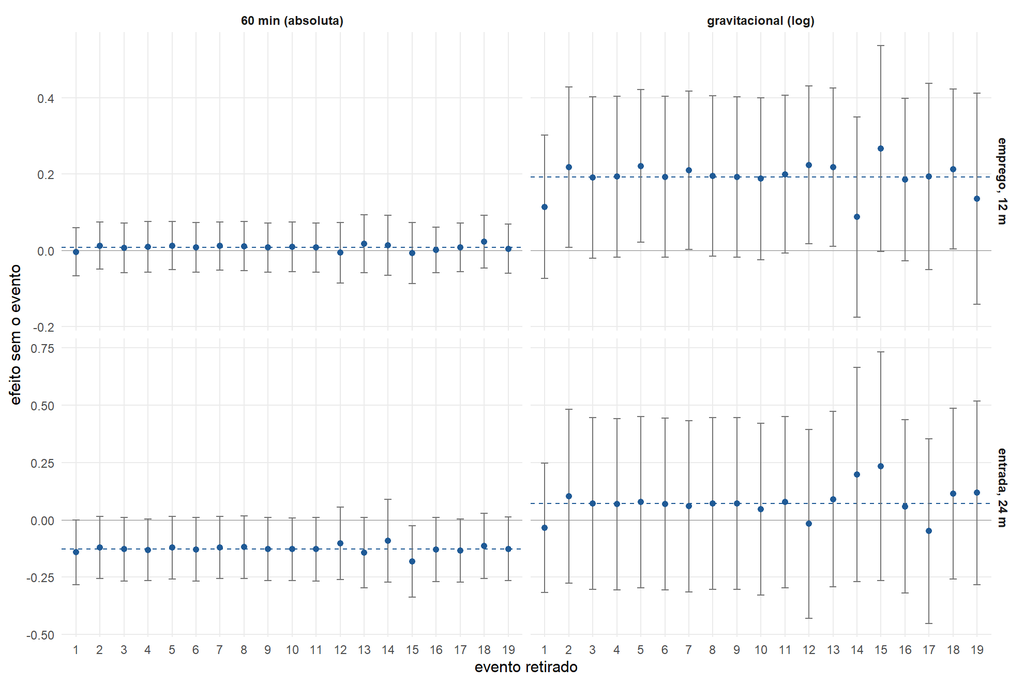

**O que este teste mostra**

**A chance de estar empregado (em relação ao mês de referência) 12 meses depois, cumulativa de 60 min (por +100 mil empregos).** Com todos os eventos, o efeito é +0,007 p.p. (p = 0,759). Retirando um evento de cada vez, ele fica entre −0,007 e +0,022 p.p. e é significativo a 5% em 0 das 19 estimativas. O resultado nulo não depende de nenhum evento.

**A chance de estar empregado (em relação ao mês de referência) 12 meses depois, gravitacional (por +10%).** Com todos os eventos, o efeito é +0,192 p.p. (p = 0,045). Retirando um evento de cada vez, ele fica entre +0,087 e +0,267 p.p. e é significativo a 5% em 7 das 19 estimativas. O sinal nunca muda, mas a significância depende de alguns eventos.

**A chance de entrar no emprego formal em até 24 meses, gravitacional (por +10%).** Com todos os eventos, o efeito é +0,072 p.p. (p = 0,633). Retirando um evento de cada vez, ele fica entre −0,049 e +0,233 p.p. e é significativo a 5% em 0 das 19 estimativas. O resultado nulo não depende de nenhum evento.

## Conclusão do desenho A

**Emprego e entrada no emprego formal.** Testamos 40 combinações: cinco indicadores de acessibilidade (cumulativas de 30, 45, 60 e 90 minutos e gravitacional), duas medidas do ganho (absoluta e percentual), dois desfechos (emprego e entrada no emprego formal) e dois horizontes (12 e 24 meses). 4 delas têm efeito significativo a 5% com placebo nulo (o acaso sozinho produziria cerca de 2), mas todos são negativos e minúsculos, o contrário do que se esperaria de um efeito positivo da acessibilidade: 30 min · ganho absoluto, a chance de estar empregado (em relação ao mês de referência) 24 meses depois (−0,011 p.p.); 45 min · ganho absoluto, a chance de estar empregado (em relação ao mês de referência) 24 meses depois (−0,014 p.p.); 45 min · ganho absoluto, a chance de entrar no emprego formal em até 24 meses (−0,029 p.p.) e 60 min · ganho absoluto, a chance de entrar no emprego formal em até 24 meses (−0,032 p.p.). Os efeitos de um desvio-padrão do ganho vão de −0,032 a +0,036 p.p., e os intervalos de 95% excluem efeitos maiores que 0,08 p.p. em módulo. Para comparação, 15,8% das pessoas sem vínculo formal entram no emprego formal em 12 meses. Outras 3 versões dão significativas, mas o placebo delas também dá (30 min · ganho percentual, a chance de estar empregado (em relação ao mês de referência) 24 meses depois; 45 min · ganho percentual, a chance de estar empregado (em relação ao mês de referência) 24 meses depois e gravitacional · ganho percentual, a chance de estar empregado (em relação ao mês de referência) 12 meses depois): a diferença já existia antes da abertura.

**Salário-hora.** Entre quem estava empregado no mês de referência e no fim do período, 5 das 20 versões (12 e 24 meses) têm efeito significativo com placebo nulo, todas positivas, de no máximo 0,040% por desvio-padrão do ganho: um efeito pequeno demais para ter importância econômica.

**Diferenças entre grupos.** Das 1399 comparações entre grupos (todos os indicadores, desfechos e horizontes), 186 são significativas a 5%, contra cerca de 70 esperadas por acaso. Há mais diferenças do que o acaso explicaria; elas estão nas tabelas de heterogeneidade. O padrão que mais se repete é que o efeito sobre a fração dos meses em que a pessoa esteve empregada é menor para quem tem 45 a 60 anos do que para quem tem 18 a 29 anos, em 18 combinações de indicador e horizonte, sempre com placebo nulo.

**Robustez.** Para o emprego em 12 meses na cumulativa de 60 minutos (por +100 mil empregos), a estimativa principal é +0,007 (p = 0,759); nas outras unidades e definições de vizinhança fica entre −0,001 e +0,009, com 0 de 3 significativas, e retirando um evento por vez fica entre −0,007 e +0,022, com 0 de 19 significativas.

**Conclusão.** A margem de *conseguir* emprego não respondeu às novas estações no horizonte de até dois anos. Para as pessoas de baixa renda do CadÚnico, ter mais empregos ao alcance do transporte público a partir de casa não se traduziu em mais emprego formal nem em mais entradas no emprego formal, em nenhum dos cinco indicadores e nas duas formas de medir o ganho. Os intervalos de confiança são estreitos: descartam efeitos de tamanho relevante, e não apenas deixam de detectá-los. As poucas estimativas significativas são negativas e minúsculas, e não mudam essa leitura. O salário de quem já estava empregado sobe, no máximo, de forma desprezível. Esses resultados não excluem efeitos em prazos mais longos, no trabalho informal (que a RAIS não observa) ou sobre quem se mudou depois da abertura.

# B. Tempo de viagem ao próprio emprego (B&H)

**Em uma frase.** Para quem já tem emprego formal, usamos o mesmo “acaso do calendário” do desenho A para medir se encurtar o trajeto de transporte público entre a casa e o trabalho muda a chance de ser demitido, de pedir demissão ou de continuar empregado.

**Como esta seção está organizada.**

1. **Estratégia:** a pergunta, o problema, a ideia, a conta passo a passo e os dois modelos (B1 e B2).
2. **Descritiva:** quantos trabalhadores tiveram o trajeto encurtado e em quantos minutos.
3. **Resultados do B1** (só o trajeto):
   - três abas: trajetos de até 90 minutos, trajetos de mais de 90 minutos e todos os trajetos juntos;
   - em cada aba, um gráfico, o quadro de leitura e as tabelas por tipo de desfecho.
4. **Diferenças entre grupos:** o efeito é maior para mulheres? Para quem tem criança pequena?
5. **B2:** o efeito do trajeto e o da acessibilidade a outros empregos, estimados juntos.
6. **Robustez.**

## Estratégia de identificação

#### A pergunta

Este desenho olha só para quem **já tem emprego formal**. A pergunta é: quando uma estação nova encurta o trajeto de transporte público entre a casa e o local de trabalho de alguém, isso muda a chance de essa pessoa:

- perder o emprego (ser demitida);
- pedir demissão;
- continuar empregada?

Há boas razões para esperar algum efeito, em direções opostas:

- um trajeto mais curto e mais previsível reduz atrasos, faltas e cansaço, o que pode diminuir as demissões;
- ao mesmo tempo, ele pode facilitar a procura de outro emprego, o que poderia aumentar os pedidos de demissão.

#### O problema: por que não basta comparar quem ganhou com quem não ganhou

O caminho mais simples seria comparar trabalhadores cujo trajeto melhorou com trabalhadores cujo trajeto não melhorou. Isso dá uma resposta errada, por dois motivos.

1. **Quem ganha é diferente de quem não ganha.**
   - As linhas vão para corredores escolhidos pelo planejamento: bairros e centros de emprego com mais demanda.
   - Quem mora e trabalha nesses lugares tende a ter empregos, setores e salários diferentes de quem mora e trabalha longe deles.
   - Se encontrássemos menos demissões entre os que ganharam, não saberíamos se é efeito da estação ou se esses trabalhadores já eram mais estáveis antes.
2. **O momento também importa.**
   - O mercado de trabalho muda muito ao longo do tempo (por exemplo, a recessão de 2015–2016 e a pandemia de 2020).
   - Comparar trabalhadores observados em datas diferentes mistura o efeito da estação com esses ciclos.

Na linguagem de econometria, o ganho de trajeto é **endógeno**: está correlacionado com outras coisas que também afetam o emprego. O desenho abaixo existe para isolar a parte do ganho que não está ligada a essas outras coisas.

#### A ideia: usar a sorte do calendário

- O traçado das linhas e o local das estações são decididos com muitos anos de antecedência.
- Já a **data** em que cada estação entra em serviço pleno depende de atrasos de obra, licitações, testes e contratos.

Suponha que uma estação abriu em 2018, e não em 2016 ou 2020, por razões desse tipo. Então, entre trabalhadores cujo trajeto “estava na fila” para melhorar, quem teve o trajeto encurtado **neste** evento, e não em outro, foi em boa medida uma questão de sorte do calendário.

O método de Borusyak e Hull (2023), que chamamos de **B&H**, transforma essa ideia numa conta.

#### Dois modelos

- **B1 (só o trajeto):** o desfecho depende do ganho de tempo no trajeto até o emprego atual. É o modelo principal.
- **B2 (trajeto e acessibilidade):**
  - acrescenta, na mesma regressão, o ganho de acessibilidade a outros empregos a partir de casa (gravitacional, +0,1 no log ≈ +10%);
  - serve para separar dois canais: “o meu trajeto ficou mais curto” e “ficou mais fácil chegar a outros empregos”.

#### Por que separar trajetos de até 90 e de mais de 90 minutos

- Trajetos de mais de 90 minutos são outro tipo de deslocamento (longas distâncias, muitas baldeações), e os ganhos em minutos neles são muito maiores.
- Num único coeficiente, esses trajetos dominariam a estimativa.
- A versão sem separação aparece nos resultados para comparação.

#### O que precisa ser verdade (hipóteses)

1. **A data é quase aleatória, dado o lugar.** Entre pares com o mesmo ganho esperado, nos mesmos bairros de casa e de trabalho, o fato de a estação ter aberto nesta data e não em outra não está ligado a outros fatores que afetam a chance de desligamento.
2. **Os sorteios representam datas plausíveis.** Só trocamos datas que poderiam ter acontecido.
3. **Sem antecipação.** Empresas e trabalhadores não mudam de comportamento antes da abertura. O placebo testa isso.
4. **O efeito vem do próprio trajeto.** O desligamento de uma pessoa depende do trajeto dela, e não do de colegas.

#### Como ler a incerteza

- **p por permutação:**
  - comparamos o efeito estimado com os 199 efeitos que teríamos obtido se as datas verdadeiras fossem as de um dos sorteios;
  - o p é a fração dos sorteios com efeito tão grande quanto o verdadeiro;
  - se o p é pequeno, o efeito dificilmente é sorte.
- **Erro-padrão:** agrupado por célula de 5 km, porque trabalhadores vizinhos sofrem choques parecidos.
- **Unidade:**
  - na versão principal, pares H3-9 × evento, com peso igual ao número de vínculos, o que dá o mesmo resultado de uma regressão com uma linha por trabalhador;
  - na versão agregada, o par de hexágonos H3-8 (cerca de 0,7 km²).

## Estatística descritiva

**Por que a média do ganho por vínculo é tão pequena.** Em cada evento, a grande maioria dos trabalhadores não tem o trajeto alterado: as estações de um evento só mudam os trajetos que passam por elas. A média de todos os vínculos fica, por isso, abaixo de 1 minuto, mesmo quando quem ganhou ganhou bastante.

A tabela separa as duas coisas:

- quantos vínculos ganharam pelo menos 1 minuto;
- quanto ganharam esses vínculos (média, mediana e percentil 90).

| Trajeto antes do evento | Vínculos × evento | Com ganho de 1 min ou mais | Ganho médio, todos (min) | Ganho médio de quem ganhou (min) | Mediana de quem ganhou (min) | Percentil 90 de quem ganhou (min) |
| --- | --- | --- | --- | --- | --- | --- |
| todos | 6.116.667 | 2,0% | 0,17 | 8,4 | 6,0 | 19,0 |
| até 90 min | 4.199.884 | 1,1% | 0,07 | 6,1 | 5,0 | 13,0 |
| mais de 90 min | 1.916.783 | 4,2% | 0,41 | 9,7 | 7,0 | 22,0 |

Janela depois da abertura. Ganho de tempo do evento no trajeto de transporte público casa → trabalho, ponderado por vínculos. Média, mediana e percentil 90 calculados entre os vínculos com ganho de pelo menos 1 minuto.

## Resultados (B1)

**Como estes resultados estão organizados.**

- **O gráfico** mostra o efeito de **10 minutos a menos** no trajeto (trajetos de até 90 min):
  - uma linha por tipo de desfecho e uma coluna por grupo;
  - em azul, depois da abertura; em laranja, o placebo; barras de 95%.
  - Um valor **negativo** em demissão quer dizer **menos** demissões quando o trajeto encurta.
- **Três abas de trajeto,** no topo:
  - **trajetos de até 90 minutos** antes do evento (o recorte principal);
  - **trajetos de mais de 90 minutos**;
  - **todos os trajetos juntos**, num único coeficiente, sem a separação em 90 minutos.
- **Dentro de cada aba:** o gráfico, o quadro verde e as tabelas.
- **As tabelas** têm uma aba por tipo de desfecho, na ordem: demissão (total), demissão sem justa causa, demissão com justa causa, pedido de demissão, qualquer desligamento, permanência no emprego e fração dos meses empregado.
  - Em cada aba, as linhas são os grupos.
  - As colunas seguem o tempo (6, 12, 18 e 24 meses), com depois e placebo lado a lado.
- **Na aba “todos os trajetos”,** há também a versão com o ganho medido em % do tempo de antes. Nessa medida, 10 minutos a menos num trajeto de 30 minutos (33%) pesam mais que 10 minutos a menos num trajeto de 120 (8%).

**Trajetos de até 90 minutos**

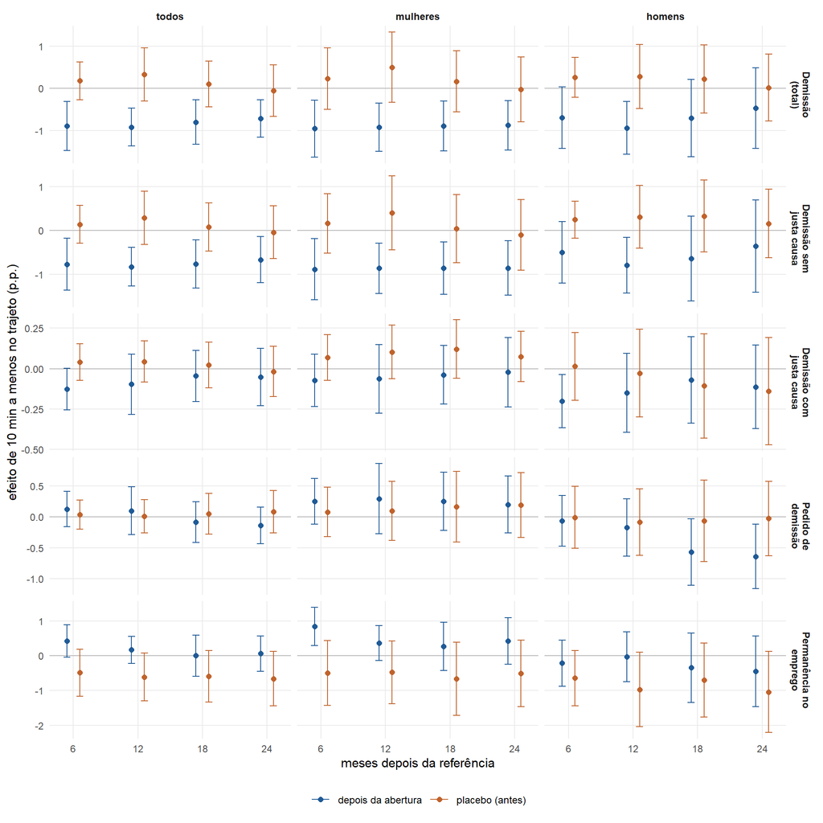

**O que estes resultados mostram**

Recorte: trajetos de até 90 minutos antes do evento. Para dar a escala, cada efeito é comparado com a média do desfecho no grupo.

**Todas as pessoas.** Cada 10 minutos a menos no trajeto reduz a chance de ser demitido em até 6 meses em 0,89 ponto percentual, o que equivale a cerca de 7% da taxa média, que é de 12,2%; o efeito é estatisticamente muito significativo (p < 0,001). Também reduz a chance de ser demitido em até 12 meses em 0,92 ponto percentual, o que equivale a cerca de 4% da taxa média, que é de 21,8%; o efeito é estatisticamente muito significativo (p = 0,005). Além disso, reduz a chance de ser demitido sem justa causa em até 6 meses em 0,77 ponto percentual, o que equivale a cerca de 7% da taxa média, que é de 11,5%; o efeito é estatisticamente muito significativo (p < 0,001). Da mesma forma, reduz a chance de ser demitido por justa causa em até 6 meses em 0,13 ponto percentual; o efeito é estatisticamente muito significativo (p = 0,005). Já a chance de pedir demissão em até 6 meses (estimativa de +0,12 ponto percentual) e a chance de continuar empregado 12 meses depois (estimativa de +0,17 ponto percentual) não mudam de forma estatisticamente distinguível de zero. No placebo, porém, também aparece diferença na chance de continuar empregado 12 meses depois (−0,61 ponto percentual, p = 0,070): nesses casos, a diferença entre os grupos já existia antes da abertura, e o resultado pede cautela.

**Mulheres.** Cada 10 minutos a menos no trajeto reduz a chance de ser demitido em até 6 meses em 0,95 ponto percentual, o que equivale a cerca de 8% da taxa média, que é de 12,3%; o efeito é estatisticamente muito significativo (p < 0,001). Também reduz a chance de ser demitido em até 12 meses em 0,92 ponto percentual, o que equivale a cerca de 4% da taxa média, que é de 21,8%; o efeito é estatisticamente significativo (p = 0,010). Além disso, reduz a chance de ser demitido sem justa causa em até 6 meses em 0,88 ponto percentual, o que equivale a cerca de 8% da taxa média, que é de 11,6%; o efeito é estatisticamente muito significativo (p < 0,001). Já a chance de ser demitido por justa causa em até 6 meses (estimativa de −0,07 ponto percentual), a chance de pedir demissão em até 6 meses (estimativa de +0,25 ponto percentual) e a chance de continuar empregado 12 meses depois (estimativa de +0,37 ponto percentual) não mudam de forma estatisticamente distinguível de zero. No placebo — a mesma comparação feita antes de a estação existir —, nenhum desses desfechos mostra diferença significativa, o que reforça que os efeitos acima vêm da abertura.

**Homens.** Cada 10 minutos a menos no trajeto reduz a chance de ser demitido em até 6 meses em 0,70 ponto percentual, o que equivale a cerca de 6% da taxa média, que é de 12,2%; o efeito é estatisticamente significativo (p = 0,020). Também reduz a chance de ser demitido em até 12 meses em 0,94 ponto percentual, o que equivale a cerca de 4% da taxa média, que é de 21,7%; o efeito é estatisticamente muito significativo (p = 0,005). Além disso, reduz a chance de ser demitido sem justa causa em até 6 meses em 0,50 ponto percentual, o que equivale a cerca de 4% da taxa média, que é de 11,4%; o efeito é significativo só ao nível de 10%, uma evidência fraca (p = 0,090). Da mesma forma, reduz a chance de ser demitido por justa causa em até 6 meses em 0,20 ponto percentual; o efeito é estatisticamente significativo (p = 0,015). Já a chance de pedir demissão em até 6 meses (estimativa de −0,07 ponto percentual) e a chance de continuar empregado 12 meses depois (estimativa de −0,03 ponto percentual) não mudam de forma estatisticamente distinguível de zero. No placebo, porém, também aparece diferença na chance de continuar empregado 12 meses depois (−0,97 ponto percentual, p = 0,055): nesses casos, a diferença entre os grupos já existia antes da abertura, e o resultado pede cautela.

**Demissão (total)**

| Grupo | 6 meses · depois | 6 meses · placebo | 12 meses · depois | 12 meses · placebo | 18 meses · depois | 18 meses · placebo | 24 meses · depois | 24 meses · placebo |
| --- | --- | --- | --- | --- | --- | --- | --- | --- |
| todos | −0,89*** (0,30) | +0,18 (0,23) | −0,92*** (0,23) | +0,33 (0,32) | −0,80** (0,27) | +0,11 (0,28) | −0,71* (0,23) | −0,06 (0,31) |
| mulheres | −0,95*** (0,35) | +0,23 (0,37) | −0,92** (0,29) | +0,50 (0,43) | −0,89** (0,30) | +0,16 (0,37) | −0,88* (0,30) | −0,03 (0,39) |
| homens | −0,70** (0,37) | +0,26 (0,24) | −0,94*** (0,32) | +0,28 (0,39) | −0,71** (0,47) | +0,22 (0,41) | −0,47 (0,49) | +0,02 (0,40) |
| 18 a 29 | −1,09*** (0,29) | −0,20 (0,47) | −1,11** (0,37) | +0,19 (0,49) | −0,96* (0,39) | +0,18 (0,48) | −0,57 (0,39) | +0,09 (0,49) |
| 30 a 44 | −0,42 (0,35) | +0,46 (0,31) | −0,48 (0,32) | +0,42 (0,42) | −0,72 (0,42) | +0,04 (0,47) | −0,87** (0,37) | −0,45 (0,47) |
| 45 a 60 | −0,90** (0,55) | +0,36 (0,41) | −1,28** (0,67) | +0,49 (0,61) | −0,58 (0,83) | +0,34 (0,64) | −0,67 (0,86) | +0,47 (0,72) |
| com criança | −0,86** (0,39) | +0,68* (0,58) | −0,73 (0,46) | +0,95* (0,59) | −0,56 (0,43) | +0,07 (0,60) | −0,42 (0,42) | −0,52 (0,63) |
| sem criança | −0,94*** (0,35) | — | −1,01*** (0,23) | — | −0,96** (0,30) | — | −0,89** (0,35) | — |
| mulheres com criança | −0,79* (0,51) | +0,80 (0,64) | −0,56 (0,60) | +1,58** (0,64) | −0,47 (0,49) | +0,49 (0,63) | −0,31 (0,56) | −0,02 (0,68) |
| mulheres sem criança | −1,02*** (0,42) | −0,11 (0,36) | −1,04*** (0,30) | −0,13 (0,50) | −1,10*** (0,36) | −0,04 (0,47) | −1,19** (0,44) | −0,08 (0,57) |
| homens com criança | −0,90* (0,63) | +0,71 (0,95) | −0,99 (0,72) | +0,14 (0,92) | −0,64 (0,84) | −0,34 (1,19) | −0,28 (0,70) | −1,15 (1,23) |
| homens sem criança | −0,67* (0,40) | +0,12 (0,41) | −0,96** (0,36) | +0,40 (0,53) | −0,79* (0,53) | +0,55 (0,60) | −0,54 (0,64) | +0,59 (0,70) |
| vínculo até 12 meses | −0,82** (0,38) | — | −0,89*** (0,38) | — | −0,73* (0,55) | — | −0,49 (0,50) | — |

Efeito de 10 minutos a menos no trajeto (trajetos de até 90 minutos), em pontos percentuais.

**Demissão sem justa causa**

| Grupo | 6 meses · depois | 6 meses · placebo | 12 meses · depois | 12 meses · placebo | 18 meses · depois | 18 meses · placebo | 24 meses · depois | 24 meses · placebo |
| --- | --- | --- | --- | --- | --- | --- | --- | --- |
| todos | −0,77*** (0,30) | +0,14 (0,22) | −0,82** (0,22) | +0,29 (0,31) | −0,76** (0,28) | +0,08 (0,28) | −0,66* (0,27) | −0,04 (0,30) |
| mulheres | −0,88*** (0,35) | +0,16 (0,35) | −0,86** (0,29) | +0,40 (0,43) | −0,86* (0,30) | +0,04 (0,40) | −0,85* (0,32) | −0,10 (0,41) |
| homens | −0,50* (0,36) | +0,25 (0,21) | −0,79** (0,32) | +0,31 (0,36) | −0,64* (0,49) | +0,33 (0,42) | −0,35 (0,54) | +0,16 (0,40) |
| 18 a 29 | −0,92*** (0,30) | −0,20 (0,49) | −0,94** (0,34) | +0,20 (0,51) | −0,91* (0,37) | +0,14 (0,51) | −0,54 (0,38) | +0,13 (0,51) |
| 30 a 44 | −0,39 (0,35) | +0,44 (0,28) | −0,55 (0,30) | +0,39 (0,40) | −0,76* (0,40) | +0,03 (0,47) | −0,88** (0,36) | −0,44 (0,47) |
| 45 a 60 | −0,65 (0,56) | +0,20 (0,41) | −0,97* (0,70) | +0,36 (0,61) | −0,35 (0,92) | +0,30 (0,61) | −0,41 (0,95) | +0,50 (0,68) |
| com criança | −0,66* (0,36) | +0,69** (0,54) | −0,60 (0,39) | +0,94** (0,57) | −0,41 (0,36) | +0,03 (0,64) | −0,20 (0,37) | −0,42 (0,68) |
| sem criança | −0,84*** (0,35) | — | −0,92*** (0,25) | — | −0,94** (0,32) | — | −0,90** (0,38) | — |
| mulheres com criança | −0,73 (0,44) | +0,84* (0,62) | −0,56 (0,53) | +1,61*** (0,64) | −0,38 (0,44) | +0,55 (0,64) | −0,15 (0,53) | +0,17 (0,70) |
| mulheres sem criança | −0,94*** (0,44) | −0,23 (0,31) | −0,94*** (0,30) | −0,30 (0,46) | −1,07*** (0,38) | −0,25 (0,45) | −1,23*** (0,45) | −0,30 (0,55) |
| homens com criança | −0,47 (0,63) | +0,62 (0,82) | −0,63 (0,67) | +0,02 (0,86) | −0,42 (0,78) | −0,58 (1,16) | +0,05 (0,65) | −1,26 (1,21) |
| homens sem criança | −0,56 (0,40) | +0,13 (0,41) | −0,89** (0,41) | +0,48 (0,48) | −0,78* (0,60) | +0,78 (0,58) | −0,52 (0,72) | +0,82* (0,62) |
| vínculo até 12 meses | −0,70** (0,40) | — | −0,71** (0,38) | — | −0,66 (0,55) | — | −0,37 (0,52) | — |

Efeito de 10 minutos a menos no trajeto (trajetos de até 90 minutos), em pontos percentuais.

**Demissão com justa causa**

| Grupo | 6 meses · depois | 6 meses · placebo | 12 meses · depois | 12 meses · placebo | 18 meses · depois | 18 meses · placebo | 24 meses · depois | 24 meses · placebo |
| --- | --- | --- | --- | --- | --- | --- | --- | --- |
| todos | −0,13*** (0,07) | +0,04 (0,06) | −0,10* (0,09) | +0,04 (0,06) | −0,05 (0,08) | +0,02 (0,07) | −0,05 (0,09) | −0,02 (0,08) |
| mulheres | −0,07 (0,08) | +0,07 (0,07) | −0,06 (0,11) | +0,10 (0,08) | −0,04 (0,09) | +0,12 (0,09) | −0,02 (0,11) | +0,07 (0,08) |
| homens | −0,20** (0,08) | +0,01 (0,11) | −0,15 (0,12) | −0,03 (0,14) | −0,07 (0,14) | −0,11 (0,16) | −0,11 (0,13) | −0,14 (0,17) |
| 18 a 29 | −0,16** (0,09) | −0,01 (0,15) | −0,17* (0,15) | −0,01 (0,17) | −0,05 (0,13) | +0,03 (0,20) | −0,03 (0,14) | −0,04 (0,22) |
| 30 a 44 | −0,03 (0,10) | +0,02 (0,09) | +0,07 (0,12) | +0,03 (0,11) | +0,03 (0,12) | +0,01 (0,11) | +0,01 (0,12) | −0,01 (0,09) |
| 45 a 60 | −0,24*** (0,07) | +0,16 (0,09) | −0,31** (0,17) | +0,14 (0,10) | −0,23 (0,26) | +0,04 (0,13) | −0,26* (0,23) | −0,03 (0,14) |
| com criança | −0,20** (0,09) | −0,00 (0,13) | −0,14 (0,16) | +0,01 (0,13) | −0,14 (0,18) | +0,04 (0,14) | −0,22 (0,19) | −0,10 (0,15) |
| sem criança | −0,10* (0,08) | — | −0,09 (0,09) | — | −0,02 (0,08) | — | +0,02 (0,09) | — |
| mulheres com criança | −0,07 (0,15) | −0,04 (0,14) | +0,00 (0,21) | −0,03 (0,16) | −0,09 (0,24) | −0,06 (0,19) | −0,16 (0,27) | −0,20 (0,19) |
| mulheres sem criança | −0,07 (0,11) | +0,12* (0,08) | −0,10 (0,10) | +0,17 (0,11) | −0,03 (0,10) | +0,21* (0,13) | +0,04 (0,10) | +0,22* (0,12) |
| homens com criança | −0,42*** (0,18) | +0,09 (0,21) | −0,36** (0,18) | +0,12 (0,23) | −0,22 (0,23) | +0,23 (0,26) | −0,33 (0,22) | +0,11 (0,29) |
| homens sem criança | −0,11 (0,12) | −0,01 (0,11) | −0,07 (0,17) | −0,08 (0,16) | −0,01 (0,20) | −0,23* (0,19) | −0,03 (0,20) | −0,23 (0,21) |
| vínculo até 12 meses | −0,12 (0,10) | — | −0,18 (0,15) | — | −0,08 (0,13) | — | −0,12 (0,13) | — |

Efeito de 10 minutos a menos no trajeto (trajetos de até 90 minutos), em pontos percentuais.

**Pedido de demissão**

| Grupo | 6 meses · depois | 6 meses · placebo | 12 meses · depois | 12 meses · placebo | 18 meses · depois | 18 meses · placebo | 24 meses · depois | 24 meses · placebo |
| --- | --- | --- | --- | --- | --- | --- | --- | --- |
| todos | +0,12 (0,15) | +0,04 (0,12) | +0,10 (0,20) | +0,01 (0,14) | −0,09 (0,17) | +0,05 (0,17) | −0,14 (0,15) | +0,08 (0,17) |
| mulheres | +0,25 (0,19) | +0,08 (0,20) | +0,29 (0,29) | +0,09 (0,24) | +0,25 (0,24) | +0,16 (0,29) | +0,20 (0,23) | +0,19 (0,27) |
| homens | −0,07 (0,21) | −0,01 (0,26) | −0,17 (0,24) | −0,09 (0,27) | −0,57** (0,27) | −0,07 (0,33) | −0,64** (0,26) | −0,03 (0,31) |
| 18 a 29 | +0,13 (0,22) | +0,33 (0,25) | +0,02 (0,34) | +0,24 (0,27) | −0,00 (0,31) | +0,26 (0,36) | −0,09 (0,28) | +0,29 (0,40) |
| 30 a 44 | +0,16 (0,24) | −0,02 (0,17) | +0,21 (0,29) | +0,10 (0,19) | −0,12 (0,33) | +0,11 (0,25) | −0,15 (0,35) | +0,16 (0,24) |
| 45 a 60 | +0,03 (0,29) | −0,44** (0,24) | +0,10 (0,37) | −0,63*** (0,29) | −0,02 (0,31) | −0,48** (0,25) | −0,01 (0,33) | −0,44 (0,28) |
| com criança | +0,12 (0,22) | +0,00 (0,24) | +0,07 (0,27) | −0,13 (0,35) | −0,31 (0,29) | −0,15 (0,35) | −0,39 (0,30) | −0,08 (0,31) |
| sem criança | +0,12 (0,18) | — | +0,12 (0,25) | — | +0,02 (0,25) | — | −0,02 (0,21) | — |
| mulheres com criança | +0,10 (0,28) | +0,12 (0,33) | +0,10 (0,34) | +0,19 (0,50) | −0,10 (0,37) | +0,12 (0,46) | −0,18 (0,41) | +0,12 (0,39) |
| mulheres sem criança | +0,32 (0,21) | +0,06 (0,26) | +0,38 (0,34) | +0,06 (0,25) | +0,41 (0,32) | +0,19 (0,30) | +0,38 (0,29) | +0,23 (0,34) |
| homens com criança | +0,14 (0,32) | −0,22 (0,29) | +0,01 (0,31) | −0,69* (0,44) | −0,74* (0,33) | −0,63 (0,55) | −0,82* (0,39) | −0,44 (0,47) |
| homens sem criança | −0,15 (0,28) | +0,07 (0,33) | −0,24 (0,32) | +0,14 (0,32) | −0,51 (0,35) | +0,15 (0,37) | −0,58 (0,31) | +0,13 (0,37) |
| vínculo até 12 meses | +0,13 (0,30) | — | +0,09 (0,37) | — | −0,39 (0,31) | — | −0,48 (0,34) | — |

Efeito de 10 minutos a menos no trajeto (trajetos de até 90 minutos), em pontos percentuais.

**Qualquer desligamento**

| Grupo | 6 meses · depois | 6 meses · placebo | 12 meses · depois | 12 meses · placebo | 18 meses · depois | 18 meses · placebo | 24 meses · depois | 24 meses · placebo |
| --- | --- | --- | --- | --- | --- | --- | --- | --- |
| todos | −0,57* (0,37) | +0,48 (0,39) | −0,70** (0,39) | +0,74* (0,46) | −0,80** (0,43) | +0,58 (0,45) | −0,79** (0,35) | +0,51 (0,43) |
| mulheres | −0,45 (0,40) | +0,57 (0,52) | −0,44 (0,43) | +0,86* (0,49) | −0,46 (0,40) | +0,66 (0,50) | −0,58 (0,33) | +0,56 (0,43) |
| homens | −0,66 (0,48) | +0,53 (0,40) | −1,08** (0,52) | +0,79 (0,61) | −1,32*** (0,59) | +0,71 (0,67) | −1,08** (0,56) | +0,57 (0,66) |
| 18 a 29 | −0,60 (0,33) | +0,46 (0,73) | −0,87* (0,47) | +1,13** (0,73) | −0,68 (0,47) | +0,97** (0,81) | −0,43 (0,46) | +0,84** (0,75) |
| 30 a 44 | −0,09 (0,47) | +0,67* (0,38) | −0,15 (0,40) | +0,73* (0,41) | −0,78* (0,48) | +0,42 (0,44) | −0,94** (0,31) | +0,09 (0,45) |
| 45 a 60 | −0,93* (0,69) | +0,05 (0,49) | −1,17* (0,81) | +0,05 (0,70) | −0,65 (0,93) | +0,24 (0,74) | −0,81 (0,89) | +0,50 (0,81) |
| com criança | −0,44 (0,52) | +1,09** (0,57) | −0,40 (0,58) | +1,22** (0,56) | −0,67 (0,47) | +0,44 (0,63) | −0,76 (0,43) | +0,04 (0,63) |
| sem criança | −0,67* (0,44) | — | −0,83** (0,49) | — | −0,90** (0,56) | — | −0,83* (0,55) | — |
| mulheres com criança | −0,26 (0,72) | +1,16** (0,71) | +0,05 (0,79) | +1,87*** (0,62) | −0,18 (0,60) | +0,85 (0,70) | −0,34 (0,69) | +0,42 (0,64) |
| mulheres sem criança | −0,55 (0,51) | +0,22 (0,50) | −0,65 (0,53) | +0,29 (0,49) | −0,62 (0,64) | +0,55 (0,52) | −0,75 (0,62) | +0,55 (0,53) |
| homens com criança | −0,77 (0,81) | +1,23 (0,71) | −1,27* (0,79) | +0,39 (0,79) | −1,63** (0,88) | +0,08 (1,16) | −1,31* (0,71) | −0,39 (1,15) |
| homens sem criança | −0,70 (0,50) | +0,26 (0,44) | −1,08* (0,59) | +0,98 (0,67) | −1,29** (0,65) | +1,04 (0,77) | −1,03 (0,67) | +1,02* (0,82) |
| vínculo até 12 meses | −0,41 (0,59) | — | −0,54 (0,65) | — | −0,84** (0,61) | — | −0,72* (0,51) | — |

Efeito de 10 minutos a menos no trajeto (trajetos de até 90 minutos), em pontos percentuais.

**Permanência no emprego**

| Grupo | 6 meses · depois | 6 meses · placebo | 12 meses · depois | 12 meses · placebo | 18 meses · depois | 18 meses · placebo | 24 meses · depois | 24 meses · placebo |
| --- | --- | --- | --- | --- | --- | --- | --- | --- |
| todos | +0,42** (0,24) | −0,49* (0,35) | +0,17 (0,20) | −0,61* (0,35) | +0,00 (0,30) | −0,60 (0,38) | +0,06 (0,26) | −0,66 (0,40) |
| mulheres | +0,84*** (0,28) | −0,50 (0,47) | +0,37 (0,26) | −0,48 (0,46) | +0,27 (0,35) | −0,66 (0,54) | +0,42 (0,34) | −0,51 (0,49) |
| homens | −0,21 (0,34) | −0,64 (0,41) | −0,03 (0,37) | −0,97* (0,54) | −0,34 (0,51) | −0,70 (0,54) | −0,45 (0,52) | −1,04* (0,60) |
| 18 a 29 | +0,55** (0,32) | −0,40 (0,66) | −0,36 (0,31) | −1,25** (0,58) | −0,32 (0,49) | −1,38*** (0,81) | −0,31 (0,62) | −1,36** (0,67) |
| 30 a 44 | +0,28 (0,39) | −0,68** (0,33) | +0,46 (0,44) | −0,36 (0,30) | +0,35 (0,46) | −0,22 (0,34) | +0,68* (0,39) | −0,07 (0,36) |
| 45 a 60 | +0,20 (0,43) | −0,13 (0,50) | +0,68 (0,58) | −0,01 (0,68) | +0,04 (0,64) | −0,15 (0,71) | −0,30 (0,47) | −0,54 (0,75) |
| com criança | +0,78** (0,47) | −1,02** (0,51) | +0,04 (0,41) | −1,22** (0,50) | −0,23 (0,43) | −0,80 (0,59) | +0,71 (0,47) | −1,00* (0,52) |
| sem criança | +0,22 (0,30) | — | +0,19 (0,31) | — | +0,07 (0,37) | — | −0,25 (0,38) | — |
| mulheres com criança | +1,11** (0,61) | −1,09** (0,64) | −0,04 (0,67) | −1,45** (0,60) | −0,23 (0,56) | −0,81 (0,70) | +0,89* (0,66) | −1,31** (0,68) |
| mulheres sem criança | +0,67** (0,35) | −0,22 (0,47) | +0,57* (0,33) | +0,05 (0,49) | +0,52 (0,44) | −0,64 (0,53) | +0,19 (0,38) | −0,06 (0,61) |
| homens com criança | +0,11 (0,54) | −1,09 (0,74) | +0,27 (0,67) | −0,97 (0,84) | −0,27 (0,76) | −1,06 (1,04) | +0,25 (0,60) | −0,47 (0,89) |
| homens sem criança | −0,31 (0,42) | −0,46 (0,44) | −0,16 (0,46) | −0,94* (0,64) | −0,37 (0,57) | −0,61 (0,65) | −0,74* (0,66) | −1,30** (0,73) |
| vínculo até 12 meses | +0,45 (0,49) | — | −0,06 (0,40) | — | +0,12 (0,49) | — | +0,02 (0,47) | — |

Efeito de 10 minutos a menos no trajeto (trajetos de até 90 minutos), em pontos percentuais.

**Fração dos meses empregado**

| Grupo | 6 meses · depois | 6 meses · placebo | 12 meses · depois | 12 meses · placebo | 18 meses · depois | 18 meses · placebo | 24 meses · depois | 24 meses · placebo |
| --- | --- | --- | --- | --- | --- | --- | --- | --- |
| todos | +0,16 (0,19) | −0,22 (0,22) | +0,20 (0,19) | −0,45* (0,28) | +0,13 (0,19) | −0,43* (0,28) | +0,10 (0,18) | −0,48* (0,29) |
| mulheres | +0,34* (0,24) | −0,34 (0,33) | +0,49*** (0,23) | −0,48* (0,37) | +0,37* (0,21) | −0,42 (0,35) | +0,39* (0,21) | −0,45 (0,36) |
| homens | −0,07 (0,24) | −0,13 (0,24) | −0,16 (0,29) | −0,53 (0,33) | −0,16 (0,30) | −0,60* (0,38) | −0,27 (0,29) | −0,67* (0,40) |
| 18 a 29 | +0,31 (0,23) | −0,14 (0,44) | +0,15 (0,25) | −0,49 (0,48) | −0,06 (0,28) | −0,69* (0,46) | −0,13 (0,30) | −0,93** (0,48) |
| 30 a 44 | −0,09 (0,27) | −0,38* (0,18) | +0,22 (0,27) | −0,55** (0,23) | +0,27 (0,30) | −0,41* (0,25) | +0,34 (0,27) | −0,31 (0,25) |
| 45 a 60 | +0,19 (0,32) | +0,10 (0,35) | +0,11 (0,36) | −0,05 (0,41) | +0,18 (0,36) | +0,04 (0,45) | +0,04 (0,37) | −0,01 (0,49) |
| com criança | +0,15 (0,34) | −0,81*** (0,30) | +0,35 (0,37) | −1,02*** (0,33) | +0,25 (0,35) | −0,85** (0,34) | +0,30 (0,33) | −0,86** (0,33) |
| sem criança | +0,15 (0,22) | — | +0,11 (0,23) | — | +0,05 (0,24) | — | −0,02 (0,23) | — |
| mulheres com criança | +0,39 (0,46) | −0,91** (0,44) | +0,61* (0,52) | −1,12*** (0,44) | +0,39 (0,50) | −0,97** (0,45) | +0,49 (0,48) | −1,02** (0,45) |
| mulheres sem criança | +0,30 (0,27) | −0,06 (0,33) | +0,40* (0,27) | −0,17 (0,38) | +0,35 (0,26) | −0,15 (0,35) | +0,34 (0,24) | −0,17 (0,36) |
| homens com criança | −0,34 (0,40) | −0,73 (0,52) | −0,09 (0,52) | −0,99* (0,50) | +0,09 (0,54) | −0,81 (0,56) | +0,02 (0,50) | −0,74 (0,56) |
| homens sem criança | +0,03 (0,27) | +0,12 (0,29) | −0,18 (0,32) | −0,33 (0,39) | −0,25 (0,34) | −0,51 (0,43) | −0,38 (0,34) | −0,66* (0,47) |
| vínculo até 12 meses | +0,11 (0,34) | — | +0,18 (0,37) | — | +0,02 (0,37) | — | +0,02 (0,34) | — |

Efeito de 10 minutos a menos no trajeto (trajetos de até 90 minutos), em pontos percentuais.

**Trajetos de mais de 90 minutos**

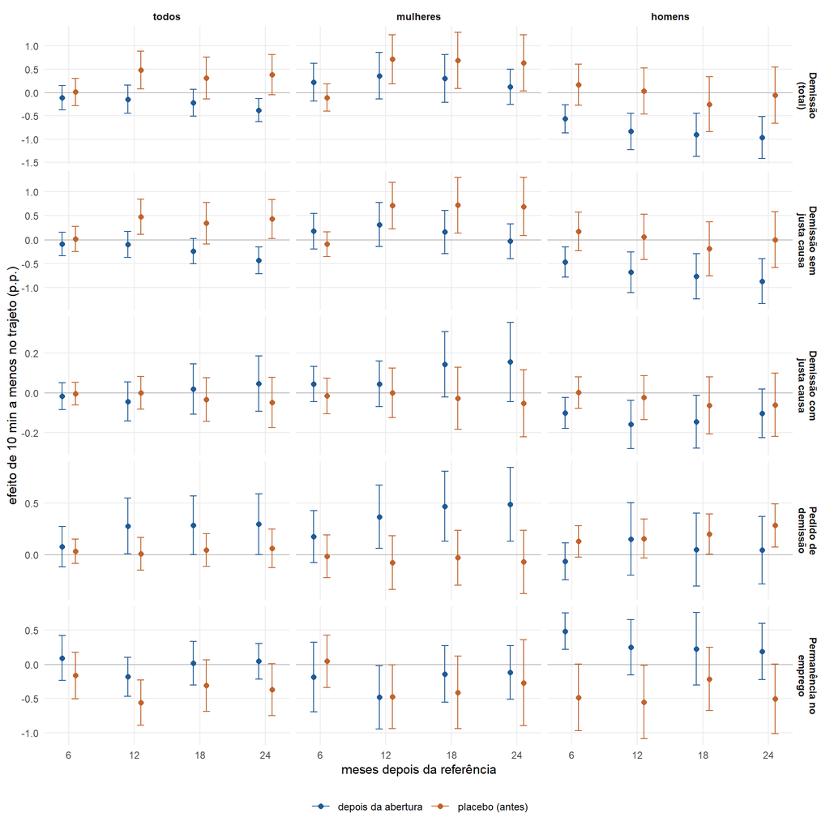

**O que estes resultados mostram**

Recorte: trajetos de mais de 90 minutos antes do evento. Para dar a escala, cada efeito é comparado com a média do desfecho no grupo.

**Todas as pessoas.** Cada 10 minutos a menos no trajeto não altera de forma estatisticamente distinguível de zero a chance de ser demitido em até 6 meses (estimativa de −0,11 ponto percentual), a chance de ser demitido em até 12 meses (estimativa de −0,14 ponto percentual), a chance de ser demitido sem justa causa em até 6 meses (estimativa de −0,09 ponto percentual), a chance de ser demitido por justa causa em até 6 meses (estimativa de −0,02 ponto percentual), a chance de pedir demissão em até 6 meses (estimativa de +0,08 ponto percentual) e a chance de continuar empregado 12 meses depois (estimativa de −0,18 ponto percentual). No placebo, porém, também aparece diferença na chance de ser demitido em até 12 meses (+0,48 ponto percentual, p = 0,080) e na chance de continuar empregado 12 meses depois (−0,56 ponto percentual, p = 0,010): nesses casos, a diferença entre os grupos já existia antes da abertura, e o resultado pede cautela.

**Mulheres.** Cada 10 minutos a menos no trajeto reduz a chance de continuar empregado 12 meses depois em 0,48 ponto percentual, o que equivale a cerca de 1% da taxa média, que é de 77,2%; o efeito é significativo só ao nível de 10%, uma evidência fraca (p = 0,055). Já a chance de ser demitido em até 6 meses (estimativa de +0,22 ponto percentual), a chance de ser demitido em até 12 meses (estimativa de +0,36 ponto percentual), a chance de ser demitido sem justa causa em até 6 meses (estimativa de +0,18 ponto percentual), a chance de ser demitido por justa causa em até 6 meses (estimativa de +0,04 ponto percentual) e a chance de pedir demissão em até 6 meses (estimativa de +0,18 ponto percentual) não mudam de forma estatisticamente distinguível de zero. No placebo, porém, também aparece diferença na chance de ser demitido em até 12 meses (+0,71 ponto percentual, p = 0,025): nesses casos, a diferença entre os grupos já existia antes da abertura, e o resultado pede cautela.

**Homens.** Cada 10 minutos a menos no trajeto reduz a chance de ser demitido em até 6 meses em 0,56 ponto percentual, o que equivale a cerca de 4% da taxa média, que é de 12,6%; o efeito é significativo só ao nível de 10%, uma evidência fraca (p = 0,065). Também reduz a chance de ser demitido em até 12 meses em 0,83 ponto percentual, o que equivale a cerca de 4% da taxa média, que é de 22,4%; o efeito é estatisticamente significativo (p = 0,015). Além disso, reduz a chance de ser demitido por justa causa em até 6 meses em 0,10 ponto percentual, o que equivale a cerca de 10% da taxa média, que é de 1,0%; o efeito é estatisticamente significativo (p = 0,020). Já a chance de ser demitido sem justa causa em até 6 meses (estimativa de −0,46 ponto percentual), a chance de pedir demissão em até 6 meses (estimativa de −0,06 ponto percentual) e a chance de continuar empregado 12 meses depois (estimativa de +0,25 ponto percentual) não mudam de forma estatisticamente distinguível de zero. No placebo, porém, também aparece diferença na chance de continuar empregado 12 meses depois (−0,55 ponto percentual, p = 0,055): nesses casos, a diferença entre os grupos já existia antes da abertura, e o resultado pede cautela.

**Demissão (total)**

| Grupo | 6 meses · depois | 6 meses · placebo | 12 meses · depois | 12 meses · placebo | 18 meses · depois | 18 meses · placebo | 24 meses · depois | 24 meses · placebo |
| --- | --- | --- | --- | --- | --- | --- | --- | --- |
| todos | −0,11 (0,13) | +0,01 (0,15) | −0,14 (0,15) | +0,48* (0,21) | −0,22 (0,15) | +0,31 (0,23) | −0,38 (0,13) | +0,38 (0,22) |
| mulheres | +0,22 (0,21) | −0,11 (0,15) | +0,36 (0,26) | +0,71** (0,27) | +0,30 (0,26) | +0,69** (0,31) | +0,12 (0,19) | +0,63* (0,31) |
| homens | −0,56* (0,15) | +0,17 (0,22) | −0,83** (0,20) | +0,03 (0,25) | −0,91** (0,23) | −0,25 (0,30) | −0,97** (0,23) | −0,06 (0,31) |
| 18 a 29 | −0,19 (0,25) | −0,12 (0,18) | −0,42 (0,28) | +0,56 (0,29) | −0,51** (0,22) | +0,33 (0,29) | −0,58** (0,20) | +0,31 (0,36) |
| 30 a 44 | −0,05 (0,16) | +0,16 (0,23) | +0,03 (0,17) | +0,41 (0,32) | +0,02 (0,20) | +0,43 (0,30) | −0,22 (0,21) | +0,46 (0,28) |
| 45 a 60 | −0,10 (0,22) | −0,12 (0,22) | −0,13 (0,27) | +0,50 (0,28) | −0,41 (0,25) | +0,11 (0,42) | −0,47 (0,30) | +0,29 (0,35) |
| com criança | +0,20 (0,21) | +0,24 (0,32) | +0,00 (0,26) | +0,88** (0,37) | −0,15 (0,30) | +0,88** (0,40) | −0,23 (0,33) | +0,81** (0,40) |
| sem criança | −0,26 (0,16) | — | −0,20 (0,17) | — | −0,25 (0,15) | — | −0,46 (0,15) | — |
| mulheres com criança | +0,50* (0,33) | +0,11 (0,31) | +0,49 (0,38) | +1,19*** (0,34) | +0,37 (0,42) | +1,42*** (0,37) | +0,25 (0,43) | +1,15*** (0,44) |
| mulheres sem criança | +0,06 (0,24) | −0,21 (0,18) | +0,31 (0,28) | +0,48 (0,34) | +0,27 (0,28) | +0,35 (0,37) | +0,08 (0,24) | +0,42 (0,33) |
| homens com criança | −0,32 (0,29) | +0,50 (0,53) | −0,68 (0,32) | +0,30 (0,60) | −0,78 (0,33) | +0,12 (0,67) | −0,73 (0,35) | +0,30 (0,60) |
| homens sem criança | −0,66** (0,19) | +0,01 (0,24) | −0,89** (0,23) | −0,13 (0,25) | −0,96*** (0,31) | −0,44 (0,31) | −1,09*** (0,29) | −0,25 (0,32) |
| vínculo até 12 meses | −0,33 (0,20) | — | −0,22 (0,23) | — | −0,26 (0,29) | — | −0,31 (0,28) | — |

Efeito de 10 minutos a menos no trajeto (trajetos de mais de 90 minutos), em pontos percentuais.

**Demissão sem justa causa**

| Grupo | 6 meses · depois | 6 meses · placebo | 12 meses · depois | 12 meses · placebo | 18 meses · depois | 18 meses · placebo | 24 meses · depois | 24 meses · placebo |
| --- | --- | --- | --- | --- | --- | --- | --- | --- |
| todos | −0,09 (0,12) | +0,01 (0,13) | −0,10 (0,14) | +0,48* (0,19) | −0,24 (0,13) | +0,34 (0,22) | −0,43 (0,14) | +0,43 (0,21) |
| mulheres | +0,18 (0,19) | −0,09 (0,13) | +0,32 (0,23) | +0,71** (0,25) | +0,16 (0,23) | +0,72** (0,29) | −0,03 (0,19) | +0,69** (0,31) |
| homens | −0,46 (0,16) | +0,17 (0,20) | −0,68** (0,22) | +0,06 (0,24) | −0,76** (0,24) | −0,19 (0,29) | −0,86** (0,24) | +0,00 (0,30) |
| 18 a 29 | −0,22 (0,22) | −0,09 (0,17) | −0,43 (0,25) | +0,66* (0,27) | −0,59** (0,19) | +0,44 (0,26) | −0,68** (0,21) | +0,49 (0,33) |
| 30 a 44 | −0,02 (0,15) | +0,16 (0,20) | +0,08 (0,18) | +0,38 (0,29) | +0,02 (0,21) | +0,42 (0,28) | −0,28 (0,24) | +0,47 (0,26) |
| 45 a 60 | −0,03 (0,23) | −0,13 (0,21) | −0,00 (0,28) | +0,49 (0,28) | −0,34 (0,27) | +0,18 (0,40) | −0,39 (0,33) | +0,32 (0,36) |
| com criança | +0,19 (0,19) | +0,21 (0,29) | +0,06 (0,23) | +0,83** (0,34) | −0,19 (0,25) | +0,94** (0,35) | −0,26 (0,32) | +0,92** (0,34) |
| sem criança | −0,22 (0,16) | — | −0,16 (0,16) | — | −0,26 (0,16) | — | −0,50 (0,18) | — |
| mulheres com criança | +0,38 (0,30) | +0,12 (0,28) | +0,43 (0,33) | +1,12*** (0,30) | +0,16 (0,37) | +1,44*** (0,33) | +0,06 (0,40) | +1,28*** (0,40) |
| mulheres sem criança | +0,06 (0,23) | −0,20 (0,16) | +0,28 (0,28) | +0,50 (0,31) | +0,17 (0,27) | +0,36 (0,36) | −0,06 (0,25) | +0,42 (0,34) |
| homens com criança | −0,14 (0,29) | +0,41 (0,47) | −0,43 (0,34) | +0,31 (0,58) | −0,57 (0,31) | +0,24 (0,63) | −0,53 (0,37) | +0,40 (0,56) |
| homens sem criança | −0,59* (0,18) | +0,05 (0,22) | −0,76** (0,24) | −0,10 (0,23) | −0,83** (0,31) | −0,39 (0,31) | −1,02*** (0,29) | −0,20 (0,30) |
| vínculo até 12 meses | −0,33 (0,19) | — | −0,20 (0,21) | — | −0,26 (0,26) | — | −0,33 (0,27) | — |

Efeito de 10 minutos a menos no trajeto (trajetos de mais de 90 minutos), em pontos percentuais.

**Demissão com justa causa**

| Grupo | 6 meses · depois | 6 meses · placebo | 12 meses · depois | 12 meses · placebo | 18 meses · depois | 18 meses · placebo | 24 meses · depois | 24 meses · placebo |
| --- | --- | --- | --- | --- | --- | --- | --- | --- |
| todos | −0,02 (0,03) | −0,00 (0,03) | −0,04 (0,05) | −0,00 (0,04) | +0,02 (0,06) | −0,03 (0,06) | +0,05 (0,07) | −0,05 (0,06) |
| mulheres | +0,04 (0,05) | −0,02 (0,05) | +0,04 (0,06) | −0,00 (0,06) | +0,14* (0,08) | −0,03 (0,08) | +0,15* (0,10) | −0,05 (0,09) |
| homens | −0,10** (0,04) | +0,00 (0,04) | −0,16*** (0,06) | −0,02 (0,06) | −0,15** (0,07) | −0,06 (0,07) | −0,10 (0,06) | −0,06 (0,08) |
| 18 a 29 | +0,03 (0,08) | −0,04 (0,05) | +0,01 (0,10) | −0,09 (0,07) | +0,09 (0,12) | −0,11 (0,08) | +0,10 (0,13) | −0,17* (0,09) |
| 30 a 44 | −0,03 (0,04) | +0,00 (0,04) | −0,05 (0,06) | +0,03 (0,06) | +0,00 (0,08) | +0,01 (0,07) | +0,06 (0,09) | −0,01 (0,07) |
| 45 a 60 | −0,07 (0,03) | +0,01 (0,04) | −0,13** (0,05) | +0,00 (0,06) | −0,07 (0,07) | −0,06 (0,08) | −0,08 (0,08) | −0,03 (0,09) |
| com criança | +0,00 (0,08) | +0,03 (0,07) | −0,06 (0,10) | +0,04 (0,07) | +0,04 (0,13) | −0,06 (0,08) | +0,03 (0,13) | −0,11 (0,10) |
| sem criança | −0,03 (0,03) | — | −0,04 (0,04) | — | +0,00 (0,04) | — | +0,04 (0,05) | — |
| mulheres com criança | +0,12 (0,10) | −0,01 (0,08) | +0,06 (0,14) | +0,07 (0,10) | +0,21 (0,17) | −0,02 (0,12) | +0,19 (0,17) | −0,12 (0,13) |
| mulheres sem criança | −0,00 (0,04) | −0,01 (0,05) | +0,03 (0,05) | −0,02 (0,08) | +0,11 (0,07) | −0,01 (0,08) | +0,14* (0,08) | +0,01 (0,08) |
| homens com criança | −0,18** (0,06) | +0,10 (0,09) | −0,24** (0,08) | −0,01 (0,11) | −0,21 (0,13) | −0,11 (0,13) | −0,20 (0,14) | −0,10 (0,14) |
| homens sem criança | −0,07 (0,05) | −0,04 (0,05) | −0,13** (0,07) | −0,03 (0,07) | −0,13* (0,07) | −0,04 (0,08) | −0,07 (0,07) | −0,05 (0,08) |
| vínculo até 12 meses | +0,00 (0,07) | — | −0,03 (0,06) | — | +0,01 (0,08) | — | +0,02 (0,09) | — |

Efeito de 10 minutos a menos no trajeto (trajetos de mais de 90 minutos), em pontos percentuais.

**Pedido de demissão**

| Grupo | 6 meses · depois | 6 meses · placebo | 12 meses · depois | 12 meses · placebo | 18 meses · depois | 18 meses · placebo | 24 meses · depois | 24 meses · placebo |
| --- | --- | --- | --- | --- | --- | --- | --- | --- |
| todos | +0,08 (0,10) | +0,04 (0,06) | +0,28** (0,14) | +0,01 (0,08) | +0,28** (0,14) | +0,05 (0,08) | +0,30** (0,15) | +0,06 (0,10) |
| mulheres | +0,18 (0,13) | −0,01 (0,10) | +0,37** (0,16) | −0,08 (0,13) | +0,47*** (0,17) | −0,03 (0,14) | +0,49*** (0,18) | −0,07 (0,16) |
| homens | −0,06 (0,09) | +0,13 (0,08) | +0,15 (0,18) | +0,16 (0,10) | +0,05 (0,18) | +0,20* (0,10) | +0,04 (0,17) | +0,28** (0,11) |
| 18 a 29 | +0,04 (0,13) | +0,02 (0,15) | +0,45* (0,20) | −0,06 (0,18) | +0,50* (0,21) | −0,16 (0,20) | +0,52* (0,20) | −0,17 (0,22) |
| 30 a 44 | +0,03 (0,13) | +0,06 (0,08) | +0,11 (0,18) | +0,11 (0,12) | +0,05 (0,17) | +0,23* (0,13) | +0,07 (0,17) | +0,21 (0,13) |
| 45 a 60 | +0,18* (0,11) | −0,02 (0,09) | +0,24* (0,11) | −0,13 (0,08) | +0,35** (0,14) | −0,08 (0,10) | +0,33** (0,15) | +0,02 (0,12) |
| com criança | +0,08 (0,19) | −0,17 (0,09) | +0,31* (0,27) | −0,14 (0,14) | +0,29 (0,25) | −0,10 (0,15) | +0,37** (0,25) | −0,13 (0,16) |
| sem criança | +0,07 (0,09) | — | +0,26** (0,10) | — | +0,28* (0,12) | — | +0,26* (0,13) | — |
| mulheres com criança | +0,17 (0,21) | −0,32* (0,13) | +0,32 (0,27) | −0,40* (0,18) | +0,37 (0,27) | −0,39 (0,19) | +0,47* (0,27) | −0,41 (0,19) |
| mulheres sem criança | +0,18 (0,13) | +0,14 (0,14) | +0,39** (0,13) | +0,09 (0,17) | +0,51*** (0,15) | +0,16 (0,18) | +0,49** (0,16) | +0,09 (0,22) |
| homens com criança | −0,07 (0,20) | +0,13 (0,19) | +0,33 (0,36) | +0,33* (0,18) | +0,19 (0,34) | +0,42** (0,21) | +0,23 (0,35) | +0,38* (0,20) |
| homens sem criança | −0,06 (0,09) | +0,13 (0,10) | +0,09 (0,15) | +0,09 (0,13) | +0,00 (0,16) | +0,12 (0,12) | −0,02 (0,16) | +0,25* (0,14) |
| vínculo até 12 meses | +0,14 (0,12) | — | +0,49*** (0,19) | — | +0,50** (0,20) | — | +0,49** (0,18) | — |

Efeito de 10 minutos a menos no trajeto (trajetos de mais de 90 minutos), em pontos percentuais.

**Qualquer desligamento**

| Grupo | 6 meses · depois | 6 meses · placebo | 12 meses · depois | 12 meses · placebo | 18 meses · depois | 18 meses · placebo | 24 meses · depois | 24 meses · placebo |
| --- | --- | --- | --- | --- | --- | --- | --- | --- |
| todos | −0,12 (0,21) | +0,02 (0,20) | −0,02 (0,21) | +0,51* (0,24) | −0,22 (0,24) | +0,37 (0,27) | −0,39 (0,21) | +0,27 (0,28) |
| mulheres | +0,24 (0,33) | −0,11 (0,23) | +0,48 (0,35) | +0,66 (0,25) | +0,35 (0,37) | +0,68 (0,32) | +0,18 (0,33) | +0,23 (0,32) |
| homens | −0,63** (0,14) | +0,22 (0,25) | −0,72* (0,16) | +0,21 (0,29) | −0,96** (0,23) | −0,04 (0,34) | −1,05*** (0,22) | +0,25 (0,33) |
| 18 a 29 | −0,23 (0,28) | −0,07 (0,27) | −0,15 (0,37) | +0,72** (0,25) | −0,28 (0,32) | +0,36 (0,27) | −0,33 (0,26) | +0,34 (0,27) |
| 30 a 44 | −0,11 (0,27) | +0,17 (0,31) | +0,04 (0,22) | +0,42 (0,43) | −0,17 (0,30) | +0,59 (0,39) | −0,42 (0,29) | +0,38 (0,38) |
| 45 a 60 | −0,06 (0,26) | −0,20 (0,22) | −0,14 (0,34) | +0,37 (0,28) | −0,48 (0,36) | −0,03 (0,42) | −0,60 (0,33) | −0,04 (0,42) |
| com criança | +0,15 (0,28) | +0,11 (0,35) | +0,20 (0,38) | +0,72* (0,38) | −0,10 (0,39) | +0,79** (0,35) | −0,13 (0,40) | +0,58 (0,40) |
| sem criança | −0,26 (0,25) | — | −0,13 (0,24) | — | −0,29 (0,26) | — | −0,53 (0,26) | — |
| mulheres com criança | +0,60 (0,39) | −0,10 (0,35) | +0,72 (0,49) | +0,81* (0,33) | +0,47 (0,51) | +1,04** (0,30) | +0,39 (0,45) | +0,51 (0,40) |
| mulheres sem criança | +0,02 (0,36) | −0,10 (0,30) | +0,35 (0,38) | +0,60 (0,31) | +0,27 (0,38) | +0,53 (0,40) | +0,06 (0,39) | +0,13 (0,35) |
| homens com criança | −0,57 (0,36) | +0,55 (0,53) | −0,44 (0,42) | +0,56 (0,64) | −0,75 (0,51) | +0,55 (0,66) | −0,63 (0,56) | +0,76 (0,62) |
| homens sem criança | −0,63** (0,20) | +0,07 (0,24) | −0,79** (0,22) | +0,04 (0,24) | −1,01** (0,27) | −0,29 (0,32) | −1,22*** (0,29) | +0,03 (0,30) |
| vínculo até 12 meses | −0,24 (0,25) | — | +0,19 (0,32) | — | +0,14 (0,36) | — | +0,08 (0,28) | — |

Efeito de 10 minutos a menos no trajeto (trajetos de mais de 90 minutos), em pontos percentuais.

**Permanência no emprego**

| Grupo | 6 meses · depois | 6 meses · placebo | 12 meses · depois | 12 meses · placebo | 18 meses · depois | 18 meses · placebo | 24 meses · depois | 24 meses · placebo |
| --- | --- | --- | --- | --- | --- | --- | --- | --- |
| todos | +0,09 (0,17) | −0,16 (0,17) | −0,18 (0,14) | −0,56** (0,17) | +0,02 (0,16) | −0,31 (0,19) | +0,04 (0,13) | −0,37* (0,19) |
| mulheres | −0,18 (0,26) | +0,05 (0,20) | −0,48* (0,24) | −0,47 (0,24) | −0,14 (0,21) | −0,41 (0,27) | −0,12 (0,20) | −0,27 (0,32) |
| homens | +0,49** (0,14) | −0,49** (0,25) | +0,25 (0,21) | −0,55* (0,27) | +0,23 (0,27) | −0,21 (0,24) | +0,19 (0,21) | −0,50** (0,26) |
| 18 a 29 | +0,24 (0,27) | −0,19 (0,27) | −0,18 (0,26) | −0,71** (0,23) | +0,09 (0,30) | −0,02 (0,30) | +0,02 (0,28) | −0,57** (0,35) |
| 30 a 44 | +0,07 (0,17) | −0,23 (0,25) | −0,15 (0,16) | −0,40 (0,29) | −0,04 (0,18) | −0,52* (0,25) | −0,04 (0,19) | −0,17 (0,24) |
| 45 a 60 | −0,05 (0,24) | +0,05 (0,22) | −0,10 (0,27) | −0,51 (0,24) | +0,11 (0,22) | −0,10 (0,29) | +0,33 (0,30) | −0,40 (0,32) |
| com criança | −0,24 (0,26) | −0,26 (0,31) | −0,32 (0,34) | −0,65** (0,25) | +0,11 (0,32) | −0,67** (0,30) | +0,06 (0,35) | −0,52* (0,29) |
| sem criança | +0,27 (0,18) | — | −0,09 (0,12) | — | −0,03 (0,15) | — | +0,04 (0,16) | — |
| mulheres com criança | −0,58** (0,37) | −0,02 (0,32) | −0,57 (0,36) | −0,40 (0,27) | −0,20 (0,32) | −0,69* (0,28) | −0,18 (0,39) | −0,33 (0,45) |
| mulheres sem criança | +0,06 (0,26) | +0,05 (0,28) | −0,39 (0,26) | −0,53 (0,33) | −0,13 (0,24) | −0,31 (0,38) | −0,09 (0,24) | −0,25 (0,34) |
| homens com criança | +0,33 (0,27) | −0,81* (0,48) | −0,03 (0,38) | −1,01* (0,51) | +0,50 (0,47) | −0,82* (0,51) | +0,28 (0,40) | −0,92** (0,47) |
| homens sem criança | +0,53** (0,19) | −0,35 (0,22) | +0,33 (0,30) | −0,35 (0,27) | +0,11 (0,32) | +0,02 (0,27) | +0,12 (0,29) | −0,34 (0,24) |
| vínculo até 12 meses | +0,24 (0,25) | — | −0,26 (0,23) | — | −0,12 (0,35) | — | −0,27 (0,27) | — |

Efeito de 10 minutos a menos no trajeto (trajetos de mais de 90 minutos), em pontos percentuais.

**Fração dos meses empregado**

| Grupo | 6 meses · depois | 6 meses · placebo | 12 meses · depois | 12 meses · placebo | 18 meses · depois | 18 meses · placebo | 24 meses · depois | 24 meses · placebo |
| --- | --- | --- | --- | --- | --- | --- | --- | --- |
| todos | +0,02 (0,11) | −0,03 (0,12) | −0,04 (0,12) | −0,27* (0,14) | −0,05 (0,12) | −0,31* (0,15) | −0,02 (0,11) | −0,32* (0,16) |
| mulheres | −0,11 (0,18) | +0,04 (0,14) | −0,27 (0,20) | −0,18 (0,17) | −0,29* (0,19) | −0,25 (0,19) | −0,25 (0,19) | −0,27 (0,22) |
| homens | +0,25* (0,10) | −0,15 (0,16) | +0,33** (0,11) | −0,34* (0,20) | +0,31* (0,14) | −0,35* (0,20) | +0,29* (0,15) | −0,36* (0,20) |
| 18 a 29 | +0,19 (0,15) | +0,02 (0,15) | +0,11 (0,19) | −0,31 (0,18) | +0,07 (0,20) | −0,29 (0,18) | +0,05 (0,21) | −0,36** (0,21) |
| 30 a 44 | −0,02 (0,12) | −0,08 (0,19) | −0,07 (0,12) | −0,25 (0,22) | −0,10 (0,11) | −0,31 (0,22) | −0,06 (0,12) | −0,28 (0,20) |
| 45 a 60 | −0,09 (0,13) | +0,04 (0,14) | −0,09 (0,16) | −0,16 (0,15) | −0,03 (0,16) | −0,21 (0,15) | +0,05 (0,17) | −0,23 (0,17) |
| com criança | −0,16 (0,19) | −0,12 (0,20) | −0,25 (0,24) | −0,34 (0,24) | −0,19 (0,25) | −0,42* (0,23) | −0,11 (0,26) | −0,45** (0,23) |
| sem criança | +0,13 (0,11) | — | +0,08 (0,12) | — | +0,03 (0,10) | — | +0,03 (0,10) | — |
| mulheres com criança | −0,37* (0,29) | +0,06 (0,22) | −0,53** (0,31) | −0,13 (0,23) | −0,49* (0,29) | −0,23 (0,23) | −0,41 (0,30) | −0,28 (0,24) |
| mulheres sem criança | +0,06 (0,15) | +0,02 (0,19) | −0,10 (0,20) | −0,23 (0,24) | −0,16 (0,20) | −0,28 (0,26) | −0,14 (0,20) | −0,30 (0,28) |
| homens com criança | +0,23 (0,17) | −0,49 (0,31) | +0,23 (0,22) | −0,72** (0,41) | +0,28 (0,26) | −0,78** (0,40) | +0,33 (0,28) | −0,80** (0,37) |
| homens sem criança | +0,24* (0,14) | −0,00 (0,16) | +0,35** (0,17) | −0,18 (0,19) | +0,30* (0,20) | −0,17 (0,18) | +0,26* (0,22) | −0,18 (0,18) |
| vínculo até 12 meses | +0,14 (0,16) | — | +0,07 (0,15) | — | −0,04 (0,18) | — | −0,08 (0,19) | — |

Efeito de 10 minutos a menos no trajeto (trajetos de mais de 90 minutos), em pontos percentuais.

## Diferenças entre grupos

#### Os grupos e as diferenças

- **Os grupos** são os mesmos do desenho A (sexo, idade, criança de 0 a 5 anos na família e o cruzamento de sexo com criança), mais o **tempo de vínculo** no mês de referência: até 12 meses ou mais de 12 meses.
- **O efeito em cada grupo** está nas tabelas de resultados acima (uma linha por grupo).
- **A diferença** entre dois grupos é o efeito no primeiro menos o efeito no segundo:
  - as duas estimativas vêm de um único modelo em que cada grupo tem o próprio efeito;
  - o erro-padrão da diferença leva em conta que os grupos dividem os mesmos bairros.
- **Como ler:** uma diferença significativa quer dizer que o efeito de encurtar o trajeto é, de fato, maior num grupo que no outro. Já a significância em um grupo e não no outro, sozinha, não prova isso.

**Como esta parte está organizada.**

- Há uma aba para cada recorte de trajeto (até 90 minutos, mais de 90 minutos e todos juntos).
- Em cada aba:
  - primeiro, um quadro com os grupos em que o efeito é significativo;
  - depois, um quadro com as diferenças significativas e quantas seriam esperadas por acaso;
  - por fim, as tabelas das diferenças, uma aba por tipo de desfecho.

**Trajetos de até 90 minutos**

**O que os grupos mostram**

Efeito de 10 minutos a menos no trajeto (trajetos de até 90 minutos), depois da abertura, em cada grupo.

**A chance de ser demitido em até 6 meses.** O efeito é estatisticamente significativo em 9 dos 13 grupos: todos, −0,89, mulheres, −0,95, homens, −0,70, quem tem 18 a 29 anos, −1,09, quem tem 45 a 60 anos, −0,90, quem tem criança pequena, −0,86, quem não tem criança pequena, −0,94, mulheres sem criança pequena, −1,02 e quem tinha até 12 meses de vínculo, −0,82 (em pontos percentuais). Nos outros 4 — quem tem 30 a 44 anos, −0,42, mulheres com criança pequena, −0,79, homens com criança pequena, −0,90 e homens sem criança pequena, −0,67 —, as estimativas têm o mesmo sinal, mas não se distinguem de zero. Em quem tem criança pequena, o placebo também é significativo, o que pede cautela nesses grupos.

**A chance de ser demitido em até 12 meses.** O efeito é estatisticamente significativo em 9 dos 13 grupos: todos, −0,92, mulheres, −0,92, homens, −0,94, quem tem 18 a 29 anos, −1,11, quem tem 45 a 60 anos, −1,28, quem não tem criança pequena, −1,01, mulheres sem criança pequena, −1,04, homens sem criança pequena, −0,96 e quem tinha até 12 meses de vínculo, −0,89 (em pontos percentuais). Nos outros 4 — quem tem 30 a 44 anos, −0,48, quem tem criança pequena, −0,73, mulheres com criança pequena, −0,56 e homens com criança pequena, −0,99 —, as estimativas têm o mesmo sinal, mas não se distinguem de zero. Em quem tem criança pequena e mulheres com criança pequena, o placebo também é significativo, o que pede cautela nesses grupos.

**A chance de ser demitido sem justa causa em até 6 meses.** O efeito é estatisticamente significativo em 6 dos 13 grupos: todos, −0,77, mulheres, −0,88, quem tem 18 a 29 anos, −0,92, quem não tem criança pequena, −0,84, mulheres sem criança pequena, −0,94 e quem tinha até 12 meses de vínculo, −0,70 (em pontos percentuais). Nos outros 7 — homens, −0,50, quem tem 30 a 44 anos, −0,39, quem tem 45 a 60 anos, −0,65, quem tem criança pequena, −0,66, mulheres com criança pequena, −0,73, homens com criança pequena, −0,47 e homens sem criança pequena, −0,56 —, as estimativas têm o mesmo sinal, mas não se distinguem de zero. Em quem tem criança pequena e mulheres com criança pequena, o placebo também é significativo, o que pede cautela nesses grupos.

**A chance de ser demitido por justa causa em até 6 meses.** O efeito é estatisticamente significativo em 6 dos 13 grupos: todos, −0,13, homens, −0,20, quem tem 18 a 29 anos, −0,16, quem tem 45 a 60 anos, −0,24, quem tem criança pequena, −0,20 e homens com criança pequena, −0,42 (em pontos percentuais). Nos outros 7 — mulheres, −0,07, quem tem 30 a 44 anos, −0,03, quem não tem criança pequena, −0,10, mulheres com criança pequena, −0,07, mulheres sem criança pequena, −0,07, homens sem criança pequena, −0,11 e quem tinha até 12 meses de vínculo, −0,12 —, as estimativas têm o mesmo sinal, mas não se distinguem de zero. Em mulheres sem criança pequena, o placebo também é significativo, o que pede cautela nesses grupos.

**A chance de pedir demissão em até 6 meses.** Em nenhum dos 13 grupos o efeito é estatisticamente significativo; as estimativas ficam entre −0,15 e +0,32 pontos percentuais. Em quem tem 45 a 60 anos, o placebo também é significativo, o que pede cautela nesses grupos.

**A chance de continuar empregado 12 meses depois.** Em nenhum dos 13 grupos o efeito é estatisticamente significativo; as estimativas ficam entre −0,36 e +0,68 pontos percentuais. Em todos, homens, quem tem 18 a 29 anos, quem tem criança pequena, mulheres com criança pequena e homens sem criança pequena, o placebo também é significativo, o que pede cautela nesses grupos.

Um efeito significativo num grupo e não significativo em outro não basta para dizer que os grupos diferem: isso é testado diretamente pelas diferenças entre grupos.

**O que as diferenças entre grupos mostram**

Comparamos os grupos em 300 combinações de grupos, desfechos e horizontes depois da abertura. Se os grupos não diferissem em nada, cerca de 15 dessas comparações dariam significativas a 5% só por acaso; deram 16. Esse número está perto do que o acaso produziria, então nenhuma das diferenças abaixo deve ser lida isoladamente como prova de que o efeito muda entre os grupos.

- O efeito de 10 minutos a menos no trajeto sobre a chance de pedir demissão e ir para um emprego com trajeto mais curto em até 18 meses é 0,85 ponto percentual mais negativo para mulheres com criança pequena do que para mulheres sem criança pequena; a diferença é estatisticamente muito significativa (p < 0,001). No placebo, a mesma diferença é nula (−0,08, p = 0,738), o que reforça que ela surge com a abertura.
- O efeito de 10 minutos a menos no trajeto sobre a chance de pedir demissão e ir para um emprego com trajeto mais curto em até 12 meses é 0,76 ponto percentual mais negativo para mulheres com criança pequena do que para mulheres sem criança pequena; a diferença é estatisticamente muito significativa (p = 0,001). No placebo, a mesma diferença é nula (−0,04, p = 0,858), o que reforça que ela surge com a abertura.
- O efeito de 10 minutos a menos no trajeto sobre a chance de pedir demissão e ir para um emprego com trajeto mais curto em até 24 meses é 0,87 ponto percentual mais negativo para mulheres com criança pequena do que para mulheres sem criança pequena; a diferença é estatisticamente muito significativa (p = 0,002). No placebo, a mesma diferença é nula (−0,22, p = 0,402), o que reforça que ela surge com a abertura.
- O efeito de 10 minutos a menos no trajeto sobre a chance de pedir demissão e ir para um emprego com trajeto mais curto em até 6 meses é 0,57 ponto percentual mais negativo para mulheres com criança pequena do que para mulheres sem criança pequena; a diferença é estatisticamente muito significativa (p = 0,002). No placebo, a mesma diferença é nula (+0,16, p = 0,444), o que reforça que ela surge com a abertura.
- O efeito de 10 minutos a menos no trajeto sobre a chance de pedir demissão e só ter emprego novo entre 4 e 12 meses depois em até 6 meses é 0,36 ponto percentual mais positivo para quem tem 30 a 44 anos do que para quem tem 18 a 29 anos; a diferença é estatisticamente muito significativa (p = 0,002). No placebo, a mesma diferença é nula (+0,02, p = 0,915), o que reforça que ela surge com a abertura.
- A diferença entre ter e não ter criança pequena no efeito de 10 minutos a menos no trajeto sobre a chance de pedir demissão e ir para um emprego com salário pelo menos 5% maior em até 24 meses é 1,26 ponto percentual mais negativo entre as mulheres do que entre os homens; a diferença é estatisticamente muito significativa (p = 0,003). No placebo, a mesma diferença é nula (−0,68, p = 0,185), o que reforça que ela surge com a abertura.

Há mais 10 diferenças significativas nas tabelas.

**Demissão (total)**

| Diferença entre grupos | 6 meses · depois | 6 meses · placebo | 12 meses · depois | 12 meses · placebo | 18 meses · depois | 18 meses · placebo | 24 meses · depois | 24 meses · placebo |
| --- | --- | --- | --- | --- | --- | --- | --- | --- |
| 30 a 44 − 18 a 29 | +0,66* (0,40) | +0,66 (0,45) | +0,63 (0,45) | +0,23 (0,46) | +0,23 (0,58) | −0,14 (0,64) | −0,30 (0,58) | −0,54 (0,65) |
| 45 a 60 − 18 a 29 | +0,19 (0,54) | +0,56 (0,71) | −0,17 (0,83) | +0,30 (0,71) | +0,38 (1,02) | +0,17 (0,68) | −0,10 (1,00) | +0,38 (0,73) |
| idade: teste conjunto de igualdade (3 grupos) | teste conjunto: p = 0,220 | teste conjunto: p = 0,324 | teste conjunto: p = 0,268 | teste conjunto: p = 0,827 | teste conjunto: p = 0,897 | teste conjunto: p = 0,948 | teste conjunto: p = 0,873 | teste conjunto: p = 0,612 |
| mulheres com criança − mulheres sem criança | +0,23 (0,62) | +0,91 (0,64) | +0,47 (0,65) | +1,71** (0,72) | +0,63 (0,61) | +0,53 (0,77) | +0,89 (0,79) | +0,06 (0,96) |
| homens com criança − homens sem criança | −0,22 (0,65) | +0,59 (1,25) | −0,03 (0,81) | −0,26 (1,19) | +0,15 (0,91) | −0,90 (1,55) | +0,27 (0,90) | −1,74 (1,73) |
| (mulheres com − sem criança) − (homens com − sem criança) | +0,45 (0,98) | +0,32 (1,23) | +0,50 (1,14) | +1,98* (1,19) | +0,49 (1,24) | +1,42 (1,60) | +0,62 (1,25) | +1,80 (1,89) |

Efeito no primeiro grupo menos o efeito no segundo, estimados juntos; entre parênteses, o erro-padrão da diferença.

**Demissão sem justa causa**

| Diferença entre grupos | 6 meses · depois | 6 meses · placebo | 12 meses · depois | 12 meses · placebo | 18 meses · depois | 18 meses · placebo | 24 meses · depois | 24 meses · placebo |
| --- | --- | --- | --- | --- | --- | --- | --- | --- |
| 30 a 44 − 18 a 29 | +0,53 (0,36) | +0,64 (0,47) | +0,39 (0,40) | +0,20 (0,52) | +0,15 (0,53) | −0,11 (0,70) | −0,34 (0,53) | −0,57 (0,68) |
| 45 a 60 − 18 a 29 | +0,27 (0,54) | +0,40 (0,71) | −0,04 (0,85) | +0,16 (0,69) | +0,56 (1,09) | +0,16 (0,68) | +0,13 (1,06) | +0,37 (0,73) |
| idade: teste conjunto de igualdade (3 grupos) | teste conjunto: p = 0,329 | teste conjunto: p = 0,353 | teste conjunto: p = 0,574 | teste conjunto: p = 0,918 | teste conjunto: p = 0,871 | teste conjunto: p = 0,955 | teste conjunto: p = 0,762 | teste conjunto: p = 0,574 |
| mulheres com criança − mulheres sem criança | +0,22 (0,56) | +1,07* (0,59) | +0,37 (0,57) | +1,91*** (0,64) | +0,70 (0,56) | +0,80 (0,71) | +1,08 (0,74) | +0,48 (0,91) |
| homens com criança − homens sem criança | +0,08 (0,69) | +0,49 (1,15) | +0,26 (0,83) | −0,46 (1,09) | +0,36 (0,93) | −1,36 (1,48) | +0,57 (0,95) | −2,08 (1,60) |
| (mulheres com − sem criança) − (homens com − sem criança) | +0,14 (0,99) | +0,57 (1,17) | +0,11 (1,15) | +2,38** (1,06) | +0,33 (1,30) | +2,16 (1,44) | +0,51 (1,33) | +2,55 (1,64) |

Efeito no primeiro grupo menos o efeito no segundo, estimados juntos; entre parênteses, o erro-padrão da diferença.

**Demissão com justa causa**

| Diferença entre grupos | 6 meses · depois | 6 meses · placebo | 12 meses · depois | 12 meses · placebo | 18 meses · depois | 18 meses · placebo | 24 meses · depois | 24 meses · placebo |
| --- | --- | --- | --- | --- | --- | --- | --- | --- |
| 30 a 44 − 18 a 29 | +0,13 (0,11) | +0,02 (0,18) | +0,24 (0,15) | +0,03 (0,20) | +0,08 (0,15) | −0,03 (0,23) | +0,04 (0,16) | +0,03 (0,21) |
| 45 a 60 − 18 a 29 | −0,08 (0,10) | +0,16 (0,18) | −0,14 (0,20) | +0,14 (0,20) | −0,18 (0,29) | +0,01 (0,27) | −0,23 (0,27) | +0,00 (0,31) |
| idade: teste conjunto de igualdade (3 grupos) | teste conjunto: p = 0,325 | teste conjunto: p = 0,491 | teste conjunto: p = 0,180 | teste conjunto: p = 0,714 | teste conjunto: p = 0,704 | teste conjunto: p = 0,980 | teste conjunto: p = 0,649 | teste conjunto: p = 0,976 |
| mulheres com criança − mulheres sem criança | +0,01 (0,19) | −0,16 (0,16) | +0,10 (0,21) | −0,20 (0,20) | −0,06 (0,29) | −0,27 (0,26) | −0,19 (0,30) | −0,41 (0,27) |
| homens com criança − homens sem criança | −0,31 (0,24) | +0,10 (0,23) | −0,29 (0,28) | +0,20 (0,26) | −0,22 (0,35) | +0,46 (0,29) | −0,30 (0,36) | +0,34 (0,37) |
| (mulheres com − sem criança) − (homens com − sem criança) | +0,31 (0,38) | −0,26 (0,25) | +0,39 (0,40) | −0,40 (0,32) | +0,16 (0,52) | −0,74* (0,41) | +0,11 (0,54) | −0,75 (0,48) |

Efeito no primeiro grupo menos o efeito no segundo, estimados juntos; entre parênteses, o erro-padrão da diferença.

**Pedido de demissão**

| Diferença entre grupos | 6 meses · depois | 6 meses · placebo | 12 meses · depois | 12 meses · placebo | 18 meses · depois | 18 meses · placebo | 24 meses · depois | 24 meses · placebo |
| --- | --- | --- | --- | --- | --- | --- | --- | --- |
| 30 a 44 − 18 a 29 | +0,03 (0,32) | −0,35 (0,35) | +0,19 (0,49) | −0,14 (0,34) | −0,11 (0,51) | −0,15 (0,50) | −0,06 (0,52) | −0,13 (0,50) |
| 45 a 60 − 18 a 29 | −0,10 (0,30) | −0,77*** (0,26) | +0,08 (0,30) | −0,87** (0,41) | −0,02 (0,29) | −0,74** (0,37) | +0,08 (0,37) | −0,73 (0,44) |
| idade: teste conjunto de igualdade (3 grupos) | teste conjunto: p = 0,936 | teste conjunto: p = 0,009 | teste conjunto: p = 0,901 | teste conjunto: p = 0,086 | teste conjunto: p = 0,976 | teste conjunto: p = 0,078 | teste conjunto: p = 0,965 | teste conjunto: p = 0,178 |
| mulheres com criança − mulheres sem criança | −0,22 (0,30) | +0,06 (0,43) | −0,28 (0,39) | +0,13 (0,57) | −0,51 (0,49) | −0,07 (0,47) | −0,56 (0,50) | −0,12 (0,50) |
| homens com criança − homens sem criança | +0,30 (0,45) | −0,29 (0,43) | +0,25 (0,48) | −0,84 (0,53) | −0,23 (0,50) | −0,78 (0,62) | −0,24 (0,48) | −0,57 (0,58) |
| (mulheres com − sem criança) − (homens com − sem criança) | −0,52 (0,51) | +0,34 (0,72) | −0,53 (0,56) | +0,97 (0,78) | −0,28 (0,55) | +0,71 (0,85) | −0,32 (0,60) | +0,45 (0,86) |

Efeito no primeiro grupo menos o efeito no segundo, estimados juntos; entre parênteses, o erro-padrão da diferença.

**Qualquer desligamento**

| Diferença entre grupos | 6 meses · depois | 6 meses · placebo | 12 meses · depois | 12 meses · placebo | 18 meses · depois | 18 meses · placebo | 24 meses · depois | 24 meses · placebo |
| --- | --- | --- | --- | --- | --- | --- | --- | --- |
| 30 a 44 − 18 a 29 | +0,50 (0,52) | +0,21 (0,68) | +0,72 (0,44) | −0,40 (0,73) | −0,10 (0,57) | −0,55 (0,91) | −0,51 (0,52) | −0,75 (0,92) |
| 45 a 60 − 18 a 29 | −0,33 (0,69) | −0,40 (0,78) | −0,29 (0,86) | −1,08 (0,72) | +0,03 (0,95) | −0,74 (0,71) | −0,38 (0,88) | −0,34 (0,61) |
| idade: teste conjunto de igualdade (3 grupos) | teste conjunto: p = 0,330 | teste conjunto: p = 0,498 | teste conjunto: p = 0,183 | teste conjunto: p = 0,322 | teste conjunto: p = 0,981 | teste conjunto: p = 0,577 | teste conjunto: p = 0,592 | teste conjunto: p = 0,679 |
| mulheres com criança − mulheres sem criança | +0,29 (0,90) | +0,94 (0,58) | +0,70 (0,94) | +1,58*** (0,52) | +0,45 (0,98) | +0,30 (0,69) | +0,41 (1,14) | −0,13 (0,79) |
| homens com criança − homens sem criança | −0,07 (0,79) | +0,97 (0,83) | −0,19 (0,90) | −0,59 (0,78) | −0,34 (0,92) | −0,96 (1,31) | −0,28 (0,83) | −1,41 (1,42) |
| (mulheres com − sem criança) − (homens com − sem criança) | +0,36 (1,30) | −0,04 (0,88) | +0,88 (1,35) | +2,18** (0,88) | +0,78 (1,53) | +1,26 (1,32) | +0,70 (1,48) | +1,28 (1,43) |

Efeito no primeiro grupo menos o efeito no segundo, estimados juntos; entre parênteses, o erro-padrão da diferença.

**Permanência no emprego**

| Diferença entre grupos | 6 meses · depois | 6 meses · placebo | 12 meses · depois | 12 meses · placebo | 18 meses · depois | 18 meses · placebo | 24 meses · depois | 24 meses · placebo |
| --- | --- | --- | --- | --- | --- | --- | --- | --- |
| 30 a 44 − 18 a 29 | −0,27 (0,49) | −0,27 (0,58) | +0,82 (0,58) | +0,89 (0,57) | +0,67 (0,72) | +1,16 (0,90) | +0,99 (0,84) | +1,29* (0,69) |
| 45 a 60 − 18 a 29 | −0,36 (0,51) | +0,27 (0,77) | +1,04 (0,68) | +1,24* (0,72) | +0,37 (0,87) | +1,24 (0,94) | +0,02 (0,76) | +0,83 (0,84) |
| idade: teste conjunto de igualdade (3 grupos) | teste conjunto: p = 0,753 | teste conjunto: p = 0,575 | teste conjunto: p = 0,180 | teste conjunto: p = 0,150 | teste conjunto: p = 0,645 | teste conjunto: p = 0,359 | teste conjunto: p = 0,351 | teste conjunto: p = 0,171 |
| mulheres com criança − mulheres sem criança | +0,45 (0,74) | −0,88* (0,53) | −0,61 (0,82) | −1,50** (0,63) | −0,74 (0,70) | −0,17 (0,64) | +0,70 (0,76) | −1,25 (0,86) |
| homens com criança − homens sem criança | +0,43 (0,65) | −0,63 (0,82) | +0,44 (0,81) | −0,04 (0,95) | +0,11 (0,76) | −0,44 (1,23) | +1,00 (0,81) | +0,83 (1,10) |
| (mulheres com − sem criança) − (homens com − sem criança) | +0,02 (0,96) | −0,24 (0,86) | −1,04 (1,22) | −1,46 (0,95) | −0,85 (1,04) | +0,27 (1,39) | −0,30 (0,96) | −2,08 (1,53) |

Efeito no primeiro grupo menos o efeito no segundo, estimados juntos; entre parênteses, o erro-padrão da diferença.

**Fração dos meses empregado**

| Diferença entre grupos | 6 meses · depois | 6 meses · placebo | 12 meses · depois | 12 meses · placebo | 18 meses · depois | 18 meses · placebo | 24 meses · depois | 24 meses · placebo |
| --- | --- | --- | --- | --- | --- | --- | --- | --- |
| 30 a 44 − 18 a 29 | −0,40 (0,34) | −0,24 (0,42) | +0,07 (0,34) | −0,06 (0,41) | +0,32 (0,40) | +0,27 (0,40) | +0,47 (0,41) | +0,62 (0,46) |
| 45 a 60 − 18 a 29 | −0,11 (0,39) | +0,24 (0,52) | −0,05 (0,43) | +0,44 (0,51) | +0,24 (0,46) | +0,73 (0,51) | +0,17 (0,51) | +0,92* (0,53) |
| idade: teste conjunto de igualdade (3 grupos) | teste conjunto: p = 0,413 | teste conjunto: p = 0,380 | teste conjunto: p = 0,961 | teste conjunto: p = 0,494 | teste conjunto: p = 0,709 | teste conjunto: p = 0,355 | teste conjunto: p = 0,504 | teste conjunto: p = 0,186 |
| mulheres com criança − mulheres sem criança | +0,10 (0,51) | −0,85** (0,37) | +0,22 (0,61) | −0,95** (0,37) | +0,03 (0,60) | −0,82** (0,39) | +0,16 (0,56) | −0,84** (0,39) |
| homens com criança − homens sem criança | −0,37 (0,43) | −0,85 (0,63) | +0,09 (0,53) | −0,66 (0,59) | +0,34 (0,56) | −0,29 (0,62) | +0,40 (0,54) | −0,07 (0,67) |
| (mulheres com − sem criança) − (homens com − sem criança) | +0,47 (0,66) | −0,01 (0,69) | +0,12 (0,82) | −0,29 (0,66) | −0,31 (0,89) | −0,53 (0,64) | −0,24 (0,84) | −0,77 (0,74) |

Efeito no primeiro grupo menos o efeito no segundo, estimados juntos; entre parênteses, o erro-padrão da diferença.

**Trajetos de mais de 90 minutos**

**O que os grupos mostram**

Efeito de 10 minutos a menos no trajeto (trajetos de mais de 90 minutos), depois da abertura, em cada grupo.

**A chance de ser demitido em até 6 meses.** O efeito é estatisticamente significativo em 1 dos 13 grupos: homens sem criança pequena, −0,66 (em pontos percentuais). Nos outros 12 — todos, −0,11, mulheres, +0,22, homens, −0,56, quem tem 18 a 29 anos, −0,19, quem tem 30 a 44 anos, −0,05, quem tem 45 a 60 anos, −0,10, quem tem criança pequena, +0,20, quem não tem criança pequena, −0,26, mulheres com criança pequena, +0,50, mulheres sem criança pequena, +0,06, homens com criança pequena, −0,32 e quem tinha até 12 meses de vínculo, −0,33 —, as estimativas não se distinguem de zero.

**A chance de ser demitido em até 12 meses.** O efeito é estatisticamente significativo em 2 dos 13 grupos: homens, −0,83 e homens sem criança pequena, −0,89 (em pontos percentuais). Nos outros 11 — todos, −0,14, mulheres, +0,36, quem tem 18 a 29 anos, −0,42, quem tem 30 a 44 anos, +0,03, quem tem 45 a 60 anos, −0,13, quem tem criança pequena, +0,00, quem não tem criança pequena, −0,20, mulheres com criança pequena, +0,49, mulheres sem criança pequena, +0,31, homens com criança pequena, −0,68 e quem tinha até 12 meses de vínculo, −0,22 —, as estimativas não se distinguem de zero. Em todos, mulheres, quem tem criança pequena e mulheres com criança pequena, o placebo também é significativo, o que pede cautela nesses grupos.

**A chance de ser demitido sem justa causa em até 6 meses.** Em nenhum dos 13 grupos o efeito é estatisticamente significativo; as estimativas ficam entre −0,59 e +0,38 pontos percentuais.

**A chance de ser demitido por justa causa em até 6 meses.** O efeito é estatisticamente significativo em 2 dos 13 grupos: homens, −0,10 e homens com criança pequena, −0,18 (em pontos percentuais). Nos outros 11 — todos, −0,02, mulheres, +0,04, quem tem 18 a 29 anos, +0,03, quem tem 30 a 44 anos, −0,03, quem tem 45 a 60 anos, −0,07, quem tem criança pequena, +0,00, quem não tem criança pequena, −0,03, mulheres com criança pequena, +0,12, mulheres sem criança pequena, −0,00, homens sem criança pequena, −0,07 e quem tinha até 12 meses de vínculo, +0,00 —, as estimativas não se distinguem de zero.

**A chance de pedir demissão em até 6 meses.** Em nenhum dos 13 grupos o efeito é estatisticamente significativo; as estimativas ficam entre −0,07 e +0,18 pontos percentuais. Em mulheres com criança pequena, o placebo também é significativo, o que pede cautela nesses grupos.

**A chance de continuar empregado 12 meses depois.** Em nenhum dos 13 grupos o efeito é estatisticamente significativo; as estimativas ficam entre −0,57 e +0,33 pontos percentuais. Em todos, homens, quem tem 18 a 29 anos, quem tem criança pequena e homens com criança pequena, o placebo também é significativo, o que pede cautela nesses grupos.

Um efeito significativo num grupo e não significativo em outro não basta para dizer que os grupos diferem: isso é testado diretamente pelas diferenças entre grupos.

**O que as diferenças entre grupos mostram**

Comparamos os grupos em 300 combinações de grupos, desfechos e horizontes depois da abertura. Se os grupos não diferissem em nada, cerca de 15 dessas comparações dariam significativas a 5% só por acaso; deram 10. Esse número está perto do que o acaso produziria, então nenhuma das diferenças abaixo deve ser lida isoladamente como prova de que o efeito muda entre os grupos.

- O efeito de 10 minutos a menos no trajeto sobre a chance de pedir demissão e ir para um emprego com salário pelo menos 5% maior em até 24 meses é 0,42 ponto percentual mais negativo para quem tem 30 a 44 anos do que para quem tem 18 a 29 anos; a diferença é estatisticamente muito significativa (p = 0,008). No placebo, a mesma diferença é nula (+0,21, p = 0,171), o que reforça que ela surge com a abertura.
- O efeito de 10 minutos a menos no trajeto sobre a chance de pedir demissão e ir para um emprego com salário pelo menos 5% maior em até 12 meses é 0,39 ponto percentual mais negativo para quem tem 30 a 44 anos do que para quem tem 18 a 29 anos; a diferença é estatisticamente significativa (p = 0,010). No placebo, a mesma diferença é nula (+0,16, p = 0,158), o que reforça que ela surge com a abertura.
- O efeito de 10 minutos a menos no trajeto sobre a chance de pedir demissão em até 18 meses é 0,46 ponto percentual mais negativo para quem tem 30 a 44 anos do que para quem tem 18 a 29 anos; a diferença é estatisticamente significativa (p = 0,011). No placebo, a mesma diferença é nula (+0,39, p = 0,125), o que reforça que ela surge com a abertura.
- O efeito de 10 minutos a menos no trajeto sobre a chance de pedir demissão e ir para um emprego com salário pelo menos 5% maior em até 18 meses é 0,39 ponto percentual mais negativo para quem tem 30 a 44 anos do que para quem tem 18 a 29 anos; a diferença é estatisticamente significativa (p = 0,015). No placebo, a mesma diferença é nula (+0,20, p = 0,181), o que reforça que ela surge com a abertura.
- O efeito de 10 minutos a menos no trajeto sobre a chance de ser demitido sem justa causa em até 18 meses é 0,61 ponto percentual mais positivo para quem tem 30 a 44 anos do que para quem tem 18 a 29 anos; a diferença é estatisticamente significativa (p = 0,027). No placebo, a mesma diferença é nula (−0,02, p = 0,945), o que reforça que ela surge com a abertura.
- A diferença entre ter e não ter criança pequena no efeito de 10 minutos a menos no trajeto sobre a chance de pedir demissão e ter emprego novo em até 3 meses em até 12 meses é 0,50 ponto percentual mais negativo entre as mulheres do que entre os homens; a diferença é estatisticamente significativa (p = 0,044). No placebo, a mesma diferença é nula (−0,18, p = 0,450), o que reforça que ela surge com a abertura.

Há mais 4 diferenças significativas nas tabelas.

**Demissão (total)**

| Diferença entre grupos | 6 meses · depois | 6 meses · placebo | 12 meses · depois | 12 meses · placebo | 18 meses · depois | 18 meses · placebo | 24 meses · depois | 24 meses · placebo |
| --- | --- | --- | --- | --- | --- | --- | --- | --- |
| 30 a 44 − 18 a 29 | +0,13 (0,29) | +0,29 (0,28) | +0,45 (0,31) | −0,15 (0,41) | +0,53* (0,27) | +0,10 (0,38) | +0,36 (0,30) | +0,14 (0,41) |
| 45 a 60 − 18 a 29 | +0,09 (0,38) | +0,00 (0,29) | +0,28 (0,42) | −0,06 (0,39) | +0,09 (0,34) | −0,21 (0,51) | +0,12 (0,36) | −0,02 (0,50) |
| idade: teste conjunto de igualdade (3 grupos) | teste conjunto: p = 0,858 | teste conjunto: p = 0,490 | teste conjunto: p = 0,297 | teste conjunto: p = 0,929 | teste conjunto: p = 0,119 | teste conjunto: p = 0,712 | teste conjunto: p = 0,475 | teste conjunto: p = 0,872 |
| mulheres com criança − mulheres sem criança | +0,44 (0,39) | +0,32 (0,37) | +0,17 (0,39) | +0,71* (0,42) | +0,10 (0,44) | +1,07*** (0,41) | +0,17 (0,54) | +0,73 (0,44) |
| homens com criança − homens sem criança | +0,34 (0,36) | +0,50 (0,59) | +0,21 (0,40) | +0,43 (0,66) | +0,17 (0,48) | +0,56 (0,73) | +0,36 (0,49) | +0,55 (0,63) |
| (mulheres com − sem criança) − (homens com − sem criança) | +0,10 (0,53) | −0,18 (0,62) | −0,04 (0,56) | +0,28 (0,60) | −0,08 (0,64) | +0,51 (0,76) | −0,19 (0,64) | +0,18 (0,62) |

Efeito no primeiro grupo menos o efeito no segundo, estimados juntos; entre parênteses, o erro-padrão da diferença.

**Demissão sem justa causa**

| Diferença entre grupos | 6 meses · depois | 6 meses · placebo | 12 meses · depois | 12 meses · placebo | 18 meses · depois | 18 meses · placebo | 24 meses · depois | 24 meses · placebo |
| --- | --- | --- | --- | --- | --- | --- | --- | --- |
| 30 a 44 − 18 a 29 | +0,19 (0,26) | +0,25 (0,24) | +0,51* (0,30) | −0,27 (0,35) | +0,61** (0,28) | −0,02 (0,33) | +0,40 (0,32) | −0,02 (0,37) |
| 45 a 60 − 18 a 29 | +0,18 (0,36) | −0,04 (0,28) | +0,42 (0,40) | −0,16 (0,40) | +0,25 (0,32) | −0,26 (0,50) | +0,29 (0,35) | −0,17 (0,51) |
| idade: teste conjunto de igualdade (3 grupos) | teste conjunto: p = 0,739 | teste conjunto: p = 0,410 | teste conjunto: p = 0,224 | teste conjunto: p = 0,740 | teste conjunto: p = 0,086 | teste conjunto: p = 0,817 | teste conjunto: p = 0,387 | teste conjunto: p = 0,926 |
| mulheres com criança − mulheres sem criança | +0,32 (0,36) | +0,32 (0,33) | +0,14 (0,39) | +0,62* (0,37) | −0,00 (0,43) | +1,08*** (0,38) | +0,12 (0,51) | +0,86** (0,41) |
| homens com criança − homens sem criança | +0,45 (0,33) | +0,36 (0,52) | +0,33 (0,39) | +0,41 (0,61) | +0,26 (0,44) | +0,63 (0,70) | +0,49 (0,49) | +0,60 (0,57) |
| (mulheres com − sem criança) − (homens com − sem criança) | −0,13 (0,47) | −0,04 (0,56) | −0,19 (0,54) | +0,21 (0,55) | −0,26 (0,62) | +0,45 (0,74) | −0,37 (0,58) | +0,26 (0,57) |

Efeito no primeiro grupo menos o efeito no segundo, estimados juntos; entre parênteses, o erro-padrão da diferença.

**Demissão com justa causa**

| Diferença entre grupos | 6 meses · depois | 6 meses · placebo | 12 meses · depois | 12 meses · placebo | 18 meses · depois | 18 meses · placebo | 24 meses · depois | 24 meses · placebo |
| --- | --- | --- | --- | --- | --- | --- | --- | --- |
| 30 a 44 − 18 a 29 | −0,06 (0,09) | +0,04 (0,07) | −0,06 (0,11) | +0,12 (0,09) | −0,08 (0,14) | +0,12 (0,09) | −0,04 (0,14) | +0,16* (0,09) |
| 45 a 60 − 18 a 29 | −0,10 (0,08) | +0,04 (0,06) | −0,14 (0,10) | +0,10 (0,07) | −0,16 (0,11) | +0,05 (0,10) | −0,18* (0,10) | +0,15 (0,10) |
| idade: teste conjunto de igualdade (3 grupos) | teste conjunto: p = 0,441 | teste conjunto: p = 0,726 | teste conjunto: p = 0,338 | teste conjunto: p = 0,333 | teste conjunto: p = 0,333 | teste conjunto: p = 0,372 | teste conjunto: p = 0,162 | teste conjunto: p = 0,170 |
| mulheres com criança − mulheres sem criança | +0,12 (0,10) | −0,01 (0,10) | +0,03 (0,14) | +0,09 (0,13) | +0,10 (0,16) | −0,01 (0,11) | +0,05 (0,13) | −0,13 (0,12) |
| homens com criança − homens sem criança | −0,10 (0,09) | +0,14 (0,11) | −0,12 (0,10) | +0,02 (0,13) | −0,09 (0,13) | −0,07 (0,13) | −0,13 (0,16) | −0,05 (0,15) |
| (mulheres com − sem criança) − (homens com − sem criança) | +0,22 (0,14) | −0,14 (0,13) | +0,15 (0,18) | +0,07 (0,18) | +0,18 (0,20) | +0,06 (0,16) | +0,18 (0,19) | −0,08 (0,17) |

Efeito no primeiro grupo menos o efeito no segundo, estimados juntos; entre parênteses, o erro-padrão da diferença.

**Pedido de demissão**

| Diferença entre grupos | 6 meses · depois | 6 meses · placebo | 12 meses · depois | 12 meses · placebo | 18 meses · depois | 18 meses · placebo | 24 meses · depois | 24 meses · placebo |
| --- | --- | --- | --- | --- | --- | --- | --- | --- |
| 30 a 44 − 18 a 29 | −0,00 (0,14) | +0,04 (0,19) | −0,34* (0,18) | +0,16 (0,22) | −0,46** (0,18) | +0,39 (0,25) | −0,44** (0,18) | +0,39* (0,23) |
| 45 a 60 − 18 a 29 | +0,14 (0,14) | −0,04 (0,16) | −0,21 (0,21) | −0,07 (0,21) | −0,15 (0,22) | +0,07 (0,24) | −0,19 (0,20) | +0,19 (0,27) |
| idade: teste conjunto de igualdade (3 grupos) | teste conjunto: p = 0,448 | teste conjunto: p = 0,842 | teste conjunto: p = 0,142 | teste conjunto: p = 0,340 | teste conjunto: p = 0,015 | teste conjunto: p = 0,114 | teste conjunto: p = 0,031 | teste conjunto: p = 0,164 |
| mulheres com criança − mulheres sem criança | −0,01 (0,22) | −0,47** (0,20) | −0,07 (0,23) | −0,50* (0,25) | −0,13 (0,22) | −0,54** (0,26) | −0,01 (0,22) | −0,50* (0,29) |
| homens com criança − homens sem criança | −0,00 (0,21) | −0,00 (0,24) | +0,24 (0,33) | +0,25 (0,25) | +0,19 (0,30) | +0,30 (0,26) | +0,26 (0,36) | +0,12 (0,26) |
| (mulheres com − sem criança) − (homens com − sem criança) | −0,01 (0,26) | −0,47 (0,31) | −0,31 (0,30) | −0,74** (0,32) | −0,32 (0,32) | −0,84*** (0,30) | −0,27 (0,37) | −0,62** (0,30) |

Efeito no primeiro grupo menos o efeito no segundo, estimados juntos; entre parênteses, o erro-padrão da diferença.

**Qualquer desligamento**

| Diferença entre grupos | 6 meses · depois | 6 meses · placebo | 12 meses · depois | 12 meses · placebo | 18 meses · depois | 18 meses · placebo | 24 meses · depois | 24 meses · placebo |
| --- | --- | --- | --- | --- | --- | --- | --- | --- |
| 30 a 44 − 18 a 29 | +0,11 (0,35) | +0,24 (0,41) | +0,19 (0,35) | −0,30 (0,52) | +0,11 (0,35) | +0,24 (0,47) | −0,09 (0,34) | +0,04 (0,43) |
| 45 a 60 − 18 a 29 | +0,17 (0,38) | −0,13 (0,33) | +0,01 (0,56) | −0,35 (0,36) | −0,20 (0,54) | −0,38 (0,48) | −0,27 (0,47) | −0,38 (0,39) |
| idade: teste conjunto de igualdade (3 grupos) | teste conjunto: p = 0,904 | teste conjunto: p = 0,543 | teste conjunto: p = 0,728 | teste conjunto: p = 0,609 | teste conjunto: p = 0,686 | teste conjunto: p = 0,371 | teste conjunto: p = 0,846 | teste conjunto: p = 0,561 |
| mulheres com criança − mulheres sem criança | +0,57 (0,38) | −0,00 (0,47) | +0,37 (0,51) | +0,20 (0,41) | +0,20 (0,47) | +0,51 (0,40) | +0,33 (0,50) | +0,38 (0,38) |
| homens com criança − homens sem criança | +0,07 (0,47) | +0,48 (0,53) | +0,35 (0,53) | +0,52 (0,62) | +0,26 (0,59) | +0,84 (0,65) | +0,58 (0,70) | +0,72 (0,59) |
| (mulheres com − sem criança) − (homens com − sem criança) | +0,51 (0,48) | −0,48 (0,74) | +0,02 (0,54) | −0,32 (0,65) | −0,06 (0,58) | −0,33 (0,82) | −0,25 (0,55) | −0,35 (0,68) |

Efeito no primeiro grupo menos o efeito no segundo, estimados juntos; entre parênteses, o erro-padrão da diferença.

**Permanência no emprego**

| Diferença entre grupos | 6 meses · depois | 6 meses · placebo | 12 meses · depois | 12 meses · placebo | 18 meses · depois | 18 meses · placebo | 24 meses · depois | 24 meses · placebo |
| --- | --- | --- | --- | --- | --- | --- | --- | --- |
| 30 a 44 − 18 a 29 | −0,18 (0,24) | −0,04 (0,30) | +0,03 (0,25) | +0,30 (0,41) | −0,14 (0,28) | −0,50 (0,41) | −0,06 (0,35) | +0,40 (0,48) |
| 45 a 60 − 18 a 29 | −0,30 (0,37) | +0,24 (0,38) | +0,08 (0,43) | +0,20 (0,35) | +0,02 (0,43) | −0,08 (0,37) | +0,31 (0,49) | +0,17 (0,42) |
| idade: teste conjunto de igualdade (3 grupos) | teste conjunto: p = 0,715 | teste conjunto: p = 0,723 | teste conjunto: p = 0,982 | teste conjunto: p = 0,750 | teste conjunto: p = 0,796 | teste conjunto: p = 0,347 | teste conjunto: p = 0,501 | teste conjunto: p = 0,668 |
| mulheres com criança − mulheres sem criança | −0,63* (0,35) | −0,06 (0,47) | −0,18 (0,39) | +0,12 (0,42) | −0,07 (0,32) | −0,38 (0,46) | −0,10 (0,47) | −0,07 (0,42) |
| homens com criança − homens sem criança | −0,20 (0,37) | −0,47 (0,46) | −0,36 (0,55) | −0,65 (0,51) | +0,39 (0,57) | −0,84 (0,59) | +0,16 (0,57) | −0,58 (0,45) |
| (mulheres com − sem criança) − (homens com − sem criança) | −0,43 (0,44) | +0,41 (0,59) | +0,18 (0,64) | +0,78 (0,59) | −0,46 (0,65) | +0,46 (0,80) | −0,25 (0,58) | +0,51 (0,56) |

Efeito no primeiro grupo menos o efeito no segundo, estimados juntos; entre parênteses, o erro-padrão da diferença.

**Fração dos meses empregado**

| Diferença entre grupos | 6 meses · depois | 6 meses · placebo | 12 meses · depois | 12 meses · placebo | 18 meses · depois | 18 meses · placebo | 24 meses · depois | 24 meses · placebo |
| --- | --- | --- | --- | --- | --- | --- | --- | --- |
| 30 a 44 − 18 a 29 | −0,22* (0,12) | −0,10 (0,21) | −0,18 (0,18) | +0,05 (0,22) | −0,17 (0,18) | −0,01 (0,25) | −0,11 (0,20) | +0,08 (0,25) |
| 45 a 60 − 18 a 29 | −0,29 (0,20) | +0,02 (0,20) | −0,20 (0,28) | +0,15 (0,26) | −0,11 (0,29) | +0,09 (0,25) | −0,00 (0,31) | +0,13 (0,26) |
| idade: teste conjunto de igualdade (3 grupos) | teste conjunto: p = 0,149 | teste conjunto: p = 0,863 | teste conjunto: p = 0,610 | teste conjunto: p = 0,854 | teste conjunto: p = 0,602 | teste conjunto: p = 0,906 | teste conjunto: p = 0,720 | teste conjunto: p = 0,894 |
| mulheres com criança − mulheres sem criança | −0,43* (0,24) | +0,04 (0,30) | −0,44 (0,31) | +0,10 (0,34) | −0,33 (0,27) | +0,05 (0,33) | −0,27 (0,30) | +0,01 (0,32) |
| homens com criança − homens sem criança | −0,01 (0,22) | −0,48 (0,33) | −0,12 (0,33) | −0,55 (0,40) | −0,01 (0,37) | −0,61 (0,39) | +0,08 (0,39) | −0,63* (0,34) |
| (mulheres com − sem criança) − (homens com − sem criança) | −0,42 (0,28) | +0,52 (0,47) | −0,32 (0,38) | +0,65 (0,48) | −0,32 (0,39) | +0,66 (0,48) | −0,35 (0,41) | +0,64 (0,42) |

Efeito no primeiro grupo menos o efeito no segundo, estimados juntos; entre parênteses, o erro-padrão da diferença.

## Trajeto e acessibilidade na mesma regressão (B2)

**O que o B2 pergunta.** O efeito vem do **próprio trajeto** ou da **facilidade de chegar a outros empregos**? Os dois ganhos costumam vir juntos, porque a mesma estação encurta o trajeto e aproxima outros empregos. Estimando os dois na mesma regressão, cada coeficiente mede o seu canal com o outro fixo.

**Como ler as tabelas.**

- Há uma aba para cada recorte de trajeto (até 90 minutos, mais de 90 minutos e todos juntos).
- Dentro de cada uma, há uma aba por tipo de desfecho, e as linhas são os grupos.
- As colunas mostram, lado a lado em cada horizonte, o efeito de **10 minutos a menos no trajeto** e o de **+10% de acessibilidade a partir de casa**, depois da abertura.

**Trajetos de até 90 minutos**

**O que estes resultados mostram**

Em cada desfecho, os dois efeitos vêm da mesma regressão (trajetos de até 90 minutos): o de 10 minutos a menos no trajeto até o emprego atual e o de +10% de acessibilidade a outros empregos a partir de casa.

**Mulheres.** Em relação à chance de ser demitido em até 6 meses, 10 minutos a menos no trajeto mudam a chance em −1,25 ponto percentual (estatisticamente muito significativo, p < 0,001), enquanto +10% de acessibilidade a outros empregos a muda em +0,62 (significativo só ao nível de 10%, uma evidência fraca, p = 0,070). Em relação à chance de ser demitido em até 12 meses, 10 minutos a menos no trajeto mudam a chance em −1,20 ponto percentual (estatisticamente significativo, p = 0,010), enquanto +10% de acessibilidade a outros empregos a muda em +0,64 (significativo só ao nível de 10%, uma evidência fraca, p = 0,065). Em relação à chance de pedir demissão em até 6 meses, 10 minutos a menos no trajeto mudam a chance em +0,07 ponto percentual (estatisticamente indistinguível de zero, p = 0,809), enquanto +10% de acessibilidade a outros empregos a muda em +0,49 (estatisticamente significativo, p = 0,020). Em relação à chance de continuar empregado 12 meses depois, 10 minutos a menos no trajeto mudam a chance em +0,46 ponto percentual (estatisticamente indistinguível de zero, p = 0,196), enquanto +10% de acessibilidade a outros empregos a muda em −0,13 (estatisticamente indistinguível de zero, p = 0,729). Ou seja, a queda nas demissões vem do próprio trajeto: com os dois ganhos juntos, a acessibilidade a outros empregos não tem efeito significativo sobre a demissão.

**Homens.** Em relação à chance de ser demitido em até 6 meses, 10 minutos a menos no trajeto mudam a chance em −0,71 ponto percentual (estatisticamente significativo, p = 0,035), enquanto +10% de acessibilidade a outros empregos a muda em +0,15 (estatisticamente indistinguível de zero, p = 0,528). Em relação à chance de ser demitido em até 12 meses, 10 minutos a menos no trajeto mudam a chance em −0,90 ponto percentual (estatisticamente significativo, p = 0,010), enquanto +10% de acessibilidade a outros empregos a muda em −0,50 (estatisticamente indistinguível de zero, p = 0,156). Em relação à chance de pedir demissão em até 6 meses, 10 minutos a menos no trajeto mudam a chance em −0,01 ponto percentual (estatisticamente indistinguível de zero, p = 0,955), enquanto +10% de acessibilidade a outros empregos a muda em +0,08 (estatisticamente indistinguível de zero, p = 0,603). Em relação à chance de continuar empregado 12 meses depois, 10 minutos a menos no trajeto mudam a chance em −0,09 ponto percentual (estatisticamente indistinguível de zero, p = 0,864), enquanto +10% de acessibilidade a outros empregos a muda em +0,43 (estatisticamente indistinguível de zero, p = 0,251). Ou seja, a queda nas demissões vem do próprio trajeto: com os dois ganhos juntos, a acessibilidade a outros empregos não tem efeito significativo sobre a demissão.

**Demissão (total)**

| Grupo | trajeto 10 min mais curto · 6 meses | acessibilidade +10% · 6 meses | trajeto 10 min mais curto · 12 meses | acessibilidade +10% · 12 meses | trajeto 10 min mais curto · 18 meses | acessibilidade +10% · 18 meses | trajeto 10 min mais curto · 24 meses | acessibilidade +10% · 24 meses |
| --- | --- | --- | --- | --- | --- | --- | --- | --- |
| mulheres | −1,25*** (0,34) | +0,62* (0,43) | −1,20** (0,32) | +0,64* (0,47) | −1,22*** (0,33) | +0,72* (0,39) | −1,27** (0,35) | +0,87** (0,36) |
| homens | −0,71** (0,42) | +0,15 (0,33) | −0,90** (0,34) | −0,50 (0,39) | −0,73* (0,45) | −0,26 (0,39) | −0,54 (0,49) | +0,16 (0,43) |
| 18 a 29 | −1,25*** (0,31) | +0,06 (0,37) | −1,28*** (0,36) | +0,34 (0,60) | −1,12** (0,40) | +0,37 (0,59) | −0,70 (0,45) | +0,29 (0,43) |
| 30 a 44 | −0,55 (0,33) | +0,29 (0,32) | −0,48 (0,32) | −0,53 (0,27) | −0,80 (0,41) | −0,43 (0,37) | −1,13** (0,38) | +0,19 (0,36) |
| 45 a 60 | −1,16*** (0,54) | +1,33** (0,31) | −1,51** (0,79) | +0,86 (0,67) | −1,03 (0,99) | +1,54** (0,81) | −1,06 (0,99) | +1,74** (0,91) |
| com criança | −1,00** (0,42) | +0,06 (0,52) | −1,03* (0,50) | +0,54 (0,56) | −0,73 (0,48) | +0,32 (0,47) | −0,73 (0,50) | +0,82 (0,39) |
| sem criança | −1,13*** (0,35) | +0,63** (0,23) | −1,05*** (0,23) | −0,04 (0,31) | −1,18*** (0,30) | +0,36 (0,33) | −1,12** (0,41) | +0,47 (0,38) |
| mulheres com criança | −1,12** (0,57) | +0,67 (0,63) | −0,99 (0,67) | +1,36** (0,61) | −0,80 (0,56) | +1,15* (0,72) | −0,77 (0,61) | +1,23* (0,69) |
| mulheres sem criança | −1,31*** (0,39) | +0,62* (0,40) | −1,23*** (0,31) | +0,23 (0,48) | −1,43*** (0,39) | +0,50 (0,46) | −1,55*** (0,55) | +0,67 (0,50) |
| homens com criança | −0,69 (0,66) | −1,07* (0,59) | −1,09* (0,79) | −0,85 (0,95) | −0,52 (0,89) | −1,21 (0,86) | −0,27 (0,77) | +0,02 (0,89) |
| homens sem criança | −0,77** (0,48) | +0,60 (0,40) | −0,87** (0,41) | −0,40 (0,34) | −0,88* (0,55) | +0,14 (0,39) | −0,64 (0,65) | +0,19 (0,46) |
| vínculo até 12 meses | −1,06** (0,42) | +0,92* (0,43) | −1,17*** (0,39) | +1,01** (0,57) | −1,04** (0,52) | +1,16** (0,71) | −0,78 (0,51) | +1,32** (0,62) |

Depois da abertura; os dois efeitos são estimados juntos na mesma regressão.

**Demissão sem justa causa**

| Grupo | trajeto 10 min mais curto · 6 meses | acessibilidade +10% · 6 meses | trajeto 10 min mais curto · 12 meses | acessibilidade +10% · 12 meses | trajeto 10 min mais curto · 18 meses | acessibilidade +10% · 18 meses | trajeto 10 min mais curto · 24 meses | acessibilidade +10% · 24 meses |
| --- | --- | --- | --- | --- | --- | --- | --- | --- |
| mulheres | −1,18*** (0,35) | +0,67** (0,42) | −1,12** (0,32) | +0,64* (0,45) | −1,14** (0,34) | +0,78** (0,40) | −1,20** (0,35) | +0,96** (0,37) |
| homens | −0,45 (0,42) | +0,09 (0,35) | −0,71** (0,34) | −0,37 (0,42) | −0,61* (0,48) | −0,20 (0,43) | −0,36 (0,53) | +0,22 (0,46) |
| 18 a 29 | −1,06*** (0,34) | +0,10 (0,35) | −1,08** (0,34) | +0,37 (0,58) | −1,01* (0,39) | +0,42 (0,60) | −0,62 (0,45) | +0,36 (0,47) |
| 30 a 44 | −0,51 (0,33) | +0,32 (0,32) | −0,53 (0,30) | −0,45 (0,26) | −0,81* (0,39) | −0,30 (0,34) | −1,11** (0,37) | +0,34 (0,35) |
| 45 a 60 | −0,88** (0,53) | +1,26** (0,32) | −1,19** (0,76) | +0,98 (0,66) | −0,74 (1,00) | +1,47** (0,80) | −0,74 (1,00) | +1,68** (0,93) |
| com criança | −0,79* (0,39) | +0,19 (0,52) | −0,87 (0,43) | +0,63 (0,52) | −0,58 (0,39) | +0,55 (0,45) | −0,48 (0,42) | +1,02* (0,37) |
| sem criança | −1,02*** (0,36) | +0,59** (0,22) | −0,95*** (0,23) | +0,02 (0,31) | −1,11*** (0,32) | +0,34 (0,33) | −1,08** (0,40) | +0,48 (0,38) |
| mulheres com criança | −1,05** (0,50) | +0,75 (0,66) | −0,94 (0,59) | +1,26** (0,52) | −0,67 (0,48) | +1,20** (0,65) | −0,59 (0,56) | +1,31** (0,62) |
| mulheres sem criança | −1,25*** (0,42) | +0,66** (0,38) | −1,12*** (0,32) | +0,29 (0,46) | −1,36*** (0,41) | +0,56 (0,45) | −1,53*** (0,54) | +0,74 (0,49) |
| homens com criança | −0,24 (0,67) | −0,88 (0,63) | −0,72 (0,78) | −0,47 (0,90) | −0,30 (0,85) | −0,69 (0,85) | +0,12 (0,71) | +0,37 (0,85) |
| homens sem criança | −0,58 (0,48) | +0,45 (0,39) | −0,75 (0,42) | −0,37 (0,35) | −0,79* (0,59) | +0,01 (0,41) | −0,55 (0,71) | +0,11 (0,46) |
| vínculo até 12 meses | −0,91** (0,44) | +0,92** (0,41) | −0,93** (0,40) | +0,97** (0,53) | −0,91* (0,54) | +1,18** (0,68) | −0,62 (0,54) | +1,33** (0,58) |

Depois da abertura; os dois efeitos são estimados juntos na mesma regressão.

**Pedido de demissão**

| Grupo | trajeto 10 min mais curto · 6 meses | acessibilidade +10% · 6 meses | trajeto 10 min mais curto · 12 meses | acessibilidade +10% · 12 meses | trajeto 10 min mais curto · 18 meses | acessibilidade +10% · 18 meses | trajeto 10 min mais curto · 24 meses | acessibilidade +10% · 24 meses |
| --- | --- | --- | --- | --- | --- | --- | --- | --- |
| mulheres | +0,07 (0,20) | +0,49** (0,29) | +0,07 (0,30) | +0,34 (0,33) | +0,09 (0,26) | −0,01 (0,37) | +0,11 (0,25) | −0,31 (0,43) |
| homens | −0,01 (0,23) | +0,08 (0,22) | −0,04 (0,24) | −0,27 (0,34) | −0,37 (0,26) | −0,37 (0,32) | −0,44 (0,27) | −0,24 (0,34) |
| 18 a 29 | +0,08 (0,25) | +0,18 (0,31) | −0,01 (0,37) | −0,13 (0,43) | +0,06 (0,32) | −0,45* (0,44) | +0,07 (0,30) | −0,60* (0,50) |
| 30 a 44 | −0,00 (0,25) | +0,62*** (0,25) | +0,04 (0,30) | +0,46** (0,27) | −0,23 (0,34) | +0,19 (0,32) | −0,25 (0,37) | +0,10 (0,38) |
| 45 a 60 | −0,04 (0,31) | +0,26 (0,23) | +0,00 (0,39) | +0,10 (0,31) | −0,09 (0,35) | −0,02 (0,35) | −0,08 (0,39) | −0,16 (0,38) |
| com criança | +0,07 (0,26) | −0,16 (0,30) | −0,04 (0,32) | −0,08 (0,35) | −0,38 (0,36) | −0,29 (0,32) | −0,42 (0,37) | −0,35 (0,34) |
| sem criança | +0,02 (0,21) | +0,58*** (0,29) | +0,04 (0,26) | +0,23 (0,28) | +0,02 (0,28) | −0,02 (0,32) | +0,02 (0,24) | −0,18 (0,37) |
| mulheres com criança | −0,01 (0,32) | +0,00 (0,33) | −0,12 (0,39) | +0,07 (0,41) | −0,27 (0,43) | −0,24 (0,45) | −0,31 (0,48) | −0,33 (0,52) |
| mulheres sem criança | +0,09 (0,23) | +0,78*** (0,41) | +0,15 (0,35) | +0,52* (0,37) | +0,26 (0,37) | +0,16 (0,45) | +0,32 (0,31) | −0,26 (0,48) |
| homens com criança | +0,25 (0,37) | −0,51 (0,41) | +0,18 (0,36) | −0,46 (0,54) | −0,56 (0,37) | −0,49 (0,53) | −0,61 (0,40) | −0,48 (0,48) |
| homens sem criança | −0,11 (0,31) | +0,32 (0,27) | −0,12 (0,32) | −0,21 (0,34) | −0,30 (0,35) | −0,36 (0,32) | −0,38 (0,34) | −0,18 (0,40) |
| vínculo até 12 meses | −0,09 (0,34) | +0,63* (0,43) | −0,17 (0,40) | +0,44 (0,54) | −0,52 (0,37) | −0,07 (0,52) | −0,56 (0,38) | −0,19 (0,56) |

Depois da abertura; os dois efeitos são estimados juntos na mesma regressão.

**Permanência no emprego**

| Grupo | trajeto 10 min mais curto · 6 meses | acessibilidade +10% · 6 meses | trajeto 10 min mais curto · 12 meses | acessibilidade +10% · 12 meses | trajeto 10 min mais curto · 18 meses | acessibilidade +10% · 18 meses | trajeto 10 min mais curto · 24 meses | acessibilidade +10% · 24 meses |
| --- | --- | --- | --- | --- | --- | --- | --- | --- |
| mulheres | +1,13*** (0,28) | −0,53 (0,44) | +0,46 (0,29) | −0,13 (0,35) | +0,32 (0,37) | +0,14 (0,35) | +0,59* (0,36) | −0,12 (0,49) |
| homens | −0,16 (0,41) | −0,24 (0,35) | −0,09 (0,40) | +0,43 (0,40) | −0,45 (0,52) | +0,49 (0,42) | −0,36 (0,53) | −0,18 (0,41) |
| 18 a 29 | +0,85** (0,36) | −0,21 (0,43) | −0,18 (0,35) | −0,36 (0,48) | −0,50 (0,49) | +0,73* (0,50) | −0,34 (0,60) | +0,41 (0,54) |
| 30 a 44 | +0,29 (0,36) | −0,09 (0,27) | +0,24 (0,46) | +0,85** (0,46) | +0,28 (0,47) | +0,46 (0,45) | +0,84** (0,44) | −0,26 (0,43) |
| 45 a 60 | +0,57 (0,41) | −1,68** (0,49) | +0,94* (0,64) | −0,59 (0,43) | +0,38 (0,67) | −0,88 (0,47) | −0,05 (0,44) | −0,83 (0,59) |
| com criança | +0,93** (0,50) | −0,05 (0,43) | +0,23 (0,48) | −0,12 (0,56) | −0,16 (0,45) | +0,17 (0,37) | +1,01* (0,49) | −0,37 (0,67) |
| sem criança | +0,43 (0,32) | −0,60 (0,28) | +0,11 (0,34) | +0,25 (0,31) | +0,01 (0,35) | +0,29 (0,36) | −0,21 (0,36) | −0,03 (0,39) |
| mulheres com criança | +1,43*** (0,66) | −0,49 (0,64) | +0,25 (0,70) | −0,72 (0,68) | −0,02 (0,53) | −0,54 (0,51) | +1,33*** (0,65) | −0,56 (0,84) |
| mulheres sem criança | +0,95*** (0,33) | −0,56 (0,47) | +0,56 (0,34) | +0,21 (0,38) | +0,50 (0,48) | +0,41 (0,50) | +0,22 (0,44) | +0,06 (0,54) |
| homens com criança | −0,01 (0,59) | +0,71 (0,73) | +0,37 (0,73) | +0,83 (0,83) | −0,42 (0,89) | +1,44 (0,85) | +0,24 (0,71) | +0,01 (1,00) |
| homens sem criança | −0,21 (0,48) | −0,58 (0,41) | −0,28 (0,50) | +0,27 (0,41) | −0,47 (0,56) | +0,13 (0,46) | −0,62 (0,67) | −0,21 (0,45) |
| vínculo até 12 meses | +0,71* (0,52) | −0,84 (0,54) | +0,09 (0,38) | −0,43 (0,63) | +0,15 (0,49) | +0,08 (0,83) | +0,26 (0,43) | −0,61 (0,71) |

Depois da abertura; os dois efeitos são estimados juntos na mesma regressão.

**Trajetos de mais de 90 minutos**

**O que estes resultados mostram**

Em cada desfecho, os dois efeitos vêm da mesma regressão (trajetos de mais de 90 minutos): o de 10 minutos a menos no trajeto até o emprego atual e o de +10% de acessibilidade a outros empregos a partir de casa.

**Mulheres.** Em relação à chance de ser demitido em até 6 meses, 10 minutos a menos no trajeto mudam a chance em +0,40 ponto percentual (estatisticamente indistinguível de zero, p = 0,111), enquanto +10% de acessibilidade a outros empregos a muda em −0,52 (estatisticamente indistinguível de zero, p = 0,231). Em relação à chance de ser demitido em até 12 meses, 10 minutos a menos no trajeto mudam a chance em +0,48 ponto percentual (estatisticamente indistinguível de zero, p = 0,161), enquanto +10% de acessibilidade a outros empregos a muda em −0,45 (estatisticamente indistinguível de zero, p = 0,377). Em relação à chance de pedir demissão em até 6 meses, 10 minutos a menos no trajeto mudam a chance em +0,32 ponto percentual (estatisticamente significativo, p = 0,025), enquanto +10% de acessibilidade a outros empregos a muda em −0,28 (estatisticamente indistinguível de zero, p = 0,322). Em relação à chance de continuar empregado 12 meses depois, 10 minutos a menos no trajeto mudam a chance em −0,57 ponto percentual (significativo só ao nível de 10%, uma evidência fraca, p = 0,060), enquanto +10% de acessibilidade a outros empregos a muda em +0,45 (estatisticamente indistinguível de zero, p = 0,312).

**Homens.** Em relação à chance de ser demitido em até 6 meses, 10 minutos a menos no trajeto mudam a chance em −0,54 ponto percentual (estatisticamente indistinguível de zero, p = 0,126), enquanto +10% de acessibilidade a outros empregos a muda em −0,13 (estatisticamente indistinguível de zero, p = 0,774). Em relação à chance de ser demitido em até 12 meses, 10 minutos a menos no trajeto mudam a chance em −0,75 ponto percentual (significativo só ao nível de 10%, uma evidência fraca, p = 0,070), enquanto +10% de acessibilidade a outros empregos a muda em −0,90 (estatisticamente indistinguível de zero, p = 0,136). Em relação à chance de pedir demissão em até 6 meses, 10 minutos a menos no trajeto mudam a chance em −0,08 ponto percentual (estatisticamente indistinguível de zero, p = 0,508), enquanto +10% de acessibilidade a outros empregos a muda em +0,07 (estatisticamente indistinguível de zero, p = 0,764). Em relação à chance de continuar empregado 12 meses depois, 10 minutos a menos no trajeto mudam a chance em +0,20 ponto percentual (estatisticamente indistinguível de zero, p = 0,503), enquanto +10% de acessibilidade a outros empregos a muda em +0,62 (estatisticamente indistinguível de zero, p = 0,216).

**Demissão (total)**

| Grupo | trajeto 10 min mais curto · 6 meses | acessibilidade +10% · 6 meses | trajeto 10 min mais curto · 12 meses | acessibilidade +10% · 12 meses | trajeto 10 min mais curto · 18 meses | acessibilidade +10% · 18 meses | trajeto 10 min mais curto · 24 meses | acessibilidade +10% · 24 meses |
| --- | --- | --- | --- | --- | --- | --- | --- | --- |
| mulheres | +0,40 (0,20) | −0,52 (0,37) | +0,48 (0,28) | −0,45 (0,59) | +0,45 (0,27) | −0,48 (0,55) | +0,20 (0,24) | −0,19 (0,55) |
| homens | −0,54 (0,17) | −0,13 (0,38) | −0,75* (0,18) | −0,90 (0,43) | −0,82* (0,22) | −0,70 (0,42) | −0,92** (0,22) | −0,24 (0,46) |
| 18 a 29 | +0,06 (0,27) | −1,04** (0,61) | −0,28 (0,30) | −0,50 (0,71) | −0,35 (0,24) | −0,46 (0,59) | −0,47* (0,25) | −0,37 (0,48) |
| 30 a 44 | −0,05 (0,14) | −0,11 (0,40) | +0,10 (0,18) | −1,06** (0,35) | +0,12 (0,22) | −1,12* (0,44) | −0,12 (0,25) | −0,77 (0,54) |
| 45 a 60 | −0,16 (0,17) | +0,79 (0,50) | −0,19 (0,34) | +0,20 (0,86) | −0,42 (0,32) | +0,36 (0,93) | −0,70 (0,34) | +1,33 (1,04) |
| com criança | +0,34 (0,21) | −0,72 (0,51) | +0,15 (0,31) | −0,53 (0,65) | −0,03 (0,33) | −0,51 (0,66) | −0,12 (0,35) | −0,17 (0,73) |
| sem criança | −0,19 (0,16) | −0,08 (0,29) | −0,15 (0,19) | −0,62 (0,46) | −0,13 (0,17) | −0,59 (0,45) | −0,41 (0,18) | −0,30 (0,49) |
| mulheres com criança | +0,79** (0,33) | −0,78 (0,52) | +0,68 (0,42) | +0,01 (0,85) | +0,53 (0,43) | −0,03 (0,92) | +0,49 (0,38) | −0,35 (0,94) |
| mulheres sem criança | +0,17 (0,22) | −0,37 (0,42) | +0,39 (0,31) | −0,71 (0,62) | +0,42 (0,31) | −0,76 (0,67) | +0,07 (0,30) | −0,16 (0,68) |
| homens com criança | −0,37 (0,34) | −0,86 (0,96) | −0,55 (0,35) | −1,48* (1,06) | −0,70 (0,39) | −1,41 (1,06) | −0,79 (0,43) | +0,04 (1,11) |
| homens sem criança | −0,61 (0,22) | +0,17 (0,55) | −0,82** (0,25) | −0,68 (0,48) | −0,86** (0,33) | −0,41 (0,42) | −0,99** (0,33) | −0,43 (0,55) |
| vínculo até 12 meses | −0,24 (0,21) | +0,05 (0,41) | −0,16 (0,23) | +0,18 (0,54) | −0,17 (0,28) | +0,30 (0,55) | −0,32 (0,26) | +0,75 (0,64) |

Depois da abertura; os dois efeitos são estimados juntos na mesma regressão.

**Demissão sem justa causa**

| Grupo | trajeto 10 min mais curto · 6 meses | acessibilidade +10% · 6 meses | trajeto 10 min mais curto · 12 meses | acessibilidade +10% · 12 meses | trajeto 10 min mais curto · 18 meses | acessibilidade +10% · 18 meses | trajeto 10 min mais curto · 24 meses | acessibilidade +10% · 24 meses |
| --- | --- | --- | --- | --- | --- | --- | --- | --- |
| mulheres | +0,34 (0,18) | −0,42 (0,33) | +0,41 (0,25) | −0,31 (0,58) | +0,24 (0,23) | −0,14 (0,52) | −0,04 (0,22) | +0,25 (0,52) |
| homens | −0,47 (0,17) | +0,02 (0,40) | −0,64* (0,19) | −0,55 (0,45) | −0,73* (0,23) | −0,38 (0,44) | −0,87** (0,23) | +0,04 (0,49) |
| 18 a 29 | −0,02 (0,26) | −0,81* (0,63) | −0,32 (0,28) | −0,33 (0,72) | −0,54* (0,22) | −0,05 (0,61) | −0,66** (0,24) | +0,01 (0,53) |
| 30 a 44 | −0,01 (0,14) | −0,08 (0,32) | +0,12 (0,19) | −0,82 (0,34) | +0,09 (0,22) | −0,83 (0,37) | −0,23 (0,26) | −0,35 (0,51) |
| 45 a 60 | −0,10 (0,17) | +0,81 (0,56) | −0,07 (0,32) | +0,38 (0,88) | −0,38 (0,30) | +0,49 (0,93) | −0,64 (0,32) | +1,40 (1,07) |
| com criança | +0,31 (0,19) | −0,50 (0,50) | +0,19 (0,27) | −0,32 (0,56) | −0,11 (0,27) | −0,12 (0,58) | −0,20 (0,33) | +0,23 (0,63) |
| sem criança | −0,17 (0,16) | −0,02 (0,30) | −0,14 (0,19) | −0,41 (0,50) | −0,20 (0,18) | −0,32 (0,46) | −0,52 (0,19) | +0,03 (0,50) |
| mulheres com criança | +0,65** (0,29) | −0,60 (0,50) | +0,60 (0,37) | +0,05 (0,72) | +0,28 (0,39) | +0,19 (0,77) | +0,26 (0,38) | −0,09 (0,80) |
| mulheres sem criança | +0,17 (0,21) | −0,32 (0,41) | +0,35 (0,31) | −0,53 (0,67) | +0,23 (0,31) | −0,37 (0,71) | −0,17 (0,30) | +0,37 (0,72) |
| homens com criança | −0,22 (0,33) | −0,51 (1,02) | −0,35 (0,36) | −0,92 (1,11) | −0,55 (0,37) | −0,68 (1,08) | −0,67 (0,43) | +0,71 (1,05) |
| homens sem criança | −0,57 (0,20) | +0,22 (0,53) | −0,74* (0,24) | −0,45 (0,46) | −0,78* (0,32) | −0,30 (0,38) | −0,94** (0,31) | −0,36 (0,54) |
| vínculo até 12 meses | −0,30 (0,21) | +0,28 (0,44) | −0,19 (0,23) | +0,40 (0,58) | −0,26 (0,27) | +0,66 (0,56) | −0,40 (0,26) | +1,04 (0,59) |

Depois da abertura; os dois efeitos são estimados juntos na mesma regressão.

**Pedido de demissão**

| Grupo | trajeto 10 min mais curto · 6 meses | acessibilidade +10% · 6 meses | trajeto 10 min mais curto · 12 meses | acessibilidade +10% · 12 meses | trajeto 10 min mais curto · 18 meses | acessibilidade +10% · 18 meses | trajeto 10 min mais curto · 24 meses | acessibilidade +10% · 24 meses |
| --- | --- | --- | --- | --- | --- | --- | --- | --- |
| mulheres | +0,32** (0,13) | −0,28 (0,34) | +0,63*** (0,16) | −0,87** (0,41) | +0,78*** (0,17) | −1,29*** (0,39) | +0,82*** (0,18) | −1,58*** (0,42) |
| homens | −0,08 (0,10) | +0,07 (0,21) | +0,11 (0,19) | −0,09 (0,40) | −0,02 (0,20) | −0,04 (0,48) | −0,06 (0,17) | +0,19 (0,46) |
| 18 a 29 | +0,13 (0,14) | −0,26 (0,32) | +0,63*** (0,21) | −0,74** (0,50) | +0,65** (0,23) | −0,84** (0,53) | +0,60** (0,23) | −0,68* (0,56) |
| 30 a 44 | +0,09 (0,14) | +0,08 (0,33) | +0,20 (0,17) | −0,23 (0,43) | +0,16 (0,16) | −0,53 (0,44) | +0,21 (0,16) | −0,70 (0,46) |
| 45 a 60 | +0,21* (0,11) | −0,03 (0,28) | +0,32** (0,13) | −0,39 (0,35) | +0,46*** (0,16) | −0,60* (0,39) | +0,49** (0,17) | −0,91** (0,43) |
| com criança | +0,18 (0,18) | −0,58* (0,31) | +0,49** (0,28) | −0,83** (0,47) | +0,50** (0,26) | −1,10*** (0,48) | +0,56*** (0,26) | −1,05*** (0,46) |
| sem criança | +0,12 (0,09) | +0,13 (0,28) | +0,35** (0,10) | −0,32 (0,30) | +0,37** (0,13) | −0,46* (0,34) | +0,35* (0,14) | −0,59** (0,39) |
| mulheres com criança | +0,28 (0,22) | −0,52 (0,45) | +0,66*** (0,28) | −1,34** (0,63) | +0,76*** (0,27) | −1,74** (0,68) | +0,87*** (0,26) | −1,79** (0,67) |
| mulheres sem criança | +0,34** (0,15) | −0,16 (0,36) | +0,60** (0,17) | −0,58 (0,39) | +0,76*** (0,20) | −1,00** (0,41) | +0,77*** (0,20) | −1,41*** (0,43) |
| homens com criança | +0,03 (0,20) | −0,76** (0,46) | +0,26 (0,37) | −0,10 (0,55) | +0,15 (0,34) | −0,21 (0,65) | +0,14 (0,35) | −0,03 (0,58) |
| homens sem criança | −0,13 (0,09) | +0,43 (0,33) | +0,07 (0,15) | −0,10 (0,44) | −0,08 (0,17) | +0,03 (0,51) | −0,14 (0,15) | +0,26 (0,54) |
| vínculo até 12 meses | +0,29* (0,12) | −0,18 (0,36) | +0,69*** (0,20) | −0,54 (0,54) | +0,73*** (0,20) | −0,98** (0,55) | +0,72*** (0,19) | −1,04* (0,56) |

Depois da abertura; os dois efeitos são estimados juntos na mesma regressão.

**Permanência no emprego**

| Grupo | trajeto 10 min mais curto · 6 meses | acessibilidade +10% · 6 meses | trajeto 10 min mais curto · 12 meses | acessibilidade +10% · 12 meses | trajeto 10 min mais curto · 18 meses | acessibilidade +10% · 18 meses | trajeto 10 min mais curto · 24 meses | acessibilidade +10% · 24 meses |
| --- | --- | --- | --- | --- | --- | --- | --- | --- |
| mulheres | −0,44* (0,28) | +0,69 (0,47) | −0,57* (0,26) | +0,45 (0,51) | −0,29 (0,22) | +0,82 (0,36) | −0,24 (0,23) | +0,60 (0,44) |
| homens | +0,40* (0,15) | +0,18 (0,31) | +0,20 (0,21) | +0,62 (0,54) | +0,22 (0,23) | +0,37 (0,51) | +0,17 (0,25) | −0,05 (0,48) |
| 18 a 29 | −0,19 (0,35) | +1,48** (0,71) | −0,28 (0,27) | +0,19 (0,61) | −0,00 (0,34) | +0,83 (0,37) | −0,08 (0,38) | +0,65 (0,58) |
| 30 a 44 | +0,08 (0,16) | −0,02 (0,38) | −0,08 (0,18) | +0,60 (0,37) | −0,06 (0,18) | +0,52 (0,50) | −0,06 (0,19) | +0,12 (0,37) |
| 45 a 60 | −0,06 (0,21) | −1,04** (0,33) | −0,28 (0,36) | +0,59 (0,60) | −0,01 (0,29) | +0,22 (0,81) | +0,31 (0,31) | −0,30 (0,71) |
| com criança | −0,38 (0,31) | +0,60 (0,59) | −0,41 (0,37) | +0,47 (0,66) | −0,04 (0,34) | +0,75 (0,53) | −0,22 (0,35) | +0,88 (0,72) |
| sem criança | +0,07 (0,20) | +0,38 (0,33) | −0,14 (0,16) | +0,51 (0,41) | −0,09 (0,16) | +0,53 (0,34) | +0,06 (0,18) | +0,05 (0,44) |
| mulheres com criança | −0,82** (0,45) | +0,61 (0,79) | −0,68 (0,43) | +0,11 (0,82) | −0,39 (0,38) | +0,49 (0,76) | −0,71* (0,36) | +1,74** (0,96) |
| mulheres sem criança | −0,22 (0,26) | +0,79 (0,54) | −0,47 (0,27) | +0,67 (0,50) | −0,26 (0,22) | +1,00 (0,48) | +0,02 (0,25) | −0,02 (0,54) |
| homens com criança | +0,31 (0,30) | +0,71 (0,97) | −0,12 (0,36) | +1,14 (0,99) | +0,39 (0,42) | +1,40 (0,98) | +0,38 (0,49) | −0,41 (1,13) |
| homens sem criança | +0,42* (0,21) | −0,02 (0,49) | +0,28 (0,36) | +0,44 (0,74) | +0,13 (0,37) | −0,00 (0,61) | +0,05 (0,36) | +0,16 (0,58) |
| vínculo até 12 meses | +0,05 (0,28) | +0,11 (0,41) | −0,37 (0,22) | +0,13 (0,60) | −0,32 (0,37) | +0,64 (0,55) | −0,46 (0,31) | +0,28 (0,57) |

Depois da abertura; os dois efeitos são estimados juntos na mesma regressão.

**Todos os trajetos juntos**

## Robustez

**Para que serve esta parte.** Cada teste muda uma escolha do desenho principal e confere se a queda nas demissões se mantém. Cada bloco explica o objetivo do teste e como lê-lo. Mostramos sobretudo a demissão (e, em alguns testes, o pedido de demissão), que é onde está o resultado principal.

#### Unidade de análise e comparação entre vizinhos

Cada linha muda uma escolha da especificação principal:

**Demissão (total)**

| Especificação · grupo | 6 meses · depois | 6 meses · placebo | 12 meses · depois | 12 meses · placebo | 18 meses · depois | 18 meses · placebo | 24 meses · depois | 24 meses · placebo |
| --- | --- | --- | --- | --- | --- | --- | --- | --- |
| Principal (pares H3-9; vizinhos de casa e de trabalho, células H3-7) · todos | −0,89*** (0,30) | +0,18 (0,23) | −0,92*** (0,23) | +0,33 (0,32) | −0,80** (0,27) | +0,11 (0,28) | −0,71* (0,23) | −0,06 (0,31) |
| Principal (pares H3-9; vizinhos de casa e de trabalho, células H3-7) · mulheres | −0,95*** (0,35) | +0,23 (0,37) | −0,92** (0,29) | +0,50 (0,43) | −0,89** (0,30) | +0,16 (0,37) | −0,88* (0,30) | −0,03 (0,39) |
| Principal (pares H3-9; vizinhos de casa e de trabalho, células H3-7) · homens | −0,70** (0,37) | +0,26 (0,24) | −0,94*** (0,32) | +0,28 (0,39) | −0,71** (0,47) | +0,22 (0,41) | −0,47 (0,49) | +0,02 (0,40) |
| Agregado em H3-8 · todos | — | +0,05 (0,23) | — | +0,20 (0,31) | — | −0,04 (0,29) | — | −0,19 (0,33) |
| Agregado em H3-8 · mulheres | −1,04*** (0,32) | +0,18 (0,35) | −1,07** (0,33) | +0,43 (0,41) | −1,08*** (0,39) | −0,02 (0,40) | −1,04** (0,35) | −0,16 (0,45) |
| Agregado em H3-8 · homens | −0,80** (0,45) | +0,19 (0,27) | −1,09*** (0,40) | +0,21 (0,42) | −0,86** (0,56) | +0,23 (0,45) | −0,63 (0,57) | +0,04 (0,43) |
| Sem comparação por bairro (só evento) · mulheres | −1,14*** (0,31) | — | −1,47*** (0,35) | — | −1,42*** (0,36) | — | −1,31*** (0,44) | — |
| Sem comparação por bairro (só evento) · homens | +0,13 (0,31) | — | −0,35 (0,35) | — | −0,13 (0,44) | — | +0,05 (0,46) | — |

B1, efeito de 10 minutos a menos (trajetos de até 90 min), em p.p.

**Demissão sem justa causa**

| Especificação · grupo | 6 meses · depois | 6 meses · placebo | 12 meses · depois | 12 meses · placebo | 18 meses · depois | 18 meses · placebo | 24 meses · depois | 24 meses · placebo |
| --- | --- | --- | --- | --- | --- | --- | --- | --- |
| Principal (pares H3-9; vizinhos de casa e de trabalho, células H3-7) · todos | −0,77*** (0,30) | +0,14 (0,22) | −0,82** (0,22) | +0,29 (0,31) | −0,76** (0,28) | +0,08 (0,28) | −0,66* (0,27) | −0,04 (0,30) |
| Principal (pares H3-9; vizinhos de casa e de trabalho, células H3-7) · mulheres | −0,88*** (0,35) | +0,16 (0,35) | −0,86** (0,29) | +0,40 (0,43) | −0,86* (0,30) | +0,04 (0,40) | −0,85* (0,32) | −0,10 (0,41) |
| Principal (pares H3-9; vizinhos de casa e de trabalho, células H3-7) · homens | −0,50* (0,36) | +0,25 (0,21) | −0,79** (0,32) | +0,31 (0,36) | −0,64* (0,49) | +0,33 (0,42) | −0,35 (0,54) | +0,16 (0,40) |
| Agregado em H3-8 · todos | — | +0,00 (0,21) | — | +0,16 (0,29) | — | −0,05 (0,28) | — | −0,18 (0,32) |
| Agregado em H3-8 · mulheres | −0,97*** (0,32) | +0,10 (0,31) | −0,99** (0,33) | +0,34 (0,41) | −1,01** (0,39) | −0,13 (0,42) | −0,99* (0,37) | −0,23 (0,47) |
| Agregado em H3-8 · homens | −0,57* (0,40) | +0,19 (0,25) | −0,93** (0,39) | +0,25 (0,40) | −0,78* (0,58) | +0,36 (0,45) | −0,49 (0,60) | +0,16 (0,41) |
| Sem comparação por bairro (só evento) · mulheres | −1,02*** (0,29) | — | −1,31*** (0,30) | — | −1,28*** (0,31) | — | −1,18*** (0,41) | — |
| Sem comparação por bairro (só evento) · homens | +0,31 (0,29) | — | −0,23 (0,31) | — | −0,08 (0,44) | — | +0,17 (0,48) | — |

B1, efeito de 10 minutos a menos (trajetos de até 90 min), em p.p.

**Pedido de demissão**

| Especificação · grupo | 6 meses · depois | 6 meses · placebo | 12 meses · depois | 12 meses · placebo | 18 meses · depois | 18 meses · placebo | 24 meses · depois | 24 meses · placebo |
| --- | --- | --- | --- | --- | --- | --- | --- | --- |
| Principal (pares H3-9; vizinhos de casa e de trabalho, células H3-7) · todos | +0,12 (0,15) | +0,04 (0,12) | +0,10 (0,20) | +0,01 (0,14) | −0,09 (0,17) | +0,05 (0,17) | −0,14 (0,15) | +0,08 (0,17) |
| Principal (pares H3-9; vizinhos de casa e de trabalho, células H3-7) · mulheres | +0,25 (0,19) | +0,08 (0,20) | +0,29 (0,29) | +0,09 (0,24) | +0,25 (0,24) | +0,16 (0,29) | +0,20 (0,23) | +0,19 (0,27) |
| Principal (pares H3-9; vizinhos de casa e de trabalho, células H3-7) · homens | −0,07 (0,21) | −0,01 (0,26) | −0,17 (0,24) | −0,09 (0,27) | −0,57** (0,27) | −0,07 (0,33) | −0,64** (0,26) | −0,03 (0,31) |
| Agregado em H3-8 · todos | — | +0,07 (0,12) | — | +0,01 (0,12) | — | +0,04 (0,13) | — | +0,13 (0,14) |
| Agregado em H3-8 · mulheres | +0,26 (0,18) | +0,09 (0,20) | +0,33 (0,28) | +0,02 (0,23) | +0,34 (0,24) | +0,04 (0,28) | +0,33 (0,24) | +0,12 (0,27) |
| Agregado em H3-8 · homens | +0,04 (0,20) | +0,06 (0,26) | −0,09 (0,26) | +0,02 (0,28) | −0,52* (0,31) | −0,01 (0,33) | −0,58* (0,29) | +0,09 (0,29) |
| Sem comparação por bairro (só evento) · mulheres | +0,03 (0,17) | — | +0,02 (0,27) | — | −0,06 (0,28) | — | −0,17 (0,30) | — |
| Sem comparação por bairro (só evento) · homens | −0,17 (0,21) | — | −0,35 (0,27) | — | −0,77*** (0,30) | — | −0,95*** (0,30) | — |

B1, efeito de 10 minutos a menos (trajetos de até 90 min), em p.p.

**O que este teste mostra (depois da abertura)**

**A chance de ser demitido em até 6 meses, mulheres.** Na especificação principal, o efeito é de −0,95 ponto percentual, estatisticamente muito significativo (p < 0,001). Com a versão “agregado em H3-8”, a estimativa passa a −1,04 (significativo) e com a versão “sem comparação por bairro”, a estimativa passa a −1,14 (significativo). Ou seja, o efeito se mantém, com o mesmo sinal e significativo, em todas as variações.

**A chance de ser demitido em até 6 meses, homens.** Na especificação principal, o efeito é de −0,70 ponto percentual, estatisticamente significativo (p = 0,020). Com a versão “agregado em H3-8”, a estimativa passa a −0,80 (significativo) e com a versão “sem comparação por bairro”, a estimativa passa a +0,13 (não significativo). Ou seja, o sinal muda na versão “sem comparação por bairro”, então o resultado depende dessa escolha.

**A chance de ser demitido em até 12 meses, mulheres.** Na especificação principal, o efeito é de −0,92 ponto percentual, estatisticamente significativo (p = 0,010). Com a versão “agregado em H3-8”, a estimativa passa a −1,07 (significativo) e com a versão “sem comparação por bairro”, a estimativa passa a −1,47 (significativo). Ou seja, o efeito se mantém, com o mesmo sinal e significativo, em todas as variações.

**A chance de ser demitido em até 12 meses, homens.** Na especificação principal, o efeito é de −0,94 ponto percentual, estatisticamente muito significativo (p = 0,005). Com a versão “agregado em H3-8”, a estimativa passa a −1,09 (significativo) e com a versão “sem comparação por bairro”, a estimativa passa a −0,35 (não significativo). Ou seja, o sinal se mantém em todas as variações, mas o efeito deixa de ser significativo na versão “sem comparação por bairro”.

## Conclusão do desenho B

**Demissões.** Cada 10 minutos a menos no trajeto casa → trabalho (trajetos que levavam até 90 minutos):

- *Todas as pessoas:* reduz a chance de ser demitido em até 6 meses em 0,89 ponto percentual, o que equivale a cerca de 7% da taxa média, que é de 12,2%; o efeito é estatisticamente muito significativo (p < 0,001) e reduz a chance de ser demitido em até 12 meses em 0,92 ponto percentual, o que equivale a cerca de 4% da taxa média, que é de 21,8%; o efeito é estatisticamente muito significativo (p = 0,005).
- *Mulheres:* reduz a chance de ser demitido em até 6 meses em 0,95 ponto percentual, o que equivale a cerca de 8% da taxa média, que é de 12,3%; o efeito é estatisticamente muito significativo (p < 0,001) e reduz a chance de ser demitido em até 12 meses em 0,92 ponto percentual, o que equivale a cerca de 4% da taxa média, que é de 21,8%; o efeito é estatisticamente significativo (p = 0,010).
- *Homens:* reduz a chance de ser demitido em até 6 meses em 0,70 ponto percentual, o que equivale a cerca de 6% da taxa média, que é de 12,2%; o efeito é estatisticamente significativo (p = 0,020) e reduz a chance de ser demitido em até 12 meses em 0,94 ponto percentual, o que equivale a cerca de 4% da taxa média, que é de 21,7%; o efeito é estatisticamente muito significativo (p = 0,005).

**De onde vem a queda (todas as pessoas, 6 meses).** A demissão sem justa causa cai 0,77 p.p. (p < 0,001); a demissão com justa causa cai 0,13 p.p. (p = 0,005); e o pedido de demissão não muda de forma distinguível de zero (+0,12 p.p., p = 0,422). Em 12 meses, a chance de continuar empregado não muda de forma distinguível de zero (+0,17 p.p., p = 0,508). Atenção: 2 dos 18 placebos são significativos a 10% (homens, a chance de continuar empregado 12 meses depois e todos, a chance de continuar empregado 12 meses depois), o que pede cautela nesses casos.

**Robustez.** Nas variações de unidade, de vizinhança e com pares de tempo zero, o efeito sobre a demissão em 6 meses é negativo em 3 de 4 estimativas e significativo a 5% em 3 (de −1,14 a +0,13 p.p.). Os testes de outras aberturas, faixas de ganho e retirada de eventos ainda estão em execução.

**Recortes de trajeto.** Para todas as pessoas, o efeito de 10 minutos a menos no trajeto sobre a chance de ser demitido em até 6 meses é de nos trajetos de até 90 minutos, −0,89 ponto percentual (significativo, p < 0,001) e nos trajetos de mais de 90 minutos, −0,11 ponto percentual (não significativo, p = 0,558). A estimativa com todos os trajetos juntos ainda está em execução.

**Conclusão.** A margem de *manter* o emprego respondeu às novas estações: trajetos mais curtos reduziram as demissões, sobretudo as sem justa causa, sem mudar os pedidos de demissão. Cada 10 minutos a menos equivalem a cerca de 7% a menos na taxa de demissão em 6 meses, que é de 12,2%. O padrão é coerente com um canal pela relação de trabalho — menos atrasos, faltas e desgaste, e por isso menos dispensas — e não com trabalhadores usando o trajeto mais curto para procurar outro emprego.

# C. Quem pediu demissão

**Em uma frase.** Para quem pediu demissão, olhamos o que veio depois e perguntamos se a estação mudou esse destino: um emprego mais perto, um salário maior, um emprego novo rápido, ou nenhum emprego formal.

**Como esta seção está organizada.**

1. **A pergunta e como os destinos são classificados.**
2. **Para onde vai quem pede demissão:** a situação típica, sem efeito da estação.
3. **O efeito da estação sobre cada destino:** um gráfico e um quadro de leitura.
4. **Uma comparação descritiva:** quem pediu demissão tinha tido um ganho maior?

## A pergunta e a estratégia

#### O que queremos saber

O desenho B diz se, com o trajeto mais curto, as pessoas pedem mais ou menos demissão. Aqui perguntamos **o que acontece com quem pede demissão**:

- vai para um emprego mais perto de casa?
- vai para um emprego que paga mais?
- arruma outro emprego rápido?
- ou sai do emprego formal?

A ideia é testar uma explicação: o trajeto mais curto, ou a facilidade de chegar a outros empregos, permitiria trocar de emprego para melhor.

#### Como cada pedido de demissão é classificado

Para cada pessoa que pediu demissão até h meses depois do mês de referência, procuramos na RAIS o **primeiro emprego formal novo** (vínculo celetista em outra empresa) que começa até 12 meses depois do pedido. Cada pedido recebe uma classificação em três dimensões:

1. **Trajeto do novo emprego.** O trajeto de transporte público casa → novo trabalho:
   - é **mais curto** que o do emprego anterior;
   - **não é mais curto**;
   - não pode ser medido, porque o novo emprego **não tem local** geocodificado;
   - ou **não há emprego formal novo** em 12 meses.
2. **Salário.** O salário real do novo emprego é **pelo menos 5% maior** que o do anterior, ou **não é maior**. (Ou não há emprego novo.)
3. **Rapidez.** O novo emprego começa **em até 3 meses** ou **entre 4 e 12 meses** depois do pedido. (Ou não há emprego novo.)

Dentro de cada dimensão, as categorias somam o total de pedidos de demissão.

“Sem emprego formal novo” junta três situações que a RAIS não permite separar:

- quem foi para o trabalho informal;
- quem ficou desempregado;
- quem saiu da força de trabalho.

#### Como o efeito é estimado

Usamos o modelo B2 do desenho B, com as mesmas hipóteses, trocando o desfecho:

- em vez de “pediu demissão”, o desfecho é, por exemplo, “pediu demissão **e** foi para um emprego mais perto” ou “pediu demissão **e** não arrumou emprego formal”;
- como as categorias somam o total, os efeitos também somam o efeito sobre o pedido de demissão;
- assim, dá para ver **de onde vem** qualquer mudança nos pedidos.

**Como ler.** Se o trajeto mais curto levasse as pessoas a trocar de emprego para melhor, o efeito seria positivo em “novo emprego com trajeto mais curto” ou em “salário maior”.

## Para onde vai quem pede demissão

A tabela descreve a situação típica, não o efeito da estação (janela depois da abertura, trajetos de até 90 minutos, pedidos de demissão em até 12 meses).

- A primeira linha mostra quantos vínculos terminaram em pedido de demissão.
- As demais mostram, de cada 100 pedidos, quantos foram para cada destino. Cada dimensão soma 100.

**Trajetos de até 90 minutos**

| Dimensão | Destino | mulheres | homens | 18 a 29 | 30 a 44 | 45 a 60 | com criança | sem criança | mulheres com criança | mulheres sem criança | homens com criança | homens sem criança | vínculo até 12 meses |
| --- | --- | --- | --- | --- | --- | --- | --- | --- | --- | --- | --- | --- | --- |
| Total | pediu demissão (total) | 8,5% dos vínculos | 6,7% dos vínculos | 11,7% dos vínculos | 6,0% dos vínculos | 3,5% dos vínculos | 8,0% dos vínculos | 7,7% dos vínculos | 8,9% dos vínculos | 8,2% dos vínculos | 5,9% dos vínculos | 7,0% dos vínculos | 13,1% dos vínculos |
| Trajeto do novo emprego | novo emprego com trajeto mais curto | 16 de cada 100 | 14 de cada 100 | 15 de cada 100 | 16 de cada 100 | 14 de cada 100 | 15 de cada 100 | 15 de cada 100 | 15 de cada 100 | 16 de cada 100 | 15 de cada 100 | 14 de cada 100 | 16 de cada 100 |
| Trajeto do novo emprego | novo emprego com trajeto não mais curto | 34 de cada 100 | 37 de cada 100 | 35 de cada 100 | 36 de cada 100 | 32 de cada 100 | 35 de cada 100 | 35 de cada 100 | 34 de cada 100 | 35 de cada 100 | 39 de cada 100 | 37 de cada 100 | 35 de cada 100 |
| Trajeto do novo emprego | novo emprego sem local conhecido | 15 de cada 100 | 18 de cada 100 | 17 de cada 100 | 15 de cada 100 | 12 de cada 100 | 15 de cada 100 | 17 de cada 100 | 14 de cada 100 | 16 de cada 100 | 17 de cada 100 | 18 de cada 100 | 16 de cada 100 |
| Trajeto do novo emprego | sem emprego formal novo em 12 meses | 35 de cada 100 | 30 de cada 100 | 33 de cada 100 | 33 de cada 100 | 42 de cada 100 | 35 de cada 100 | 33 de cada 100 | 37 de cada 100 | 34 de cada 100 | 29 de cada 100 | 31 de cada 100 | 34 de cada 100 |
| Salário do novo emprego | novo emprego com salário ≥ 5% maior | 34 de cada 100 | 38 de cada 100 | 37 de cada 100 | 33 de cada 100 | 26 de cada 100 | 33 de cada 100 | 36 de cada 100 | 31 de cada 100 | 35 de cada 100 | 37 de cada 100 | 38 de cada 100 | 36 de cada 100 |
| Salário do novo emprego | novo emprego com salário não maior | 31 de cada 100 | 32 de cada 100 | 30 de cada 100 | 34 de cada 100 | 32 de cada 100 | 33 de cada 100 | 31 de cada 100 | 32 de cada 100 | 31 de cada 100 | 34 de cada 100 | 31 de cada 100 | 31 de cada 100 |
| Rapidez do novo emprego | novo emprego em até 3 meses | 47 de cada 100 | 51 de cada 100 | 48 de cada 100 | 50 de cada 100 | 44 de cada 100 | 46 de cada 100 | 49 de cada 100 | 44 de cada 100 | 49 de cada 100 | 52 de cada 100 | 51 de cada 100 | 47 de cada 100 |
| Rapidez do novo emprego | novo emprego em 4 a 12 meses | 18 de cada 100 | 18 de cada 100 | 19 de cada 100 | 17 de cada 100 | 14 de cada 100 | 19 de cada 100 | 18 de cada 100 | 19 de cada 100 | 18 de cada 100 | 19 de cada 100 | 18 de cada 100 | 20 de cada 100 |

Primeira linha: % dos vínculos de referência que terminaram em pedido de demissão em até 12 meses. Demais linhas: de cada 100 pedidos, quantos foram para cada destino (cada dimensão soma 100).

**Trajetos de mais de 90 minutos**

| Dimensão | Destino | mulheres | homens | 18 a 29 | 30 a 44 | 45 a 60 | com criança | sem criança | mulheres com criança | mulheres sem criança | homens com criança | homens sem criança | vínculo até 12 meses |
| --- | --- | --- | --- | --- | --- | --- | --- | --- | --- | --- | --- | --- | --- |
| Total | pediu demissão (total) | 9,5% dos vínculos | 6,9% dos vínculos | 12,6% dos vínculos | 6,7% dos vínculos | 3,9% dos vínculos | 8,7% dos vínculos | 8,2% dos vínculos | 10,1% dos vínculos | 9,1% dos vínculos | 6,4% dos vínculos | 7,1% dos vínculos | 13,3% dos vínculos |
| Trajeto do novo emprego | novo emprego com trajeto mais curto | 33 de cada 100 | 35 de cada 100 | 33 de cada 100 | 35 de cada 100 | 31 de cada 100 | 34 de cada 100 | 33 de cada 100 | 33 de cada 100 | 33 de cada 100 | 36 de cada 100 | 34 de cada 100 | 34 de cada 100 |
| Trajeto do novo emprego | novo emprego com trajeto não mais curto | 19 de cada 100 | 21 de cada 100 | 19 de cada 100 | 21 de cada 100 | 20 de cada 100 | 20 de cada 100 | 20 de cada 100 | 19 de cada 100 | 19 de cada 100 | 22 de cada 100 | 21 de cada 100 | 20 de cada 100 |
| Trajeto do novo emprego | novo emprego sem local conhecido | 15 de cada 100 | 18 de cada 100 | 17 de cada 100 | 15 de cada 100 | 12 de cada 100 | 15 de cada 100 | 17 de cada 100 | 14 de cada 100 | 16 de cada 100 | 17 de cada 100 | 18 de cada 100 | 16 de cada 100 |
| Trajeto do novo emprego | sem emprego formal novo em 12 meses | 33 de cada 100 | 26 de cada 100 | 30 de cada 100 | 29 de cada 100 | 37 de cada 100 | 31 de cada 100 | 30 de cada 100 | 34 de cada 100 | 32 de cada 100 | 24 de cada 100 | 27 de cada 100 | 30 de cada 100 |
| Salário do novo emprego | novo emprego com salário ≥ 5% maior | 34 de cada 100 | 40 de cada 100 | 39 de cada 100 | 34 de cada 100 | 26 de cada 100 | 35 de cada 100 | 37 de cada 100 | 33 de cada 100 | 36 de cada 100 | 39 de cada 100 | 40 de cada 100 | 37 de cada 100 |
| Salário do novo emprego | novo emprego com salário não maior | 33 de cada 100 | 34 de cada 100 | 30 de cada 100 | 37 de cada 100 | 37 de cada 100 | 35 de cada 100 | 33 de cada 100 | 34 de cada 100 | 32 de cada 100 | 36 de cada 100 | 33 de cada 100 | 32 de cada 100 |
| Rapidez do novo emprego | novo emprego em até 3 meses | 50 de cada 100 | 57 de cada 100 | 51 de cada 100 | 55 de cada 100 | 48 de cada 100 | 51 de cada 100 | 53 de cada 100 | 48 de cada 100 | 51 de cada 100 | 59 de cada 100 | 56 de cada 100 | 51 de cada 100 |
| Rapidez do novo emprego | novo emprego em 4 a 12 meses | 18 de cada 100 | 17 de cada 100 | 19 de cada 100 | 16 de cada 100 | 15 de cada 100 | 18 de cada 100 | 17 de cada 100 | 19 de cada 100 | 17 de cada 100 | 17 de cada 100 | 17 de cada 100 | 19 de cada 100 |

Primeira linha: % dos vínculos de referência que terminaram em pedido de demissão em até 12 meses. Demais linhas: de cada 100 pedidos, quantos foram para cada destino (cada dimensão soma 100).

**Todos os trajetos juntos**

## Efeito sobre cada destino

**O que o gráfico mostra.** O efeito, em pontos percentuais, sobre a chance de pedir demissão **e** ir para cada destino, em até 12 meses (modelo B2, depois da abertura), com uma aba para cada recorte de trajeto.

- Painel da esquerda: efeito de **10 minutos a menos no trajeto**.
- Painel da direita: efeito de **+10% de acessibilidade a partir de casa**.
- Cada bloco é uma dimensão; a primeira linha é o total de pedidos.
- Barras que cruzam o zero indicam efeito não distinguível de zero.

**Trajetos de até 90 minutos**

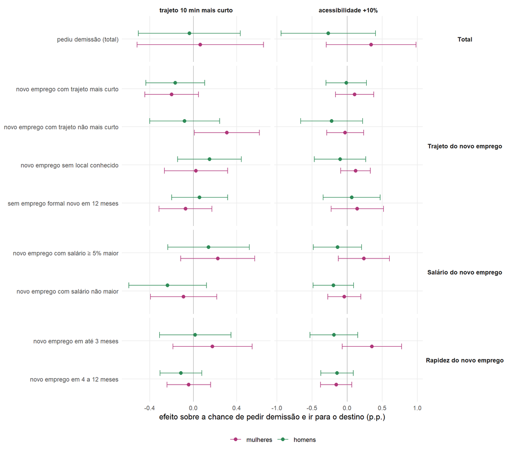

**O que estes resultados mostram**

Modelo B2, trajetos de até 90 minutos, pedidos de demissão em até 12 meses. Cada destino é comparado com a sua própria frequência média.

**Mulheres.** Cada 10 minutos a menos no trajeto aumenta a chance de pedir demissão e ir para um emprego com trajeto que não é mais curto em até 12 meses em 0,31 ponto percentual, o que equivale a cerca de 11% da taxa média, que é de 2,9%; o efeito é estatisticamente significativo (p = 0,010). Já a chance de pedir demissão em até 12 meses (estimativa de +0,07 ponto percentual), a chance de pedir demissão e ir para um emprego com trajeto mais curto em até 12 meses (estimativa de −0,20 ponto percentual), a chance de pedir demissão e ir para um emprego sem local conhecido em até 12 meses (estimativa de +0,03 ponto percentual), a chance de pedir demissão e não ter emprego formal novo depois em até 12 meses (estimativa de −0,07 ponto percentual), a chance de pedir demissão e ir para um emprego com salário pelo menos 5% maior em até 12 meses (estimativa de +0,23 ponto percentual), a chance de pedir demissão e ir para um emprego com salário que não é maior em até 12 meses (estimativa de −0,09 ponto percentual), a chance de pedir demissão e ter emprego novo em até 3 meses em até 12 meses (estimativa de +0,18 ponto percentual) e a chance de pedir demissão e só ter emprego novo entre 4 e 12 meses depois em até 12 meses (estimativa de −0,04 ponto percentual) não mudam de forma estatisticamente distinguível de zero. No placebo, porém, também aparece diferença na chance de pedir demissão e ir para um emprego com salário pelo menos 5% maior em até 12 meses (+0,32 ponto percentual, p = 0,040) e na chance de pedir demissão e ir para um emprego com salário que não é maior em até 12 meses (−0,20 ponto percentual, p = 0,075): nesses casos, a diferença entre os grupos já existia antes da abertura, e o resultado pede cautela.

**Homens.** Cada 10 minutos a menos no trajeto reduz a chance de pedir demissão e ir para um emprego com salário que não é maior em até 12 meses em 0,24 ponto percentual, o que equivale a cerca de 11% da taxa média, que é de 2,1%; o efeito é significativo só ao nível de 10%, uma evidência fraca (p = 0,070). Já a chance de pedir demissão em até 12 meses (estimativa de −0,04 ponto percentual), a chance de pedir demissão e ir para um emprego com trajeto mais curto em até 12 meses (estimativa de −0,17 ponto percentual), a chance de pedir demissão e ir para um emprego com trajeto que não é mais curto em até 12 meses (estimativa de −0,08 ponto percentual), a chance de pedir demissão e ir para um emprego sem local conhecido em até 12 meses (estimativa de +0,15 ponto percentual), a chance de pedir demissão e não ter emprego formal novo depois em até 12 meses (estimativa de +0,06 ponto percentual), a chance de pedir demissão e ir para um emprego com salário pelo menos 5% maior em até 12 meses (estimativa de +0,14 ponto percentual), a chance de pedir demissão e ter emprego novo em até 3 meses em até 12 meses (estimativa de +0,02 ponto percentual) e a chance de pedir demissão e só ter emprego novo entre 4 e 12 meses depois em até 12 meses (estimativa de −0,11 ponto percentual) não mudam de forma estatisticamente distinguível de zero. No placebo — a mesma comparação feita antes de a estação existir —, nenhum desses desfechos mostra diferença significativa, o que reforça que os efeitos acima vêm da abertura.

**Trajetos de mais de 90 minutos**

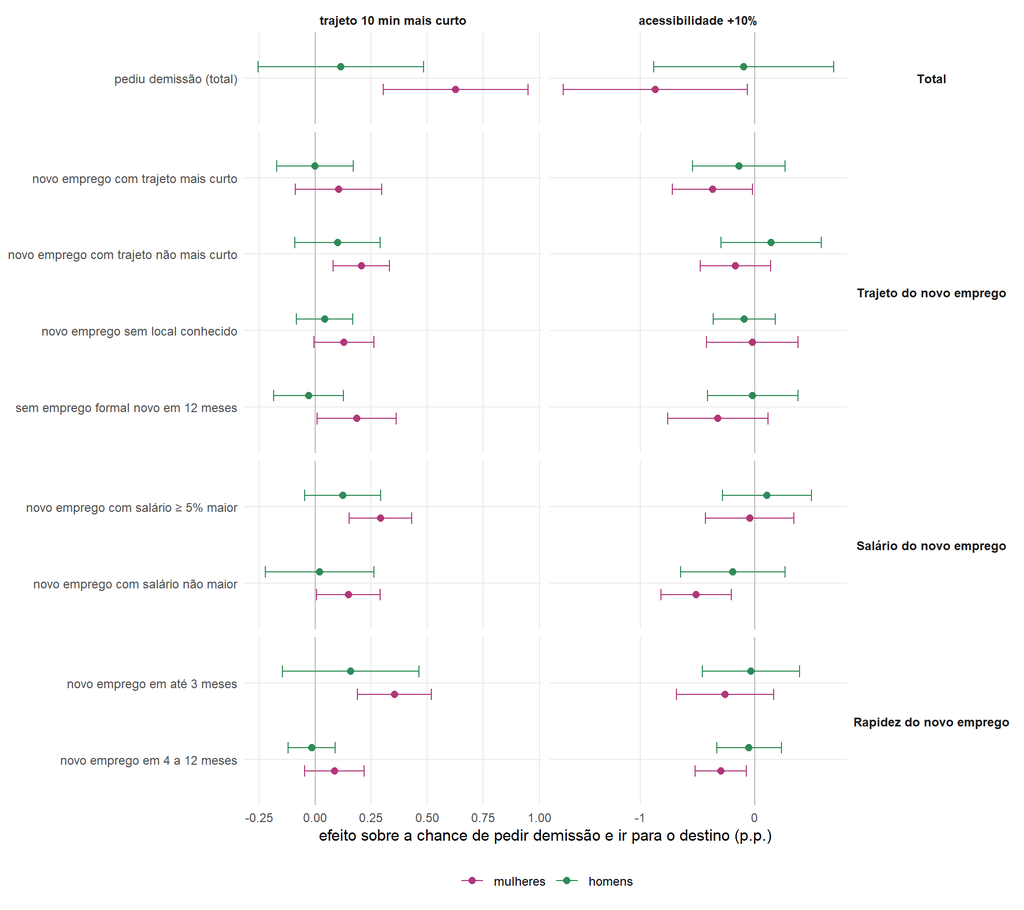

**O que estes resultados mostram**

Modelo B2, trajetos de mais de 90 minutos, pedidos de demissão em até 12 meses. Cada destino é comparado com a sua própria frequência média.

**Mulheres.** Cada 10 minutos a menos no trajeto aumenta a chance de pedir demissão em até 12 meses em 0,63 ponto percentual, o que equivale a cerca de 7% da taxa média, que é de 9,5%; o efeito é estatisticamente muito significativo (p < 0,001). Também aumenta a chance de pedir demissão e ir para um emprego com trajeto que não é mais curto em até 12 meses em 0,21 ponto percentual, o que equivale a cerca de 11% da taxa média, que é de 1,8%; o efeito é estatisticamente significativo (p = 0,030). Além disso, aumenta a chance de pedir demissão e ir para um emprego sem local conhecido em até 12 meses em 0,13 ponto percentual, o que equivale a cerca de 9% da taxa média, que é de 1,4%; o efeito é significativo só ao nível de 10%, uma evidência fraca (p = 0,060). Da mesma forma, aumenta a chance de pedir demissão e não ter emprego formal novo depois em até 12 meses em 0,19 ponto percentual, o que equivale a cerca de 6% da taxa média, que é de 3,1%; o efeito é estatisticamente significativo (p = 0,035). E ainda aumenta a chance de pedir demissão e ir para um emprego com salário pelo menos 5% maior em até 12 meses em 0,29 ponto percentual, o que equivale a cerca de 9% da taxa média, que é de 3,3%; o efeito é estatisticamente muito significativo (p < 0,001). Também aumenta a chance de pedir demissão e ter emprego novo em até 3 meses em até 12 meses em 0,35 ponto percentual, o que equivale a cerca de 8% da taxa média, que é de 4,7%; o efeito é estatisticamente muito significativo (p < 0,001). Já a chance de pedir demissão e ir para um emprego com trajeto mais curto em até 12 meses (estimativa de +0,11 ponto percentual), a chance de pedir demissão e ir para um emprego com salário que não é maior em até 12 meses (estimativa de +0,15 ponto percentual) e a chance de pedir demissão e só ter emprego novo entre 4 e 12 meses depois em até 12 meses (estimativa de +0,09 ponto percentual) não mudam de forma estatisticamente distinguível de zero. No placebo, porém, também aparece diferença na chance de pedir demissão e ir para um emprego com trajeto mais curto em até 12 meses (−0,14 ponto percentual, p = 0,085): nesses casos, a diferença entre os grupos já existia antes da abertura, e o resultado pede cautela.

**Homens.** Cada 10 minutos a menos no trajeto não altera de forma estatisticamente distinguível de zero a chance de pedir demissão em até 12 meses (estimativa de +0,11 ponto percentual), a chance de pedir demissão e ir para um emprego com trajeto mais curto em até 12 meses (estimativa de +0,00 ponto percentual), a chance de pedir demissão e ir para um emprego com trajeto que não é mais curto em até 12 meses (estimativa de +0,10 ponto percentual), a chance de pedir demissão e ir para um emprego sem local conhecido em até 12 meses (estimativa de +0,04 ponto percentual), a chance de pedir demissão e não ter emprego formal novo depois em até 12 meses (estimativa de −0,03 ponto percentual), a chance de pedir demissão e ir para um emprego com salário pelo menos 5% maior em até 12 meses (estimativa de +0,12 ponto percentual), a chance de pedir demissão e ir para um emprego com salário que não é maior em até 12 meses (estimativa de +0,02 ponto percentual), a chance de pedir demissão e ter emprego novo em até 3 meses em até 12 meses (estimativa de +0,16 ponto percentual) e a chance de pedir demissão e só ter emprego novo entre 4 e 12 meses depois em até 12 meses (estimativa de −0,01 ponto percentual). No placebo, porém, também aparece diferença na chance de pedir demissão e ir para um emprego com trajeto mais curto em até 12 meses (+0,24 ponto percentual, p = 0,010) e na chance de pedir demissão e ir para um emprego com salário pelo menos 5% maior em até 12 meses (+0,20 ponto percentual, p = 0,005): nesses casos, a diferença entre os grupos já existia antes da abertura, e o resultado pede cautela.

**Todos os trajetos juntos**

## Quem pediu demissão tinha tido um ganho maior?

**O que é esta comparação.** É uma comparação descritiva, não um efeito causal.

**Como é feita.**

- Para cada grupo (quem não pediu demissão e quem pediu e foi para cada destino), calculamos o **ganho inesperado** médio.
- O ganho inesperado é o ganho realizado menos o ganho esperado pelos sorteios das datas: a mesma quantidade que o B&H usa para identificar o efeito.
- Fazemos isso para o trajeto (em minutos) e para a acessibilidade a partir de casa (em %).

**Como ler.**

- Suponha que quem pediu demissão para ir a um emprego mais perto tivesse tido, em média, um ganho inesperado maior do que quem não pediu. Isso seria coerente com a explicação da troca de emprego.
- Valores perto de zero indicam que os grupos tiveram, em média, o ganho que seria esperado só pela localização.

**Trajetos de até 90 minutos**

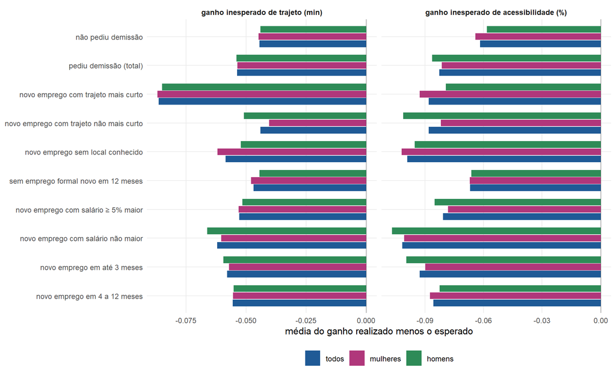

**O que esta comparação mostra**

**Todas as pessoas.** Quem não pediu demissão teve, em média, ganho inesperado de −0,04 min no trajeto e de −0,06% na acessibilidade. Entre quem pediu, conforme o destino, o ganho inesperado de trajeto vai de −0,09 a −0,04 min e o de acessibilidade de −0,10% a −0,07%. As diferenças são de frações de minuto e de menos de um ponto percentual: quem pediu demissão não tinha recebido um ganho maior do que quem ficou no emprego.

**Mulheres.** Quem não pediu demissão teve, em média, ganho inesperado de −0,04 min no trajeto e de −0,06% na acessibilidade. Entre quem pediu, conforme o destino, o ganho inesperado de trajeto vai de −0,09 a −0,04 min e o de acessibilidade de −0,10% a −0,07%. As diferenças são de frações de minuto e de menos de um ponto percentual: quem pediu demissão não tinha recebido um ganho maior do que quem ficou no emprego.

**Homens.** Quem não pediu demissão teve, em média, ganho inesperado de −0,04 min no trajeto e de −0,06% na acessibilidade. Entre quem pediu, conforme o destino, o ganho inesperado de trajeto vai de −0,08 a −0,04 min e o de acessibilidade de −0,11% a −0,07%. As diferenças são de frações de minuto e de menos de um ponto percentual: quem pediu demissão não tinha recebido um ganho maior do que quem ficou no emprego.

**Trajetos de mais de 90 minutos**

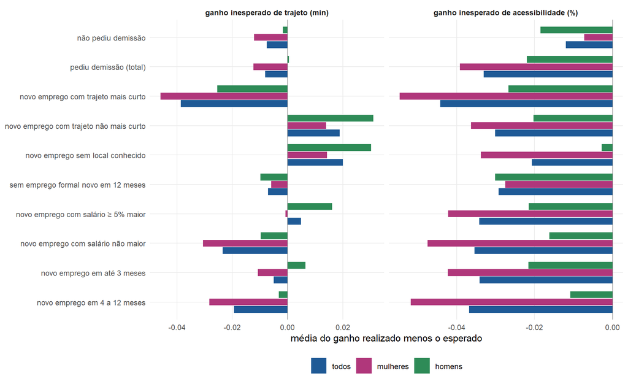

**O que esta comparação mostra**

**Todas as pessoas.** Quem não pediu demissão teve, em média, ganho inesperado de −0,01 min no trajeto e de −0,01% na acessibilidade. Entre quem pediu, conforme o destino, o ganho inesperado de trajeto vai de −0,04 a +0,02 min e o de acessibilidade de −0,04% a −0,02%. As diferenças são de frações de minuto e de menos de um ponto percentual: quem pediu demissão não tinha recebido um ganho maior do que quem ficou no emprego.

**Mulheres.** Quem não pediu demissão teve, em média, ganho inesperado de −0,01 min no trajeto e de −0,01% na acessibilidade. Entre quem pediu, conforme o destino, o ganho inesperado de trajeto vai de −0,05 a +0,01 min e o de acessibilidade de −0,05% a −0,03%. As diferenças são de frações de minuto e de menos de um ponto percentual: quem pediu demissão não tinha recebido um ganho maior do que quem ficou no emprego.

**Homens.** Quem não pediu demissão teve, em média, ganho inesperado de −0,00 min no trajeto e de −0,02% na acessibilidade. Entre quem pediu, conforme o destino, o ganho inesperado de trajeto vai de −0,03 a +0,03 min e o de acessibilidade de −0,03% a −0,00%. As diferenças são de frações de minuto e de menos de um ponto percentual: quem pediu demissão não tinha recebido um ganho maior do que quem ficou no emprego.

**Todos os trajetos juntos**

## Conclusão do desenho C

**O que acontece com quem pede demissão.** Para mulheres, 8,5% dos vínculos terminam em pedido de demissão em 12 meses. Desses pedidos, 35% não são seguidos de nenhum emprego formal novo em 12 meses; os demais vão para um novo emprego formal.

**Efeito da estação sobre os destinos.** Cada 10 minutos a menos no trajeto (modelo B2) não altera de forma estatisticamente distinguível de zero a chance de pedir demissão em até 12 meses (a estimativa é de +0,07 ponto percentual, com p = 0,789). Entre os destinos, aumenta a chance de pedir demissão e ir para um emprego com trajeto que não é mais curto em até 12 meses em 0,31 ponto percentual; o efeito é estatisticamente significativo (p = 0,010); os demais não mudam de forma significativa.

**Quem pediu demissão tinha ganhado mais?** Em média, quem pediu demissão teve um ganho inesperado de trajeto de −0,05 min e de acessibilidade de −0,08%, contra −0,04 min e −0,06% de quem não pediu: os dois grupos tiveram, na prática, o mesmo ganho.

**Conclusão.** Não há sinal de que o trajeto mais curto tenha levado as pessoas a pedir demissão para trocar de emprego por outro mais perto de casa ou mais bem pago. O total de pedidos não muda. A única mudança significativa entre os destinos (pedir demissão e ir para um emprego com trajeto que não é mais curto em até 12 meses) não aponta para empregos mais próximos nem mais bem pagos. Isso reforça a leitura do desenho B: o efeito das estações sobre a permanência no emprego passa pela redução das demissões, e não por mais mobilidade voluntária entre empregos.

# D. IPTW

**Em uma frase.** Comparamos quem teve um ganho numa faixa (por exemplo, 10 minutos ou mais no trajeto) com quem quase não ganhou nada no mesmo evento, dando mais peso aos que não ganharam mas se parecem com os que ganharam, para que os dois grupos fiquem iguais nas características de antes da abertura.

**Como esta seção está organizada.**

1. **Estratégia:** o problema, a ideia dos pesos (para quem nunca viu IPTW), o passo a passo, o que o efeito significa e como conferir se os pesos funcionaram (o “balanço”).
2. **Tempo de viagem (vínculos):**
   - o balanço;
   - o quadro de leitura;
   - os resultados, com uma aba por faixa de ganho e, dentro dela, uma aba por desfecho, com o efeito em cada grupo e as diferenças entre grupos logo abaixo.
3. **Área (pessoas):** o mesmo, para cada indicador de acessibilidade.

## Estratégia de identificação

#### O problema

Uma forma direta de medir o efeito é comparar quem teve um ganho grande com quem praticamente não teve ganho, no mesmo evento. O problema é que esses dois grupos podem ser diferentes desde antes:

- quem ganha mora mais perto das linhas novas;
- tende a ter outra idade, outro histórico de emprego e outro bairro.

Se a diferença no emprego vier dessas características, e não da estação, a comparação simples erra.

#### A ideia dos pesos (IPTW), para quem nunca viu

IPTW quer dizer *ponderação pelo inverso da probabilidade de tratamento*.

**Um exemplo.**

- Imagine 100 tratados (ganharam 10 minutos ou mais) e 1.000 controles (não ganharam nada).
- Os tratados são mais jovens e moram mais perto do centro que a média dos controles.
- Uma média simples dos controles representaria mal “o que teria acontecido com os tratados sem a estação”.

**O que o IPTW faz.**

1. **Estima o escore de propensão.** Para cada pessoa, estima a chance de ela ser tratada a partir das características que ela tinha **antes** da abertura.
2. **Dá peso aos controles.**
   - Um controle com chance alta (ele “parece” um tratado: jovem, perto do centro) recebe **peso grande**.
   - Um controle com chance baixa (não se parece com nenhum tratado) recebe **peso pequeno**.
3. **Compara.** Depois dos pesos, o grupo de controles fica com a mesma composição dos tratados (mesma idade média, mesma parcela de mulheres, mesmo histórico de emprego…). Só então comparamos os desfechos.

#### Como a comparação é feita, passo a passo

1. **Tratados e controles.** Em cada evento, os tratados são as pessoas (ou vínculos) com ganho numa faixa:
   - na área: ganho de 1 a 5%, de 5 a 20% ou de 20% ou mais sobre a acessibilidade de antes, em cada indicador;
   - no tempo de viagem: ganho de 1 a 5, de 5 a 10 ou de 10 minutos ou mais.
   - Os controles têm ganho abaixo de 1% (ou de 1 minuto).
2. **Janela limpa.** Tratados e controles não podem ter ganho de nenhuma outra abertura entre a referência do placebo e 24 meses depois da referência, para não misturar efeitos de aberturas diferentes.
3. **Escore de propensão.** Um logit, estimado por evento e faixa, dá a probabilidade de ser tratado. As características usadas são todas anteriores à abertura:
   - pessoa: idade, sexo, criança na família, raça, deficiência, alfabetização, anos desde a atualização do cadastro;
   - emprego antes da abertura;
   - lugar: acessibilidade de antes, distância ao centro e características do Censo 2010 da área (renda, aglomerado subnormal, densidade, esgoto, pavimentação);
   - no tempo de viagem, também o salário, o tempo de vínculo, o tempo do trajeto e a distância do trabalho ao centro.
4. **Pesos.** Os controles recebem peso p/(1 − p), em que p é a probabilidade estimada: os que se parecem com tratados pesam mais. O efeito estimado é o **efeito médio nos tratados** (ATT).
   - **Corte dos pesos extremos.** Em cada evento, nenhum controle pode pesar mais que o percentil 99 dos pesos dos controles daquele evento. Sem esse corte, em alguns eventos uns poucos controles, quase idênticos aos tratados, recebiam pesos enormes e carregavam a comparação sozinhos (ver o diagnóstico na parte de tempo de viagem, abaixo).
5. **Duplamente robusto.** Além dos pesos, a regressão do desfecho inclui as mesmas características e o evento. O resultado fica certo se o escore **ou** a regressão estiverem bem especificados.
6. **Inferência.** Erro-padrão agrupado por célula de cerca de 5 km² (vizinhos sofrem choques parecidos), tratando os pesos como dados.
7. **Placebo.** A mesma comparação com a referência 25 meses antes da primeira abertura.

#### O que o efeito significa (e por que ele é maior que no B&H)

O efeito do IPTW é a diferença no desfecho entre os tratados de uma faixa e os controles reponderados, em p.p.

- **No IPTW,** é o efeito de **estar na faixa** (por exemplo, ganhar 10 minutos ou mais) contra não ganhar nada.
- **No B&H (desenhos A e B),** é o efeito **por unidade** de ganho (por exemplo, por 10 minutos).

Por isso os números do IPTW tendem a ser maiores e não são diretamente comparáveis aos do B&H.

#### Como saber se os pesos funcionaram: o “balanço” e a diferença padronizada

O IPTW só funciona se, depois dos pesos, tratados e controles ficarem parecidos. Para conferir, usamos a **diferença padronizada** de cada característica.

**O que ela é.**

- É a diferença entre a média dos tratados e a média dos controles, dividida pelo desvio-padrão da característica.
- A divisão põe todas as características na mesma escala. Assim, “2 anos de idade a mais” e “5 pontos percentuais a mais de mulheres” podem ser comparados.

**Como ler.**

- 0 quer dizer grupos idênticos naquela característica.
- Abaixo de **0,1**, a diferença é considerada pequena; essa é a regra usual.
- Acima de 0,25, a diferença é grande.

**O que a tabela de balanço mostra.**

- A **maior** dessas diferenças entre todas as características, antes e depois dos pesos.
- Se a maior diferença depois dos pesos está abaixo de 0,1, os grupos ficaram parecidos em **todas** as características medidas.
- A tabela também mostra os **controles efetivos**: com pesos muito desiguais, poucos controles carregam a comparação, e ela fica menos precisa.

#### O que precisa ser verdade (hipóteses)

1. **Seleção nas observáveis.** Depois de igualar as características medidas, quem ganhou e quem não ganhou não diferem em nada que afete o emprego.
   - É uma hipótese **mais forte** que a do B&H, porque não usa a sorte do calendário.
   - Diferenças não medidas (por exemplo, o tipo de empresa) podem enviesar o resultado.
2. **Sobreposição.** Para cada tratado há controles parecidos, de modo que os pesos não explodem.
3. **Janela limpa e sem antecipação.** O placebo testa a antecipação.

## Tempo de viagem

#### Diagnóstico do balanço e a correção adotada

**O que aconteceu.** Na primeira estimação, sem corte nos pesos, o balanço foi ruim. A investigação mostrou que o problema vinha de três eventos (13, 14 e 19):

- nesses eventos, o escore de propensão quase separava tratados e controles;
- poucos controles, com escore perto de 1, ficavam com pesos enormes (no evento 13, os 10 maiores pesos somavam 64% do peso de todos os controles);
- com isso, a comparação passava a depender de umas poucas pessoas, e a renda do bairro (Censo 2010) ficava muito diferente entre os grupos depois dos pesos.

**O que testamos.** Quatro correções, no ganho de 10 minutos ou mais e no de 5 a 10 minutos (trajetos de até 90 minutos), depois da abertura e no placebo:

1. cortar os pesos dos controles no percentil 99 de cada evento;
2. tirar quem tem escore acima de 0,9 (tratados e controles);
3. usar como controles só quem mora no mesmo bairro (célula H3-7) de algum tratado do evento, reestimando o escore;
4. usar só quem mora e trabalha nos mesmos bairros de algum tratado.

**O que adotamos.** O corte no percentil 99 (versão 1): é a correção que deixa os grupos parecidos e mantém o maior número de controles efetivos. As demais versões ficam como robustez.

**O que o diagnóstico mostra**

**Balanço.** No ganho de 10 minutos ou mais, a maior diferença padronizada depois dos pesos cai de 2,12, na versão original, para 0,13 com o corte no percentil 99, e os controles efetivos sobem de 114 para 182.786. As outras correções também deixam os grupos parecidos (maior diferença entre 0,09 e 0,12), mas com menos controles efetivos (de 613 a 24.003).

**Efeito.** Com o corte, ganhar 10 minutos ou mais muda a chance de ser demitido em até 6 meses em −1,52 (p = 0,018) para todas as pessoas, em −2,82 (p < 0,001) para as mulheres e em +0,52 (p = 0,381) para os homens, em pontos percentuais (na versão original: −1,93 (p = 0,056), −3,10 (p = 0,009) e −0,13 (p = 0,905)). No placebo, os mesmos efeitos são −0,26 (p = 0,642), −0,27 (p = 0,642) e −0,06 (p = 0,962), todos estatisticamente indistinguíveis de zero: a queda nas demissões das mulheres sobrevive à correção e não aparece antes da abertura.

**Controles do mesmo bairro.** Quando os controles vêm só do mesmo bairro de casa, a estimativa cai para −0,93 (p = 0,246) em todas as pessoas e para −1,61 (p = 0,145) nas mulheres; a demissão sem justa causa das mulheres fica em −1,87 (p = 0,074). O placebo dessa versão é menos limpo (demissão em até 12 meses de todas as pessoas: +1,38 (p = 0,048)). Com o mesmo bairro de casa e de trabalho, sobram poucos controles efetivos e as estimativas ficam imprecisas.

**Faixa de 5 a 10 minutos.** Com o corte, o efeito para as mulheres é −0,97 (p = 0,002), mas o placebo é −0,76 (p = 0,066): nessa faixa, o resultado pede cautela.

Balanço de cada versão (trajetos de até 90 minutos, todas as pessoas)

| Faixa | Janela | Versão | Tratados | Controles | Controles efetivos | Maior diferença padronizada, antes dos pesos | Maior diferença padronizada, depois dos pesos | Características mais desiguais depois dos pesos |
| --- | --- | --- | --- | --- | --- | --- | --- | --- |
| ganho de 10 min ou mais | depois | Original, sem corte | 3.786 | 2.664.617 | 114 | 1,19 | 2,12 | renda_pc (-2.12); lacc (1.45); dist_se_trab (-0.67) |
| ganho de 10 min ou mais | depois | Corte no percentil 99 (adotada) | 3.786 | 2.664.617 | 182.786 | 1,19 | 0,13 | subnormal (0.13); lacc (-0.12); renda_pc (0.1) |
| ganho de 10 min ou mais | depois | Sem escore acima de 0,9 | 3.786 | 2.664.603 | 24.003 | 1,19 | 0,10 | renda_pc (-0.1); lacc (0.05); dist_se_trab (-0.05) |
| ganho de 10 min ou mais | depois | Controles do mesmo bairro de casa | 3.786 | 403.225 | 4.253 | 1,42 | 0,09 | esgoto (-0.09); subnormal (0.08); renda_pc (-0.07) |
| ganho de 10 min ou mais | depois | Controles do mesmo bairro de casa e de trabalho | 3.786 | 9.400 | 613 | 0,73 | 0,12 | esgoto (-0.12); dist_se_trab (-0.11); subnormal (0.09) |
| ganho de 10 min ou mais | placebo | Original, sem corte | 3.819 | 2.583.052 | 257 | 1,22 | 1,15 | lacc (1.15); renda_pc (-0.95); dist_se_trab (-0.55) |
| ganho de 10 min ou mais | placebo | Corte no percentil 99 (adotada) | 3.819 | 2.583.052 | 183.951 | 1,22 | 0,12 | renda_pc (0.12); subnormal (0.12); lacc (-0.11) |
| ganho de 10 min ou mais | placebo | Sem escore acima de 0,9 | 3.819 | 2.583.040 | 18.714 | 1,22 | 0,14 | lacc (0.14); dist_se_trab (-0.09); renda_pc (-0.05) |
| ganho de 10 min ou mais | placebo | Controles do mesmo bairro de casa | 3.819 | 416.323 | 4.512 | 1,45 | 0,09 | subnormal (0.09); densidade (0.07); renda_pc (-0.07) |
| ganho de 10 min ou mais | placebo | Controles do mesmo bairro de casa e de trabalho | 3.819 | 10.188 | 465 | 0,63 | 0,22 | renda_pc (-0.22); densidade (0.14); esgoto (-0.12) |
| ganho de 5 a 10 min | depois | Original, sem corte | 8.430 | 2.990.653 | 61 | 1,07 | 2,22 | lacc (2.22); dist_se_trab (-0.7); renda_pc (-0.4) |
| ganho de 5 a 10 min | depois | Corte no percentil 99 (adotada) | 8.430 | 2.990.653 | 312.183 | 1,07 | 0,12 | renda_pc (0.12); dist_se_trab (0.06); lacc (-0.06) |
| ganho de 5 a 10 min | depois | Sem escore acima de 0,9 | 8.430 | 2.990.640 | 68.553 | 1,07 | 0,11 | renda_pc (-0.11); lacc (0.06); dist_se_trab (-0.04) |
| ganho de 5 a 10 min | depois | Controles do mesmo bairro de casa | 8.430 | 672.842 | 22.359 | 1,18 | 0,06 | pavim (0.06); densidade (0.06); renda_pc (-0.04) |
| ganho de 5 a 10 min | depois | Controles do mesmo bairro de casa e de trabalho | 8.430 | 25.929 | 1.486 | 0,61 | 0,10 | renda_pc (-0.1); densidade (0.09); dist_se_trab (-0.08) |
| ganho de 5 a 10 min | placebo | Original, sem corte | 8.340 | 2.906.212 | 21.224 | 1,08 | 0,33 | renda_pc (-0.33); lacc (0.11); dist_se_trab (-0.08) |
| ganho de 5 a 10 min | placebo | Corte no percentil 99 (adotada) | 8.340 | 2.906.212 | 307.993 | 1,08 | 0,12 | renda_pc (0.12); dist_se_trab (0.06); lacc (-0.05) |
| ganho de 5 a 10 min | placebo | Sem escore acima de 0,9 | 8.340 | 2.906.205 | 50.309 | 1,08 | 0,17 | renda_pc (-0.17); lacc (0.09); dist_se_trab (-0.06) |
| ganho de 5 a 10 min | placebo | Controles do mesmo bairro de casa | 8.340 | 672.429 | 14.863 | 1,17 | 0,08 | pavim (0.08); densidade (0.07); renda_pc (-0.05) |
| ganho de 5 a 10 min | placebo | Controles do mesmo bairro de casa e de trabalho | 8.340 | 26.318 | 3.646 | 0,57 | 0,13 | renda_pc (-0.13); densidade (0.07); pavim (0.05) |

**ganho de 10 min ou mais**

| Versão | todos · demissão, 6 m · depois | todos · demissão, 6 m · placebo | todos · sem justa causa, 6 m · depois | todos · sem justa causa, 6 m · placebo | todos · demissão, 12 m · depois | todos · demissão, 12 m · placebo | mulheres · demissão, 6 m · depois | mulheres · demissão, 6 m · placebo | mulheres · sem justa causa, 6 m · depois | mulheres · sem justa causa, 6 m · placebo | mulheres · demissão, 12 m · depois | mulheres · demissão, 12 m · placebo | homens · demissão, 6 m · depois | homens · demissão, 6 m · placebo | homens · sem justa causa, 6 m · depois | homens · sem justa causa, 6 m · placebo | homens · demissão, 12 m · depois | homens · demissão, 12 m · placebo |
| --- | --- | --- | --- | --- | --- | --- | --- | --- | --- | --- | --- | --- | --- | --- | --- | --- | --- | --- |
| Original, sem corte | −1,93* (1,01) | +0,10 (0,65) | −1,99** (0,95) | +0,00 (0,68) | −1,62 (1,03) | +0,76 (0,70) | −3,10*** (1,19) | −0,10 (0,75) | −3,24*** (1,10) | −0,27 (0,69) | −2,03* (1,13) | +0,04 (0,91) | −0,13 (1,09) | +0,52 (1,40) | −0,04 (1,05) | +0,61 (1,33) | −0,85 (1,18) | +1,88 (1,18) |
| Corte no percentil 99 (adotada) | −1,52** (0,64) | −0,26 (0,56) | −1,55*** (0,58) | −0,31 (0,62) | −1,43** (0,67) | +0,07 (0,61) | −2,82*** (0,85) | −0,27 (0,58) | −2,95*** (0,77) | −0,34 (0,58) | −1,59* (0,83) | −0,19 (0,79) | +0,52 (0,59) | −0,06 (1,18) | +0,64 (0,55) | −0,06 (1,13) | −0,97 (0,78) | +0,67 (1,02) |
| Sem escore acima de 0,9 | −1,45** (0,64) | −0,08 (0,61) | −1,48** (0,58) | −0,16 (0,64) | −1,35** (0,68) | +0,38 (0,71) | −2,68*** (0,87) | +0,06 (0,65) | −2,78*** (0,80) | −0,09 (0,62) | −1,70** (0,82) | −0,01 (0,86) | +0,41 (0,66) | −0,18 (1,20) | +0,50 (0,61) | −0,18 (1,13) | −0,69 (0,85) | +1,11 (1,08) |
| Controles do mesmo bairro de casa | −0,93 (0,81) | +0,84 (0,74) | −1,00 (0,77) | +0,79 (0,80) | −0,77 (0,84) | +1,38** (0,70) | −1,61 (1,10) | +0,93 (0,66) | −1,87* (1,05) | +0,76 (0,71) | −0,62 (1,05) | +1,17 (0,86) | +0,23 (0,86) | +0,62 (1,33) | +0,46 (0,86) | +0,77 (1,32) | −0,74 (0,95) | +1,50 (1,25) |
| Controles do mesmo bairro de casa e de trabalho | −1,12 (0,97) | −1,40 (1,63) | −1,50* (0,84) | −1,31 (1,71) | −0,13 (1,14) | −0,18 (2,07) | −2,19 (1,33) | −2,03 (1,65) | −2,77** (1,28) | −2,29 (1,64) | −1,58 (1,74) | −1,37 (2,10) | −0,10 (1,63) | +0,09 (1,64) | −0,27 (1,60) | +0,79 (1,86) | +1,51 (1,85) | +1,72 (2,04) |

Efeito médio nos tratados (trajetos de até 90 minutos), em pontos percentuais; entre parênteses, o erro-padrão.

**ganho de 5 a 10 min**

| Versão | todos · demissão, 6 m · depois | todos · demissão, 6 m · placebo | todos · sem justa causa, 6 m · depois | todos · sem justa causa, 6 m · placebo | todos · demissão, 12 m · depois | todos · demissão, 12 m · placebo | mulheres · demissão, 6 m · depois | mulheres · demissão, 6 m · placebo | mulheres · sem justa causa, 6 m · depois | mulheres · sem justa causa, 6 m · placebo | mulheres · demissão, 12 m · depois | mulheres · demissão, 12 m · placebo | homens · demissão, 6 m · depois | homens · demissão, 6 m · placebo | homens · sem justa causa, 6 m · depois | homens · sem justa causa, 6 m · placebo | homens · demissão, 12 m · depois | homens · demissão, 12 m · placebo |
| --- | --- | --- | --- | --- | --- | --- | --- | --- | --- | --- | --- | --- | --- | --- | --- | --- | --- | --- |
| Original, sem corte | −0,63* (0,35) | −0,56 (0,37) | −0,66** (0,33) | −0,54 (0,38) | −1,15*** (0,43) | −0,51 (0,54) | −0,85*** (0,31) | −0,89** (0,41) | −1,02*** (0,38) | −0,80** (0,37) | −1,40*** (0,43) | −1,04* (0,54) | −0,52 (0,64) | −0,15 (0,60) | −0,25 (0,62) | −0,25 (0,62) | −1,16 (0,85) | +0,13 (0,82) |
| Corte no percentil 99 (adotada) | −0,77** (0,33) | −0,46 (0,36) | −0,82** (0,32) | −0,43 (0,37) | −1,37*** (0,46) | −0,43 (0,50) | −0,97*** (0,31) | −0,76* (0,41) | −1,13*** (0,37) | −0,63* (0,36) | −1,59*** (0,44) | −0,78 (0,53) | −0,44 (0,66) | −0,06 (0,59) | −0,29 (0,62) | −0,19 (0,61) | −1,00 (1,02) | +0,05 (0,72) |
| Sem escore acima de 0,9 | −0,74** (0,36) | −0,57 (0,37) | −0,78** (0,37) | −0,55 (0,39) | −1,34*** (0,47) | −0,57 (0,54) | −0,94*** (0,33) | −0,78* (0,43) | −1,11*** (0,42) | −0,69* (0,38) | −1,54*** (0,46) | −0,98* (0,54) | −0,43 (0,68) | −0,29 (0,59) | −0,25 (0,66) | −0,40 (0,62) | −1,04 (0,99) | −0,05 (0,79) |
| Controles do mesmo bairro de casa | −0,42 (0,30) | −0,11 (0,40) | −0,42 (0,34) | −0,04 (0,43) | −0,74* (0,44) | +0,08 (0,53) | −0,40 (0,35) | −0,41 (0,45) | −0,53 (0,41) | −0,21 (0,43) | −0,69 (0,52) | −0,41 (0,61) | −0,46 (0,78) | +0,28 (0,63) | −0,25 (0,75) | +0,12 (0,69) | −0,89 (1,05) | +0,69 (0,77) |
| Controles do mesmo bairro de casa e de trabalho | +0,04 (0,62) | −0,71 (0,58) | +0,02 (0,74) | −0,73 (0,64) | −1,52* (0,78) | −0,31 (0,85) | −1,21* (0,72) | −0,99 (0,66) | −1,09 (0,98) | −1,01 (0,75) | −1,15 (0,78) | −0,75 (0,88) | +1,74* (1,03) | −0,40 (1,03) | +1,61* (0,96) | −0,48 (1,06) | −1,28 (1,19) | +0,19 (1,54) |

Efeito médio nos tratados (trajetos de até 90 minutos), em pontos percentuais; entre parênteses, o erro-padrão.